# Tests over GBM Hyper-parameters

## Tests over GBM hyper-parameters

This notebook presents all results and discussions that follow tests conducted in order to study the specification of GBM hyper-parameters.  
In a first place, theoretical aspects of GBM method and data modeling are discussed in sections "Gradient Boosting Model (GBM) and its main hyper-parameters" and "Theoretical framework". Then, the objectives and structure of tests are presented, after which follow the main conclusions from the tests. The remaining of the notebook has full results.  
From these tests over GBM hyper-parameters, two additional studies have emerged: the first compares values for the performance metrics of precision-recall AUC and average precision score (folder older "Peformance metrics for classification tasks"), while the second opposes grid searches using ROC-AUC and average precision score (folder "Grid Search Metrics"). Full results of both such studies are presented and discussed in their own notebooks, even though an appendix here shows preliminary results for the second study, making use of the same outcomes from tests over GBM hyper-parameters.

#### Gradient Boosting Model (GBM) and its main hyper-parameters

In their standard setting, **Gradient Boosting Models (GBMs)** are tree-based learning algorithms that produce an ensemble of different estimators in order to provide more robust predictions. Analogous to bagging and random forests, predictions from GBM are constructed upon a collection of individual estimators, but differently from them, learners that compose the GBM ensemble are not independent from each other, since they are defined in a sequential and evolutional manner.  
Consequently, it follows that GBM estimation requires: i) creating $M$ different (but not independent) estimators; ii) combining them to conceive a final model. A first question that emerges from such procedure is *what data to use at each estimation* $m$? All $N$ training data points available, or just some fraction $\eta$ of randomly picked observations? This hyper-parameter $\eta$ is named **subsample** and it is defined in the interval $(0, 1]$.  
Once defined $\eta = 1$ or $\eta < 1$, and in the second case which specific value $\eta \in (0,1)$ to use, given that each base learner that constitute the GBM ensemble is a decision-tree, a second choice to do concerns the size of each tree, which can be understood in different ways: i) number of terminal nodes; ii) number of splits. The first definition is how Friedman, Hastie, and Tibshirani (2008) deal with tree sizes, and it actually is more intuitive to grasp a tree size. Number of splits, in its turn, can be translated into the depth of a tree. Either ways of defining a tree size are highly related, but the number of splits more directly reveals the possible degree of interaction between input variables. Thus, another relevant hyper-parameter for GBM is the **maximum depth** of trees, $max\_depth \in \mathbb{N}_+$, varying from $max\_depth = 1$, where trees are actually stumps and there is no interaction among inputs of a given tree, and $max\_depth > 1$, where interaction effects may be captured by single trees.  
Since GBM is a kind of ensemble model, the contribution of each base learner to the final composite model can also be calibrated. The hyper-parameter that controls this is the **learning rate**, or shrinkage parameter, $v \in (0, 1]$. Defining $v < 1$ leads to a regularized model, and $v \rightarrow 0$ implies in a slow learning that attenuates the contribution of each tree in the ensemble, thus preventing overfitting caused by specificities of data expressed in a few, but eventually influent base learners.  
Finally, being defined how data is used in each estimation, which kind of trees can be estimated, and the weight each of them receives when composing the final model, it is necessarily to declare how many of such individual estimators should be constructed. This last hyper-parameter is the **number of estimators**, $n\_estimators \in \mathbb{N}_+$, where its value is typically large, $n\_estimators \geq 100$.  
**Note:** besides these hyper-parameters specific for ensemble models, there are several others concerning trees construction.

Therefore, the main hyper-parameters to be explored when estimating GBM are:

- Subsample, $\eta$: whether $\eta = 1$ or $\eta < 1$, and which value when $\eta \in (0, 1)$.
- Maximum depth, $max\_depth$: choosing among $\{1, 2, ..., 10\}$.
- Learning rate, $v$: exploring different values smaller than 1.
- Number of estimators, $n\_estimators$.

#### Theoretical framework

Prior to presenting objectives and structure of tests, it is necessary to define some crucial objects concerning model estimation. First of all, a **statistical model** consists on a function $F(X)$ that defines how a response variable $Y$ is defined from inputs $X$ through **parameters** $\gamma$, which ultimately defines a model. To this deterministic relationship, an irreducible random error $\epsilon$ is conceived. How these parameters $\gamma$ relate with inputs $X$ depends on the **statistical learning method** used to estimate such parameters from empirical data. Estimation methods of any complexity levels are reference by **hyper-parameters** $\theta$, which are not estimated from data, but rather defined previously to estimation. So, before estimating a model, one should collect data, choose which method to use and define which values its hyper-parameters will assume.  
Given a statistical learning method $L$ based on hyper-parameters $\theta^L \in \Theta^L$, where $\Theta^L \subset \mathbb{R}^k$, and parameters $\gamma^L \in \mathbb{R}^p$, the **model space** $\mathcal{M}^L$ is understood to be a p-dimensional Euclidean space accomplishing all possible values for parameters $\gamma^L$. When some algorithm is about to execute the estimation of a model under the specific statistical learning framework $L$, the model probability distribution $P(\gamma^L|\theta^L)$ is a direct function of hyper-parameters $\theta^L$ that must be defined previously to the estimation of $\gamma^L$.  
This means that how likely it is to some model $\hat{\gamma}^L \in \mathcal{M}^L$ to be estimated depends on the hyper-parameters choice $\theta^L$ - and, of course, on the data being modeled. Note that, depending on the statistical learning method under consideration, such model probability distribution may be constant, i.e., no randomness would exist in model estimation. Even so, its hyper-parameters will define which given model $\hat{\gamma}$ will be estimated (given the data), but in a deterministic way.  
Note also that the objective, in supervised learning tasks, is to approximate the target function $F(X)$ that defines precisely how the response variable $Y$ relates with inputs $X$. Therefore, the main concern is to define the best learning method and, then, the best hyper-parameter vector $\theta^{L*} \in \Theta^L$ that would lead to an expected estimated model $E(\hat{\gamma}^L|\theta^{L*})$ that gets the closest to $F(X)$.  
Consequently, finding such $\theta^{L*}$ requires trying out all possible combinations of $\theta_1$, $\theta_2$, ..., $\theta_k$ available in $\Theta^L$. In this sense, to say that some value of $\theta_j$ is the "best", or "appropriate" is stricly correct only if all others $\theta_{-j}$ are also defined in their best values. Such *general perspective*, however, it is not only unfeasible, but, which is more important here, is also uninformative.  
Therefore, tests as those whose results are presented and discussed here assume a *partial perspective*, since they assume all other things being equal. If their results do not necessarily reveal hyper-parameters values that guarantee the best possible expected performance, they are still able to reference good strategies for hyper-parameters specification, besides of providing evidence of how predictive accuracy should relate with main hyper-parameters of a given statistical learning method.

#### Objetives and structure of tests

Turning the attention back to tests over GBM hyper-parameters, the objectives of the study whose results are presented here are as follows:

1. Oppose theoretical considerations to empirical evidence.
   - For instance, Friedman, Hastie, and Tibshirani (2008) indicate that hardly large trees would lead to better results than shorter ones (page 363 of 2nd edition). They also point to the relevance of defining a very small learning rate (page 365) and to the possibility of stochastic GBM to outperform standard GBM (page 365) - thus, to the possibility of $subsample < 1$ be preferable to $subsample = 1$.
2. Explore different ranges of values for those main hyper-parameters, so that appropriate values for each of them can be assessed - again, under a partial perspective. Having such optimal values at hand, one can either perform:
   1. Grid or random search over a pre-selected set of values for a given hyper-parameter $\theta_j$.
   2. Grid or random search over a set of values for hyper-parameters $\theta_{-j}$, while $\theta_j$ is fixed in some appropriate value.

This setting was based on some default values from sklearn library, such as $max\_depth = 3$ or $learning\_rate = 0.1$, except when these hyper-parameters were subject to grid search. Given the trade-off existing between learning rate and number of estimators, when exploring learning rate, different number of estimators were used for moderate values ($0.1 \leq learning\_rate \leq 0.9$). For the same reason, when exploring number of estimators, two different learning rates were used.  
When it comes to methodology for outcomes assessment, both descriptive statistics and data visualization were applied, having as performance metric of reference the ROC-AUC statistic, although precision average score, precision-recall AUC, Brier score, and binomial deviance were also analyzed.  
A final remark must discuss generalization of the results presented here. Any conclusion should be taken with proper caution, since datasets used were limited with respect to their nature. Tests with a similar setting applied to more diverse data - different binary response variable, multiclass classification, regression problem - and even to simulated datasets would largely contribute to the robustness of results.  
Irrespective of datasets nature, some additional procedures have the ability to improve the tests. When studying hyper-parameter $\theta_j^L$, instead of defining $\theta_{-j}^L$ to ad-hoc values, as done here, it is possible to previously define $\theta_{-j}^L$ through grid or random search using cross-validation on training data and some reference value for $\theta_j^L$. Later, train-test split validation would lead to performance metrics for a grid of $\theta_j^L$ values, using the best values for $\theta_{-j}^L$ obtained during cross-validation estimation. Besides, in order to reduce variance of results, it would be beneficial to only consider datasets with sufficiently large number of observations, or then to previously select features for small length datasets, in order to attenuate dimensionality problems.

#### Main conclusions

Having these conclusions in mind, two immediate possibilities emerge: i) to use the appropriate values found in applications where the predictive accuracy need not to be the best possible, but at least reasonably good accuracies are needed in order to compare performances of reference against those acquired by modifying data modeling in any way; ii) to compare the quality of results obtained using the appropriate values found taken as benchmark the performances derived from random search (study to be implemented in the future).

**Summary:**

1. Libraries.
2. Functions.
3. Importing data.
4. Subsample.
   - Processing data.
   - Statistics by hyper-parameter value.
   - Describing hyper-parameter values.
   - Data visualization.
5. Max depth.
   - Processing data.
   - Statistics by hyper-parameter value.
   - Describing hyper-parameter values.
   - Data visualization.
6. Learning rate.
   - Processing data.
   - Statistics by hyper-parameter value.
   - Describing hyper-parameter values.
   - Data visualization.
7. Number of estimators.
   - Processing data.
   - Statistics by hyper-parameter value.
   - Describing hyper-parameter values.
   - Data visualization.
8. Appendix: grid search with ROC-AUC and average precision score.

## Libraries

```python
import pandas as pd
import numpy as np
import os
import json

import matplotlib.pyplot as plt
import seaborn as sns
%matplotlib inline

from plotly.offline import download_plotlyjs, init_notebook_mode, plot, iplot
# import cufflinks as cf
init_notebook_mode(connected=True)
# cf.go_offline()
import plotly.express as px
import plotly.graph_objects as go
from plotly.subplots import make_subplots
```

## Functions

```python
# Function that indicates the percentile of a value for a given variable:
def percentile_cut(x, p=10):
    intervals_ref = pd.qcut(x, q=p).unique().sort_values()

    intervals = []
    for i in range(len(intervals_ref)):
        if i==0:
            intervals.append(pd.Interval(intervals_ref[i].left - 0.001, intervals_ref[i].right))
        elif i==(len(intervals_ref) - 1):
            intervals.append(pd.Interval(intervals_ref[i].left, intervals_ref[i].right + 0.001))
        else:
            intervals.append(intervals_ref[i])

    interval = []
    percentile = []

    for j in range(len(x)):
        for k in range(len(intervals)):
            if x.iloc[j] in intervals[k]:
                interval.append(intervals[k])
                percentile.append(int(k + 1))

    return {'interval': interval, 'percentile': percentile}
```

## Importing data

### Performance metrics

```python
# Results of tests for subsample:
with open('../Datasets/tun_subsample.json') as json_file:
    tun_subsample = json.load(json_file)

# Results of tests for max depth:
tun_max_depth = {}
with open('../Datasets/tun_max_depth_500.json') as json_file:
    tun_max_depth['500'] = json.load(json_file)

with open('../Datasets/tun_max_depth_1000.json') as json_file:
    tun_max_depth['1000'] = json.load(json_file)

# Results of tests for learning rate:
tun_learning_rate = {}
with open('../Datasets/tun_learning_rate_II100.json') as json_file:
    tun_learning_rate['II100'] = json.load(json_file)

with open('../Datasets/tun_learning_rate_II250.json') as json_file:
    tun_learning_rate['II250'] = json.load(json_file)

with open('../Datasets/tun_learning_rate_I500.json') as json_file:
    tun_learning_rate['I500'] = json.load(json_file)

with open('../Datasets/tun_learning_rate_II500.json') as json_file:
    tun_learning_rate['II500'] = json.load(json_file)

# Results of tests for number of estimators:
tun_n_estimators = {}
with open('../Datasets/tun_n_estimators_005.json') as json_file:
    tun_n_estimators['005'] = json.load(json_file)

with open('../Datasets/tun_n_estimators_01.json') as json_file:
    tun_n_estimators['01'] = json.load(json_file)
```

### Dataset information

```python
stores = []
n_orders = []
n_vars = []
avg_y = []

# Additional datasets information:
with open('../Datasets/data_info_dict.json') as json_file:
    data_info_dict = json.load(json_file)

# Loop over datasets:
for s in tun_subsample.keys():
    stores.append(int(s))
    n_orders.append(int(tun_subsample[s]['n_orders']))
    n_vars.append(int(tun_subsample[s]['n_vars']))
    avg_y.append(data_info_dict[s]['avg_y'])

data_info = pd.DataFrame(data={'store_id': stores, 'n_orders': n_orders, 'n_vars': n_vars, 'avg_y': avg_y})
print('\033[1mShape of data_info:\033[0m ' + str(data_info.shape) + '.')
data_info.head()
```

```
Shape of data_info: (100, 4).
```

|  | store_id | n_orders | n_vars | avg_y |
| --- | --- | --- | --- | --- |
| 0 | 11729 | 2570 | 1596 | 0.037354 |
| 1 | 10311 | 1999 | 2534 | 0.014007 |
| 2 | 7988 | 1077 | 3051 | 0.082637 |
| 3 | 4736 | 945 | 2393 | 0.048677 |
| 4 | 3481 | 4378 | 2545 | 0.013020 |

## Subsample

Main findings are listed below:

- Better performance metrics for $subsample < 1$.
- The introduction of randomness ($subsample < 1$) is particularly promising for small and more balanced datasets.
- Positive and concave relationship between dataset length and predictive performance.

### Processing data

#### Performance metrics

```python
# Assessing missing hyper-parameter values:
for s in tun_subsample.keys():
    for m in ['test_roc_auc', 'test_prec_avg', 'test_pr_auc', 'test_deviance', 'test_brier_score']:
        if len(tun_subsample[s][m].keys()) != 5:
            print('Missing hyper-parameter value for store ' + str(s) + ' and metric ' + m + '!')
```

```python
# Collecting reference data:
param_value = []
stores = []

# Loop over datasets:
for s in tun_subsample.keys():
    # Loop over hyper-parameter values:
    for v in tun_subsample[s]['test_roc_auc'].keys():
        param_value.append(float(v))
        stores.append(int(s))

metrics_subsample = pd.DataFrame(data=param_value, columns=['param_value'], index=stores)

# Collecting performance metrics:
for m in ['test_roc_auc', 'test_prec_avg', 'test_pr_auc', 'test_deviance', 'test_brier_score']:
    stores = []
    param_value = []
    ref = []

    # Loop over datasets:
    for s in tun_subsample.keys():
        # Loop over hyper-parameter values:
        for v in tun_subsample[s][m].keys():
            stores.append(int(s))
            ref.append(float(tun_subsample[s][m][v]))

    metrics_subsample = pd.concat([metrics_subsample, pd.DataFrame(data={m: ref},
                                                                   index=stores)], axis=1)

metrics_subsample.index.name = 'store_id'
metrics_subsample.reset_index(inplace=True, drop=False)
print('\033[1mShape of metrics_subsample:\033[0m ' + str(metrics_subsample.shape) + '.')
metrics_subsample.head()
```

```
Shape of metrics_subsample: (500, 7).
```

|  | store_id | param_value | test_roc_auc | test_prec_avg | test_pr_auc | test_deviance | test_brier_score |
| --- | --- | --- | --- | --- | --- | --- | --- |
| 0 | 11729 | 0.50 | 0.797171 | 0.198029 | 0.192070 | 884.605920 | 0.043620 |
| 1 | 11729 | 0.75 | 0.801276 | 0.191084 | 0.184379 | 885.512767 | 0.043436 |
| 2 | 11729 | 0.80 | 0.794766 | 0.199539 | 0.192724 | 885.571017 | 0.043495 |
| 3 | 11729 | 0.90 | 0.778057 | 0.175046 | 0.168938 | 886.412812 | 0.043787 |
| 4 | 11729 | 1.00 | 0.771984 | 0.165714 | 0.154823 | 886.550523 | 0.041960 |

### Statistics by hyper-parameter value

#### Basic statistics for each performance metric

```python
# Test ROC-AUC:
metrics_subsample.groupby('param_value').describe()[['test_roc_auc']].sort_values(('test_roc_auc','mean'),
                                                                                  ascending=False)
```

| param_value | test_roc_auc count | test_roc_auc mean | test_roc_auc std | test_roc_auc min | test_roc_auc 25% | test_roc_auc 50% | test_roc_auc 75% | test_roc_auc max |
| --- | --- | --- | --- | --- | --- | --- | --- | --- |
| 0.80 | 97.0 | 0.850854 | 0.133542 | 0.462538 | 0.804943 | 0.898334 | 0.941743 | 0.998088 |
| 0.90 | 97.0 | 0.849821 | 0.131355 | 0.497642 | 0.780769 | 0.901462 | 0.948435 | 0.998566 |
| 0.75 | 97.0 | 0.848756 | 0.131847 | 0.464623 | 0.799521 | 0.895415 | 0.943075 | 0.983789 |
| 0.50 | 97.0 | 0.831475 | 0.145146 | 0.348914 | 0.780703 | 0.881524 | 0.930948 | 0.990440 |
| 1.00 | 97.0 | 0.826238 | 0.158423 | 0.342522 | 0.756487 | 0.888135 | 0.946254 | 0.987605 |

```python
# Test average precision score:
metrics_subsample.groupby('param_value').describe()[['test_prec_avg']].sort_values(('test_prec_avg','mean'),
                                                                                   ascending=False)
```

| param_value | test_prec_avg count | test_prec_avg mean | test_prec_avg std | test_prec_avg min | test_prec_avg 25% | test_prec_avg 50% | test_prec_avg 75% | test_prec_avg max |
| --- | --- | --- | --- | --- | --- | --- | --- | --- |
| 0.90 | 97.0 | 0.430315 | 0.264026 | 0.001986 | 0.189474 | 0.436735 | 0.582394 | 0.955605 |
| 0.80 | 97.0 | 0.423809 | 0.265607 | 0.001986 | 0.199539 | 0.425727 | 0.590697 | 0.951808 |
| 0.75 | 97.0 | 0.420588 | 0.270484 | 0.001986 | 0.191084 | 0.436735 | 0.625278 | 0.963963 |
| 1.00 | 97.0 | 0.412980 | 0.273139 | 0.000956 | 0.188237 | 0.398212 | 0.635556 | 0.952785 |
| 0.50 | 97.0 | 0.401102 | 0.274657 | 0.001986 | 0.146101 | 0.423420 | 0.629219 | 0.950403 |

```python
# Test Brier score:
metrics_subsample.groupby('param_value').describe()[['test_brier_score']].sort_values(('test_brier_score','mean'),
                                                                                      ascending=True)
```

| param_value | test_brier_score count | test_brier_score mean | test_brier_score std | test_brier_score min | test_brier_score 25% | test_brier_score 50% | test_brier_score 75% | test_brier_score max |
| --- | --- | --- | --- | --- | --- | --- | --- | --- |
| 0.50 | 97.0 | 0.032109 | 0.031915 | 0.001986 | 0.011161 | 0.019212 | 0.039894 | 0.174897 |
| 0.75 | 97.0 | 0.032244 | 0.033646 | 0.001986 | 0.010485 | 0.018015 | 0.038738 | 0.179383 |
| 0.80 | 97.0 | 0.032586 | 0.033537 | 0.001851 | 0.010825 | 0.018246 | 0.039045 | 0.179733 |
| 0.90 | 97.0 | 0.032766 | 0.035044 | 0.001746 | 0.010505 | 0.017403 | 0.039367 | 0.198253 |
| 1.00 | 97.0 | 0.035698 | 0.042861 | 0.001986 | 0.010248 | 0.018445 | 0.039518 | 0.216279 |

```python
# Test binomial deviance:
metrics_subsample.groupby('param_value').describe()[['test_deviance']].sort_values(('test_deviance','mean'),
                                                                                   ascending=True)
```

| param_value | test_deviance count | test_deviance mean | test_deviance std | test_deviance min | test_deviance 25% | test_deviance 50% | test_deviance 75% | test_deviance max |
| --- | --- | --- | --- | --- | --- | --- | --- | --- |
| 0.75 | 97.0 | 2426.769644 | 3871.417738 | 53.542817 | 343.073251 | 950.301493 | 2688.006956 | 22106.123339 |
| 0.90 | 97.0 | 2426.853649 | 3870.969786 | 53.513504 | 343.702973 | 948.606230 | 2687.229826 | 22105.818028 |
| 0.80 | 97.0 | 2427.052235 | 3871.342180 | 53.508029 | 343.443048 | 948.664086 | 2690.367984 | 22103.846930 |
| 0.50 | 97.0 | 2427.355443 | 3872.225124 | 54.753862 | 342.841624 | 950.656932 | 2693.724586 | 22108.276292 |
| 1.00 | 97.0 | 2428.244825 | 3870.559994 | 53.548208 | 344.590371 | 948.777849 | 2686.686159 | 22107.145452 |

#### Averages of performance metrics by hyper-parameter value

```python
metrics_subsample.groupby('param_value').mean().sort_values('test_roc_auc', ascending=False).drop('store_id',
                                                                                                  axis=1)
```

| param_value | test_roc_auc | test_prec_avg | test_pr_auc | test_deviance | test_brier_score |
| --- | --- | --- | --- | --- | --- |
| 0.80 | 0.850854 | 0.423809 | 0.428852 | 2427.052235 | 0.032586 |
| 0.90 | 0.849821 | 0.430315 | 0.436895 | 2426.853649 | 0.032766 |
| 0.75 | 0.848756 | 0.420588 | 0.428653 | 2426.769644 | 0.032244 |
| 0.50 | 0.831475 | 0.401102 | 0.407135 | 2427.355443 | 0.032109 |
| 1.00 | 0.826238 | 0.412980 | 0.423829 | 2428.244825 | 0.035698 |

(Main conclusions)

#### Frequency of best hyper-parameter values

```python
best_subsample_values = metrics_subsample.groupby('store_id').idxmax()['test_roc_auc'].values
print('\033[1mRelative frequency of highest performance metric by hyper-parameter value:\033[0m')
print(metrics_subsample.reindex(best_subsample_values).param_value.value_counts()/len(best_subsample_values))
```

```
Relative frequency of highest performance metric by hyper-parameter value:
1.00    0.23
0.90    0.20
0.75    0.20
0.50    0.18
0.80    0.16
Name: param_value, dtype: float64
```

#### Average performance metric by best hyper-parameter value

```python
# Dataframe with best hyper-parameter value by dataset:
best_subsample_values = metrics_subsample.reindex(best_subsample_values)[['store_id', 'param_value', 'test_roc_auc']]
best_subsample_values = best_subsample_values.merge(data_info, on='store_id', how='inner')
print('\033[1mShape of best_subsample_values:\033[0m ' + str(best_subsample_values.shape) + '.')
best_subsample_values.head()
```

```
Shape of best_subsample_values: (97, 6).
```

|  | store_id | param_value | test_roc_auc | n_orders | n_vars | avg_y |
| --- | --- | --- | --- | --- | --- | --- |
| 0 | 720.0 | 0.75 | 0.853819 | 4028 | 1858 | 0.011668 |
| 1 | 1098.0 | 1.00 | 0.964134 | 19152 | 4026 | 0.023705 |
| 2 | 1181.0 | 1.00 | 0.981234 | 3467 | 2698 | 0.033458 |
| 3 | 1210.0 | 0.50 | 0.500000 | 4028 | 2101 | 0.001490 |
| 4 | 1241.0 | 0.75 | 0.900240 | 206 | 3791 | 0.320388 |

```python
best_subsample_values.groupby('param_value').mean().sort_values('test_roc_auc', ascending=False)[['test_roc_auc']]
```

| param_value | test_roc_auc |
| --- | --- |
| 1.00 | 0.912122 |
| 0.75 | 0.877401 |
| 0.80 | 0.870712 |
| 0.90 | 0.863987 |
| 0.50 | 0.801953 |

(Main conclusions)

### Describing hyper-parameter values

#### Average numbers of observations and features by best hyper-parameter value

```python
best_subsample_values.groupby('param_value').mean()[['n_orders']].sort_values('n_orders', ascending=False)
```

| param_value | n_orders |
| --- | --- |
| 1.00 | 16303.173913 |
| 0.90 | 7136.400000 |
| 0.80 | 4128.062500 |
| 0.50 | 2843.666667 |
| 0.75 | 2638.700000 |

```python
best_subsample_values.groupby('param_value').mean()[['n_vars']].sort_values('n_vars', ascending=False)
```

| param_value | n_vars |
| --- | --- |
| 1.00 | 2425.478261 |
| 0.50 | 2405.388889 |
| 0.90 | 2387.100000 |
| 0.75 | 2375.800000 |
| 0.80 | 2191.000000 |

#### Average of response variable by best hyper-parameter value

```python
best_subsample_values.groupby('param_value').mean()[['avg_y']].sort_values('avg_y', ascending=False)
```

| param_value | avg_y |
| --- | --- |
| 0.75 | 0.084155 |
| 0.80 | 0.074008 |
| 0.50 | 0.041817 |
| 1.00 | 0.030399 |
| 0.90 | 0.023904 |

(Main conclusions)

#### Most frequent best hyper-parameter values by quartile of number of observations

```python
best_subsample_values['quartile_n_orders'] = percentile_cut(best_subsample_values.n_orders, p=4)['percentile']

print('\033[1mFrequency of best hyper-parameter values by quartile of number of observations:\033[0m')
for q in range(1,5):
    print('\033[1mNumber of orders in ' +
          str(np.sort(np.unique(percentile_cut(best_subsample_values.n_orders, p=4)['interval']))[q-1]) +
          ' (quartile ' + str(q) + ')\033[0m:')
    print(best_subsample_values[best_subsample_values.quartile_n_orders==q].param_value.value_counts())
    print('\n')
```

```
Frequency of best hyper-parameter values by quartile of number of observations:
Number of orders in (156.998, 999.0] (quartile 1):
0.50    10
0.75     7
0.80     6
0.90     2
Name: param_value, dtype: int64


Number of orders in (999.0, 2812.0] (quartile 2):
0.75    7
0.90    6
0.80    5
1.00    4
0.50    2
Name: param_value, dtype: int64


Number of orders in (2812.0, 7946.0] (quartile 3):
1.00    8
0.90    6
0.75    5
0.50    3
0.80    2
Name: param_value, dtype: int64


Number of orders in (7946.0, 63963.001] (quartile 4):
1.00    11
0.90     6
0.80     3
0.50     3
0.75     1
Name: param_value, dtype: int64
```

#### Most frequent best hyper-parameter values by quartile of number of features

```python
best_subsample_values['quartile_n_vars'] = percentile_cut(best_subsample_values.n_vars, p=4)['percentile']

print('\033[1mFrequency of best hyper-parameter values by quartile of number of features:\033[0m')
for q in range(1,5):
    print('\033[1mNumber of vars in ' +
          str(np.sort(np.unique(percentile_cut(best_subsample_values.n_vars, p=4)['interval']))[q-1]) +
          ' (quartile ' + str(q) + ')\033[0m:')
    print(best_subsample_values[best_subsample_values.quartile_n_vars==q].param_value.value_counts())
    print('\n')
```

```
Frequency of best hyper-parameter values by quartile of number of features:
Number of vars in (1415.998, 2069.0] (quartile 1):
0.80    7
1.00    6
0.90    5
0.75    4
0.50    3
Name: param_value, dtype: int64


Number of vars in (2069.0, 2321.0] (quartile 2):
0.75    6
0.50    6
0.90    5
1.00    5
0.80    2
Name: param_value, dtype: int64


Number of vars in (2321.0, 2534.0] (quartile 3):
0.80    5
0.90    5
0.50    5
1.00    5
0.75    4
Name: param_value, dtype: int64


Number of vars in (2534.0, 4026.001] (quartile 4):
1.00    7
0.75    6
0.90    5
0.50    4
0.80    2
Name: param_value, dtype: int64
```

#### Correlation between performance metric of best hyper-parameter value and dataset information

```python
best_subsample_values[['test_roc_auc', 'n_orders', 'n_vars', 'avg_y']].corr()[['test_roc_auc']]
```

|  | test_roc_auc |
| --- | --- |
| test_roc_auc | 1.000000 |
| n_orders | 0.262390 |
| n_vars | 0.148748 |
| avg_y | 0.145395 |

#### Correlation between performance metric and dataset information by hyper-parameter value

```python
metrics_subsample = metrics_subsample.merge(data_info, on='store_id', how='left')
print('\033[1mShape of metrics_subsample:\033[0m ' + str(metrics_subsample.shape) + '.')
metrics_subsample.head()
```

```
Shape of metrics_subsample: (500, 10).
```

|  | store_id | param_value | test_roc_auc | test_prec_avg | test_pr_auc | test_deviance | test_brier_score | n_orders | n_vars | avg_y |
| --- | --- | --- | --- | --- | --- | --- | --- | --- | --- | --- |
| 0 | 11729 | 0.50 | 0.797171 | 0.198029 | 0.192070 | 884.605920 | 0.043620 | 2570 | 1596 | 0.037354 |
| 1 | 11729 | 0.75 | 0.801276 | 0.191084 | 0.184379 | 885.512767 | 0.043436 | 2570 | 1596 | 0.037354 |
| 2 | 11729 | 0.80 | 0.794766 | 0.199539 | 0.192724 | 885.571017 | 0.043495 | 2570 | 1596 | 0.037354 |
| 3 | 11729 | 0.90 | 0.778057 | 0.175046 | 0.168938 | 886.412812 | 0.043787 | 2570 | 1596 | 0.037354 |
| 4 | 11729 | 1.00 | 0.771984 | 0.165714 | 0.154823 | 886.550523 | 0.041960 | 2570 | 1596 | 0.037354 |

```python
for v in metrics_subsample.param_value.unique():
    print('\033[1msubsample = ' + str(v) + '\033[0m')
    print(metrics_subsample[metrics_subsample.param_value==v][['test_roc_auc',
                                                               'n_orders', 'n_vars',
                                                               'avg_y']].corr()[['test_roc_auc']])
    print('\n')
```

```
subsample = 0.5
              test_roc_auc
test_roc_auc      1.000000
n_orders          0.227759
n_vars            0.132379
avg_y             0.226679


subsample = 0.75
              test_roc_auc
test_roc_auc      1.000000
n_orders          0.254695
n_vars            0.115074
avg_y             0.185854


subsample = 0.8
              test_roc_auc
test_roc_auc      1.000000
n_orders          0.236481
n_vars            0.099442
avg_y             0.170486


subsample = 0.9
              test_roc_auc
test_roc_auc      1.000000
n_orders          0.292085
n_vars            0.134803
avg_y             0.151452


subsample = 1.0
              test_roc_auc
test_roc_auc      1.000000
n_orders          0.303740
n_vars            0.052553
avg_y             0.169682
```

### Data visualization

#### Average of performance metric by hyper-parameter value

```python
# Select a performance metric:
metric = 'test_roc_auc'

fig=px.scatter(x=metrics_subsample['param_value'].apply(lambda x: 'eta = ' + str(x)).unique(),
               y=metrics_subsample.groupby('param_value').mean()[metric],
               error_y=np.array(metrics_subsample.groupby('param_value').std()[metric]),
               color_discrete_sequence=['#0b6fab'],
               width=900, height=500,
               title='Average of ' + metric + ' by subsample value',
               labels={'y': metric, 'x': ''})

fig.add_trace(
    go.Scatter(
        x=metrics_subsample['param_value'].apply(lambda x: 'eta = ' + str(x)).unique(),
        y=metrics_subsample.groupby('param_value').mean()[metric],
        line = dict(color='#0b6fab', width=2, dash='dash'),
        name='avg_' + metric
              )
)
```

[interactive chart not shown]

#### Boxplot of performance metric by hyper-parameter value

```python
# Select a performance metric:
metric = 'test_roc_auc'

px.box(data_frame=metrics_subsample,
       x=metrics_subsample['param_value'].apply(lambda x: 'eta = ' + str(x)),
       y=metric, hover_data=['store_id'],
       color_discrete_sequence=['#0b6fab'],
       width=900, height=500,
       labels={'x': ' '},
       title='Distribution of ' + metric + ' by subsample value')
```

[interactive chart not shown]

(Main conclusions)

#### Frequency of best hyper-parameter values

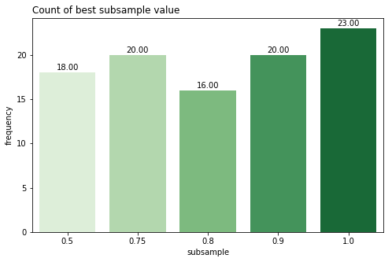

```python
plt.figure(figsize=(8,5))

best_param_freq = sns.countplot(best_subsample_values['param_value'], palette='Greens')

for p in best_param_freq.patches:
    best_param_freq.annotate(format(p.get_height(), '.2f'), (p.get_x() + p.get_width() / 2., p.get_height()),
                             ha = 'center', va = 'center', xytext = (0, 6), textcoords = 'offset points')

plt.ylabel('frequency')
plt.xlabel('subsample')
plt.title('Count of best subsample value', loc='left')
```

(Main conclusions)

```python
# plt.figure(figsize=(12,5))

# best_param_freq = sns.countplot(best_subsample_values['param_value'], palette='Greens',
#                                 hue=best_subsample_values['quartile_n_orders'])

# for p in best_param_freq.patches:
#     best_param_freq.annotate(format(p.get_height(), '.2f'), (p.get_x() + p.get_width() / 2., p.get_height()),
#                              ha = 'center', va = 'center', xytext = (0, 6), textcoords = 'offset points')

# plt.ylabel('frequency')
# plt.xlabel('subsample')
# # plt.legend(loc='upper center', title='quartile_n_orders')
# plt.legend(loc='upper left', title='quartile_n_orders', bbox_to_anchor=(1.01, 1), borderaxespad=0.)
# plt.title('Count of best subsample value', loc='left')
```

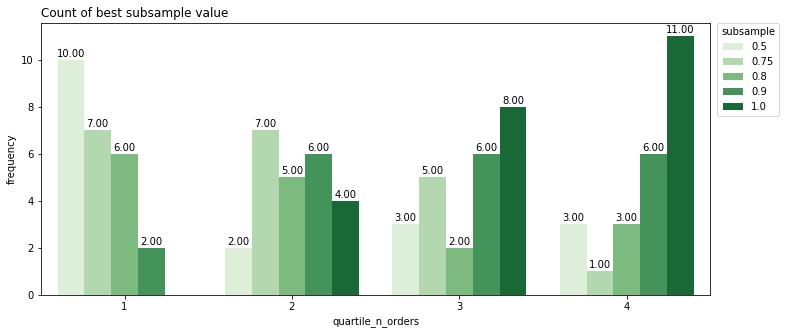

```python
plt.figure(figsize=(12,5))

best_param_freq = sns.countplot(best_subsample_values['quartile_n_orders'], palette='Greens',
                                hue=best_subsample_values['param_value'])

for p in best_param_freq.patches:
    best_param_freq.annotate(format(p.get_height(), '.2f'), (p.get_x() + p.get_width() / 2., p.get_height()),
                             ha = 'center', va = 'center', xytext = (0, 6), textcoords = 'offset points')

plt.ylabel('frequency')
plt.xlabel('quartile_n_orders')
plt.legend(loc='upper left', title='subsample', bbox_to_anchor=(1.01, 1), borderaxespad=0.)
plt.title('Count of best subsample value', loc='left')
```

(Main conclusions)

```python
# plt.figure(figsize=(12,5))

# best_param_freq = sns.countplot(best_subsample_values['param_value'], palette='Greens',
#                                 hue=best_subsample_values['quartile_n_vars'])

# for p in best_param_freq.patches:
#     best_param_freq.annotate(format(p.get_height(), '.2f'), (p.get_x() + p.get_width() / 2., p.get_height()),
#                              ha = 'center', va = 'center', xytext = (0, 6), textcoords = 'offset points')

# plt.ylabel('frequency')
# plt.xlabel('subsample')
# plt.legend(loc='upper left', title='quartile_n_vars', bbox_to_anchor=(1.01, 1), borderaxespad=0.)
# plt.title('Count of best subsample value', loc='left')
```

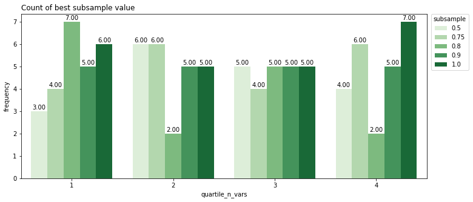

```python
plt.figure(figsize=(12,5))

best_param_freq = sns.countplot(best_subsample_values['quartile_n_vars'], palette='Greens',
                                hue=best_subsample_values['param_value'])

for p in best_param_freq.patches:
    best_param_freq.annotate(format(p.get_height(), '.2f'), (p.get_x() + p.get_width() / 2., p.get_height()),
                             ha = 'center', va = 'center', xytext = (0, 6), textcoords = 'offset points')

plt.ylabel('frequency')
plt.xlabel('quartile_n_vars')
plt.legend(loc='upper left', title='subsample', bbox_to_anchor=(1.01, 1), borderaxespad=0.)
plt.title('Count of best subsample value', loc='left')
```

#### Performance metric against dataset information

```python
# Select a performance metric:
metric = 'test_roc_auc'

px.scatter(data_frame=metrics_subsample,
           x='n_orders', y=metric, hover_data=['store_id', 'param_value'],
           color_discrete_sequence=['#0b6fab'], trendline='ols',
           width=900, height=500, title='Relationship between ' + metric + ' and dataset sizes')
```

[interactive chart not shown]

(Main conclusions)

```python
# Select a performance metric:
metric = 'test_roc_auc'

px.scatter(data_frame=metrics_subsample,
           x='n_vars', y=metric, hover_data=['store_id', 'param_value'],
           color_discrete_sequence=['#0b6fab'],
           width=900, height=500, title='Relationship between ' + metric + ' and number of features')
```

[interactive chart not shown]

#### Distribution of performance metric by best hyper-parameter value

```python
px.strip(data_frame=best_subsample_values.sort_values('param_value'),
         x=best_subsample_values.sort_values('param_value')['param_value'].apply(lambda x: 'eta = ' + str(x)),
         y=best_subsample_values.sort_values('param_value')['test_roc_auc'],
         hover_data=['store_id', 'param_value'],
         color_discrete_sequence=['#0b6fab'],
         width=900, height=500, title='Distribution of test_roc_auc by best subsample value',
         labels={'y': 'test_roc_auc', 'x': ''})
```

[interactive chart not shown]

(Main conclusions)

#### Correlation between performance metric of best hyper-parameter value and dataset information

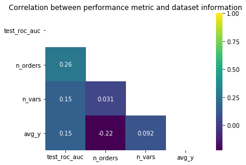

```python
# Generate a mask for the upper triangle:
mask = np.triu(np.ones_like(best_subsample_values[['test_roc_auc', 'n_orders', 'n_vars', 'avg_y']].corr(),
                            dtype=np.bool))

sns.heatmap(best_subsample_values[['test_roc_auc', 'n_orders', 'n_vars', 'avg_y']].corr(),
            mask = mask, annot = True, cmap = 'viridis')
plt.title('Correlation between performance metric and dataset information')
plt.tight_layout()
```

```python
# Generate masks for the upper triangle:
mask05 = np.triu(np.ones_like(metrics_subsample[metrics_subsample.param_value==0.5][['test_roc_auc',
                                                                                 'n_orders', 'n_vars',
                                                                                 'avg_y']].corr(), dtype=np.bool))
mask075 = np.triu(np.ones_like(metrics_subsample[metrics_subsample.param_value==0.75][['test_roc_auc',
                                                                                 'n_orders', 'n_vars',
                                                                                 'avg_y']].corr(), dtype=np.bool))
mask1 = np.triu(np.ones_like(metrics_subsample[metrics_subsample.param_value==1][['test_roc_auc',
                                                                                 'n_orders', 'n_vars',
                                                                                 'avg_y']].corr(), dtype=np.bool))
```

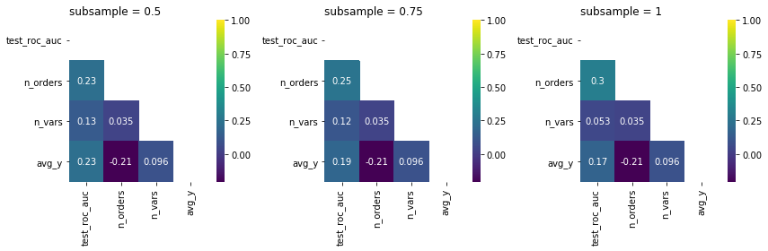

```python
fig, axs = plt.subplots(nrows=1, ncols=3, figsize=(12,4))

corr_matrices = sns.heatmap(metrics_subsample[metrics_subsample.param_value==0.5][['test_roc_auc', 'n_orders',
                                                                 'n_vars', 'avg_y']].corr(),
                            mask = mask05, annot = True, cmap = 'viridis', ax=axs[0])
sns.heatmap(metrics_subsample[metrics_subsample.param_value==0.75][['test_roc_auc', 'n_orders',
                                                                 'n_vars', 'avg_y']].corr(),
            mask = mask075, annot = True, cmap = 'viridis', ax=axs[1])
sns.heatmap(metrics_subsample[metrics_subsample.param_value==1][['test_roc_auc', 'n_orders',
                                                                 'n_vars', 'avg_y']].corr(),
            mask = mask1, annot = True, cmap = 'viridis', ax=axs[2])


axs[0].set_title('subsample = 0.5', loc='left')
axs[1].set_title('subsample = 0.75', loc='left')
axs[2].set_title('subsample = 1', loc='left')

plt.tight_layout()
```

(Main conclusions)

## Max depth

Since outcomes for $n\_estimators = 500$ produced similar conclusions as those for $n\_estimators = 1000$, only results for the first specification are presented and discussed below.

### Processing data

#### Performance metrics

```python
# Assessing missing hyper-parameter values:
for s in tun_max_depth['500'].keys():
    for m in ['test_roc_auc', 'test_prec_avg', 'test_pr_auc', 'test_deviance', 'test_brier_score']:
        if len(tun_max_depth['500'][s][m].keys()) != 10:
            print('Missing hyper-parameter value for store ' + str(s) + ' and metric ' + m + '!')
```

```python
# Collecting reference data:
param_value = []
stores = []

# Loop over datasets:
for s in tun_max_depth['500'].keys():
    # Loop over hyper-parameter values:
    for v in tun_max_depth['500'][s]['test_roc_auc'].keys():
        param_value.append(float(v))
        stores.append(int(s))

metrics_max_depth = pd.DataFrame(data=param_value, columns=['param_value'], index=stores)

# Collecting performance metrics:
for m in ['test_roc_auc', 'test_prec_avg', 'test_pr_auc', 'test_deviance', 'test_brier_score']:
    stores = []
    param_value = []
    ref = []

    # Loop over datasets:
    for s in tun_max_depth['500'].keys():
        # Loop over hyper-parameter values:
        for v in tun_max_depth['500'][s][m].keys():
            stores.append(int(s))
            ref.append(float(tun_max_depth['500'][s][m][v]))

    metrics_max_depth = pd.concat([metrics_max_depth, pd.DataFrame(data={m: ref},
                                                                   index=stores)], axis=1)

metrics_max_depth.index.name = 'store_id'
metrics_max_depth.reset_index(inplace=True, drop=False)
print('\033[1mShape of metrics_max_depth:\033[0m ' + str(metrics_max_depth.shape) + '.')
metrics_max_depth.index.name = 'n_est_500'
metrics_max_depth.head()
```

```
Shape of metrics_max_depth: (1000, 7).
```

| n_est_500 | store_id | param_value | test_roc_auc | test_prec_avg | test_pr_auc | test_deviance | test_brier_score |
| --- | --- | --- | --- | --- | --- | --- | --- |
| 0 | 11729 | 1.0 | 0.799801 | 0.202104 | 0.190858 | 883.126107 | 0.042397 |
| 1 | 11729 | 2.0 | 0.792224 | 0.168588 | 0.162599 | 886.386542 | 0.044716 |
| 2 | 11729 | 3.0 | 0.767131 | 0.193678 | 0.188664 | 886.381210 | 0.042318 |
| 3 | 11729 | 4.0 | 0.767399 | 0.155830 | 0.150081 | 886.556028 | 0.050345 |
| 4 | 11729 | 5.0 | 0.762692 | 0.163812 | 0.157680 | 887.063994 | 0.044718 |

### Statistics by hyper-parameter value

#### Basic statistics for each performance metric

```python
# Test ROC-AUC:
metrics_max_depth.groupby('param_value').describe()[['test_roc_auc']].sort_values(('test_roc_auc','mean'),
                                                                                     ascending=False)
```

| param_value | test_roc_auc count | test_roc_auc mean | test_roc_auc std | test_roc_auc min | test_roc_auc 25% | test_roc_auc 50% | test_roc_auc 75% | test_roc_auc max |
| --- | --- | --- | --- | --- | --- | --- | --- | --- |
| 1.0 | 97.0 | 0.841187 | 0.148197 | 0.425634 | 0.799801 | 0.894203 | 0.945233 | 0.983908 |
| 2.0 | 97.0 | 0.825810 | 0.150996 | 0.465879 | 0.729167 | 0.878254 | 0.944719 | 0.987558 |
| 3.0 | 97.0 | 0.825704 | 0.151371 | 0.342522 | 0.756858 | 0.876992 | 0.941152 | 0.989621 |
| 4.0 | 97.0 | 0.815601 | 0.156948 | 0.342522 | 0.729167 | 0.883343 | 0.938803 | 0.976326 |
| 5.0 | 97.0 | 0.804321 | 0.163414 | 0.342522 | 0.707682 | 0.866204 | 0.929771 | 0.976286 |
| 6.0 | 97.0 | 0.801520 | 0.163155 | 0.342522 | 0.707006 | 0.869632 | 0.929517 | 0.977266 |
| 7.0 | 97.0 | 0.799921 | 0.159337 | 0.340212 | 0.698893 | 0.858816 | 0.929307 | 0.979190 |
| 10.0 | 97.0 | 0.796034 | 0.160304 | 0.342522 | 0.698893 | 0.860084 | 0.931680 | 0.971219 |
| 8.0 | 97.0 | 0.790829 | 0.161324 | 0.342097 | 0.683002 | 0.836210 | 0.925192 | 0.971589 |
| 9.0 | 97.0 | 0.789882 | 0.160268 | 0.345015 | 0.675557 | 0.843485 | 0.923188 | 0.969461 |

```python
# Test average precision score:
metrics_max_depth.groupby('param_value').describe()[['test_prec_avg']].sort_values(('test_prec_avg','mean'),
                                                                                      ascending=False)
```

| param_value | test_prec_avg count | test_prec_avg mean | test_prec_avg std | test_prec_avg min | test_prec_avg 25% | test_prec_avg 50% | test_prec_avg 75% | test_prec_avg max |
| --- | --- | --- | --- | --- | --- | --- | --- | --- |
| 1.0 | 97.0 | 0.426941 | 0.273931 | 0.000955 | 0.187745 | 0.433220 | 0.637111 | 0.958824 |
| 2.0 | 97.0 | 0.402451 | 0.277224 | 0.000957 | 0.152394 | 0.401729 | 0.625110 | 0.951153 |
| 3.0 | 97.0 | 0.397657 | 0.270624 | 0.000955 | 0.153609 | 0.393805 | 0.571968 | 0.963264 |
| 4.0 | 97.0 | 0.382716 | 0.269435 | 0.000955 | 0.155757 | 0.379758 | 0.547551 | 0.946950 |
| 5.0 | 97.0 | 0.371813 | 0.267998 | 0.000955 | 0.123284 | 0.364669 | 0.545421 | 0.945034 |
| 7.0 | 97.0 | 0.371563 | 0.262966 | 0.000955 | 0.137383 | 0.366164 | 0.558613 | 0.944771 |
| 6.0 | 97.0 | 0.368960 | 0.264474 | 0.000955 | 0.149057 | 0.361240 | 0.566827 | 0.939298 |
| 9.0 | 97.0 | 0.368943 | 0.259287 | 0.000955 | 0.141054 | 0.358118 | 0.565056 | 0.936805 |
| 10.0 | 97.0 | 0.364097 | 0.258891 | 0.000955 | 0.149441 | 0.353629 | 0.561312 | 0.937545 |
| 8.0 | 97.0 | 0.361578 | 0.259191 | 0.000955 | 0.132341 | 0.361462 | 0.542218 | 0.935539 |

```python
# Test Brier score:
metrics_max_depth.groupby('param_value').describe()[['test_brier_score']].sort_values(('test_brier_score',
                                                                                          'mean'),
                                                                                          ascending=True)
```

| param_value | test_brier_score count | test_brier_score mean | test_brier_score std | test_brier_score min | test_brier_score 25% | test_brier_score 50% | test_brier_score 75% | test_brier_score max |
| --- | --- | --- | --- | --- | --- | --- | --- | --- |
| 1.0 | 97.0 | 0.032823 | 0.035779 | 0.001986 | 0.010401 | 0.015987 | 0.039450 | 0.194459 |
| 2.0 | 97.0 | 0.035347 | 0.042071 | 0.001986 | 0.010675 | 0.017662 | 0.044560 | 0.291535 |
| 3.0 | 97.0 | 0.037713 | 0.045067 | 0.001986 | 0.012145 | 0.017770 | 0.042318 | 0.259594 |
| 4.0 | 97.0 | 0.039558 | 0.047411 | 0.001696 | 0.012281 | 0.019784 | 0.049748 | 0.303914 |
| 6.0 | 97.0 | 0.040711 | 0.048724 | 0.001986 | 0.012520 | 0.020009 | 0.049730 | 0.310055 |
| 7.0 | 97.0 | 0.040738 | 0.050700 | 0.001986 | 0.012128 | 0.020872 | 0.050131 | 0.334709 |
| 5.0 | 97.0 | 0.041567 | 0.053825 | 0.001986 | 0.011976 | 0.019547 | 0.052518 | 0.318168 |
| 9.0 | 97.0 | 0.043040 | 0.051975 | 0.001986 | 0.012071 | 0.021142 | 0.049568 | 0.307962 |
| 8.0 | 97.0 | 0.043933 | 0.056046 | 0.001986 | 0.012262 | 0.022174 | 0.048213 | 0.325822 |
| 10.0 | 97.0 | 0.044396 | 0.057021 | 0.001986 | 0.012949 | 0.021921 | 0.049198 | 0.312928 |

```python
# Test binomial deviance:
metrics_max_depth.groupby('param_value').describe()[['test_deviance']].sort_values(('test_deviance','mean'),
                                                                                      ascending=True)
```

| param_value | test_deviance count | test_deviance mean | test_deviance std | test_deviance min | test_deviance 25% | test_deviance 50% | test_deviance 75% | test_deviance max |
| --- | --- | --- | --- | --- | --- | --- | --- | --- |
| 2.0 | 97.0 | 2426.147665 | 3871.125218 | 53.324620 | 344.767153 | 948.088369 | 2672.433325 | 22105.023547 |
| 1.0 | 97.0 | 2426.386405 | 3871.859300 | 53.256342 | 342.130251 | 948.710862 | 2675.599571 | 22106.268100 |
| 3.0 | 97.0 | 2427.221373 | 3871.897265 | 53.591019 | 345.214135 | 949.504788 | 2700.972259 | 22108.358513 |
| 4.0 | 97.0 | 2429.756062 | 3872.463923 | 53.578234 | 345.201517 | 949.867042 | 2704.052297 | 22109.552005 |
| 7.0 | 97.0 | 2430.503570 | 3874.713018 | 53.212640 | 344.720362 | 949.363402 | 2722.227362 | 22113.826921 |
| 5.0 | 97.0 | 2430.829649 | 3872.111048 | 53.593222 | 345.674943 | 950.243216 | 2718.823836 | 22108.703532 |
| 6.0 | 97.0 | 2430.868484 | 3873.741551 | 53.420216 | 345.509969 | 949.255666 | 2723.489066 | 22113.388842 |
| 9.0 | 97.0 | 2431.887961 | 3874.615304 | 53.433251 | 345.586796 | 949.593043 | 2723.438027 | 22115.963760 |
| 8.0 | 97.0 | 2432.671022 | 3874.449826 | 53.493874 | 344.172118 | 949.885844 | 2721.690689 | 22114.963005 |
| 10.0 | 97.0 | 2432.774813 | 3873.958678 | 53.534943 | 344.385685 | 951.416242 | 2723.058690 | 22111.666717 |

#### Averages of performance metrics by hyper-parameter value

```python
metrics_max_depth.groupby('param_value').mean().sort_values('test_roc_auc', ascending=False).drop('store_id',
                                                                                                     axis=1)
```

| param_value | test_roc_auc | test_prec_avg | test_pr_auc | test_deviance | test_brier_score |
| --- | --- | --- | --- | --- | --- |
| 1.0 | 0.841187 | 0.426941 | 0.439019 | 2426.386405 | 0.032823 |
| 2.0 | 0.825810 | 0.402451 | 0.414524 | 2426.147665 | 0.035347 |
| 3.0 | 0.825704 | 0.397657 | 0.413852 | 2427.221373 | 0.037713 |
| 4.0 | 0.815601 | 0.382716 | 0.399175 | 2429.756062 | 0.039558 |
| 5.0 | 0.804321 | 0.371813 | 0.393864 | 2430.829649 | 0.041567 |
| 6.0 | 0.801520 | 0.368960 | 0.395578 | 2430.868484 | 0.040711 |
| 7.0 | 0.799921 | 0.371563 | 0.395777 | 2430.503570 | 0.040738 |
| 10.0 | 0.796034 | 0.364097 | 0.397419 | 2432.774813 | 0.044396 |
| 8.0 | 0.790829 | 0.361578 | 0.388535 | 2432.671022 | 0.043933 |
| 9.0 | 0.789882 | 0.368943 | 0.394987 | 2431.887961 | 0.043040 |

(Main conclusions)

#### Frequency of best hyper-parameter values

```python
best_max_dep_values = metrics_max_depth.groupby('store_id').idxmax()['test_roc_auc'].values
print('\033[1mRelative frequency of highest performance metric by hyper-parameter value:\033[0m')
print(metrics_max_depth.reindex(best_max_dep_values).param_value.value_counts()/len(best_max_dep_values))
```

```
Relative frequency of highest performance metric by hyper-parameter value:
1.0     0.43
2.0     0.21
3.0     0.10
5.0     0.05
4.0     0.05
6.0     0.04
8.0     0.03
9.0     0.02
7.0     0.02
10.0    0.02
Name: param_value, dtype: float64
```

#### Average performance metric by best hyper-parameter value

```python
# Dataframe with best hyper-parameter value by dataset:
best_max_dep_values = metrics_max_depth.reindex(best_max_dep_values)[['store_id', 'param_value',
                                                                           'test_roc_auc']]
best_max_dep_values = best_max_dep_values.merge(data_info, on='store_id', how='inner')
print('\033[1mShape of best_max_dep_values:\033[0m ' + str(best_max_dep_values.shape) + '.')
best_max_dep_values.head()
```

```
Shape of best_max_dep_values: (97, 6).
```

|  | store_id | param_value | test_roc_auc | n_orders | n_vars | avg_y |
| --- | --- | --- | --- | --- | --- | --- |
| 0 | 720.0 | 2.0 | 0.835490 | 4028 | 1858 | 0.011668 |
| 1 | 1098.0 | 1.0 | 0.968112 | 19152 | 4026 | 0.023705 |
| 2 | 1181.0 | 1.0 | 0.983908 | 3467 | 2698 | 0.033458 |
| 3 | 1210.0 | 1.0 | 0.500000 | 4028 | 2101 | 0.001490 |
| 4 | 1241.0 | 1.0 | 0.887821 | 206 | 3791 | 0.320388 |

```python
best_max_dep_values.groupby('param_value').mean().sort_values('test_roc_auc', ascending=False)[['test_roc_auc']]
```

| param_value | test_roc_auc |
| --- | --- |
| 6.0 | 0.908504 |
| 4.0 | 0.902775 |
| 8.0 | 0.894004 |
| 9.0 | 0.882947 |
| 1.0 | 0.874373 |
| 2.0 | 0.853647 |
| 5.0 | 0.819399 |
| 3.0 | 0.813259 |
| 7.0 | 0.762852 |
| 10.0 | 0.732427 |

### Describing hyper-parameter values

#### Average numbers of observations and features by best hyper-parameter value

```python
best_max_dep_values.groupby('param_value').mean()[['n_orders']].sort_values('n_orders', ascending=False)
```

| param_value | n_orders |
| --- | --- |
| 5.0 | 26288.800000 |
| 4.0 | 15446.400000 |
| 7.0 | 6814.000000 |
| 2.0 | 6788.238095 |
| 1.0 | 5827.604651 |
| 3.0 | 4200.400000 |
| 6.0 | 3685.500000 |
| 8.0 | 2874.333333 |
| 9.0 | 2116.500000 |
| 10.0 | 1332.000000 |

```python
best_max_dep_values.groupby('param_value').mean()[['n_vars']].sort_values('n_vars', ascending=False)
```

| param_value | n_vars |
| --- | --- |
| 10.0 | 2772.500000 |
| 3.0 | 2456.300000 |
| 6.0 | 2391.500000 |
| 5.0 | 2358.400000 |
| 1.0 | 2357.465116 |
| 9.0 | 2353.000000 |
| 8.0 | 2330.333333 |
| 2.0 | 2327.952381 |
| 4.0 | 2290.600000 |
| 7.0 | 2261.500000 |

#### Average of response variable by best hyper-parameter value

```python
best_max_dep_values.groupby('param_value').mean()[['avg_y']].sort_values('avg_y', ascending=False)
```

| param_value | avg_y |
| --- | --- |
| 8.0 | 0.080393 |
| 1.0 | 0.061088 |
| 10.0 | 0.057387 |
| 3.0 | 0.044043 |
| 4.0 | 0.043365 |
| 2.0 | 0.042684 |
| 6.0 | 0.035540 |
| 9.0 | 0.032908 |
| 5.0 | 0.007898 |
| 7.0 | 0.006682 |

#### Most frequent best hyper-parameter values by quartile of number of observations

```python
best_max_dep_values['quartile_n_orders'] = percentile_cut(best_max_dep_values.n_orders, p=4)['percentile']

print('\033[1mFrequency of best hyper-parameter values by quartile of number of observations:\033[0m')
for q in range(1,5):
    print('\033[1mNumber of orders in ' +
          str(np.sort(np.unique(percentile_cut(best_max_dep_values.n_orders, p=4)['interval']))[q-1]) +
          ' (quartile ' + str(q) + ')\033[0m:')
    print(best_max_dep_values[best_max_dep_values.quartile_n_orders==q].param_value.value_counts())
    print('\n')
```

```
Frequency of best hyper-parameter values by quartile of number of observations:
Number of orders in (156.998, 999.0] (quartile 1):
1.0    14
2.0     5
3.0     3
8.0     1
9.0     1
6.0     1
Name: param_value, dtype: int64


Number of orders in (999.0, 2812.0] (quartile 2):
1.0     10
3.0      4
2.0      4
10.0     2
4.0      1
5.0      1
7.0      1
6.0      1
Name: param_value, dtype: int64


Number of orders in (2812.0, 7946.0] (quartile 3):
1.0    12
2.0     4
8.0     2
3.0     2
6.0     2
5.0     1
9.0     1
Name: param_value, dtype: int64


Number of orders in (7946.0, 63963.001] (quartile 4):
2.0    8
1.0    7
4.0    4
5.0    3
7.0    1
3.0    1
Name: param_value, dtype: int64
```

#### Most frequent best hyper-parameter values by quartile of number of features

```python
best_max_dep_values['quartile_n_vars'] = percentile_cut(best_max_dep_values.n_vars, p=4)['percentile']

print('\033[1mFrequency of best hyper-parameter values by quartile of number of features:\033[0m')
for q in range(1,5):
    print('\033[1mNumber of vars in ' +
          str(np.sort(np.unique(percentile_cut(best_max_dep_values.n_vars, p=4)['interval']))[q-1]) +
          ' (quartile ' + str(q) + ')\033[0m:')
    print(best_max_dep_values[best_max_dep_values.quartile_n_vars==q].param_value.value_counts())
    print('\n')
```

```
Frequency of best hyper-parameter values by quartile of number of features:
Number of vars in (1415.998, 2069.0] (quartile 1):
1.0    14
2.0     4
8.0     2
4.0     1
3.0     1
9.0     1
7.0     1
5.0     1
Name: param_value, dtype: int64


Number of vars in (2069.0, 2321.0] (quartile 2):
1.0    10
2.0     7
3.0     4
5.0     1
4.0     1
6.0     1
Name: param_value, dtype: int64


Number of vars in (2321.0, 2534.0] (quartile 3):
1.0     8
2.0     6
6.0     3
3.0     2
4.0     2
7.0     1
10.0    1
5.0     1
Name: param_value, dtype: int64


Number of vars in (2534.0, 4026.001] (quartile 4):
1.0     11
2.0      4
3.0      3
5.0      2
4.0      1
10.0     1
8.0      1
9.0      1
Name: param_value, dtype: int64
```

#### Correlation between performance metric of best hyper-parameter value and dataset information

```python
best_max_dep_values[['test_roc_auc', 'n_orders', 'n_vars', 'avg_y']].corr()[['test_roc_auc']]
```

|  | test_roc_auc |
| --- | --- |
| test_roc_auc | 1.000000 |
| n_orders | 0.282984 |
| n_vars | 0.077852 |
| avg_y | 0.149174 |

#### Correlation between performance metric and dataset information by hyper-parameter value

```python
metrics_max_depth = metrics_max_depth.merge(data_info, on='store_id', how='left')
print('\033[1mShape of metrics_max_depth:\033[0m ' + str(metrics_max_depth.shape) + '.')
metrics_max_depth.head()
```

```
Shape of metrics_max_depth: (1000, 10).
```

|  | store_id | param_value | test_roc_auc | test_prec_avg | test_pr_auc | test_deviance | test_brier_score | n_orders | n_vars | avg_y |
| --- | --- | --- | --- | --- | --- | --- | --- | --- | --- | --- |
| 0 | 11729 | 1.0 | 0.799801 | 0.202104 | 0.190858 | 883.126107 | 0.042397 | 2570 | 1596 | 0.037354 |
| 1 | 11729 | 2.0 | 0.792224 | 0.168588 | 0.162599 | 886.386542 | 0.044716 | 2570 | 1596 | 0.037354 |
| 2 | 11729 | 3.0 | 0.767131 | 0.193678 | 0.188664 | 886.381210 | 0.042318 | 2570 | 1596 | 0.037354 |
| 3 | 11729 | 4.0 | 0.767399 | 0.155830 | 0.150081 | 886.556028 | 0.050345 | 2570 | 1596 | 0.037354 |
| 4 | 11729 | 5.0 | 0.762692 | 0.163812 | 0.157680 | 887.063994 | 0.044718 | 2570 | 1596 | 0.037354 |

```python
for v in metrics_max_depth.param_value.unique():
    print('\033[1mmax_depth = ' + str(v) + '\033[0m')
    print(metrics_max_depth[metrics_max_depth.param_value==v][['test_roc_auc',
                                                               'n_orders', 'n_vars',
                                                               'avg_y']].corr()[['test_roc_auc']])
    print('\n')
```

```
max_depth = 1.0
              test_roc_auc
test_roc_auc      1.000000
n_orders          0.238079
n_vars            0.053221
avg_y             0.185016


max_depth = 2.0
              test_roc_auc
test_roc_auc      1.000000
n_orders          0.284880
n_vars            0.065660
avg_y             0.197535


max_depth = 3.0
              test_roc_auc
test_roc_auc      1.000000
n_orders          0.309374
n_vars            0.074121
avg_y             0.171135


max_depth = 4.0
              test_roc_auc
test_roc_auc      1.000000
n_orders          0.348119
n_vars            0.062314
avg_y             0.153233


max_depth = 5.0
              test_roc_auc
test_roc_auc      1.000000
n_orders          0.328632
n_vars            0.021363
avg_y             0.158820


```

[output cut: 23 more lines]

```

max_depth = 9.0
              test_roc_auc
test_roc_auc      1.000000
n_orders          0.367462
n_vars            0.018386
avg_y             0.153566


max_depth = 10.0
              test_roc_auc
test_roc_auc      1.000000
n_orders          0.347318
n_vars            0.024389
avg_y             0.152751
```

### Data visualization

#### Average of performance metric by hyper-parameter value

```python
# Select a performance metric:
metric = 'test_roc_auc'

fig=px.scatter(x=metrics_max_depth['param_value'].unique(),
               y=metrics_max_depth.groupby('param_value').mean()[metric],
               error_y=np.array(metrics_max_depth.groupby('param_value').std()['test_roc_auc']),
               color_discrete_sequence=['#0b6fab'],
               width=900, height=500,
               title='Average of ' + metric + ' by max depth value',
               labels={'y': metric, 'x': 'max_depth'})

fig.add_trace(
    go.Scatter(
        x=metrics_max_depth['param_value'].unique(),
        y=metrics_max_depth.groupby('param_value').mean()[metric],
        line = dict(color='#0b6fab', width=2, dash='dash'),
        name='avg_' + metric
              )
)
```

[interactive chart not shown]

#### Boxplot of performance metric by hyper-parameter value

```python
# Select a performance metric:
metric = 'test_roc_auc'

px.box(data_frame=metrics_max_depth,
       x=metrics_max_depth['param_value'],
       y=metric, hover_data=['store_id'],
       color_discrete_sequence=['#0b6fab'],
       width=900, height=500,
       labels={'param_value': 'max_deph'},
       title='Distribution of ' + metric + ' by max depth value')
```

[interactive chart not shown]

#### Frequency of best hyper-parameter values

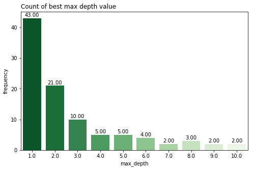

```python
plt.figure(figsize=(8,5))

best_param_freq = sns.countplot(best_max_dep_values['param_value'], palette='Greens_r')

for p in best_param_freq.patches:
    best_param_freq.annotate(format(p.get_height(), '.2f'), (p.get_x() + p.get_width() / 2., p.get_height()),
                             ha = 'center', va = 'center', xytext = (0, 6), textcoords = 'offset points')

plt.ylabel('frequency')
plt.xlabel('max_depth')
plt.title('Count of best max depth value', loc='left')
```

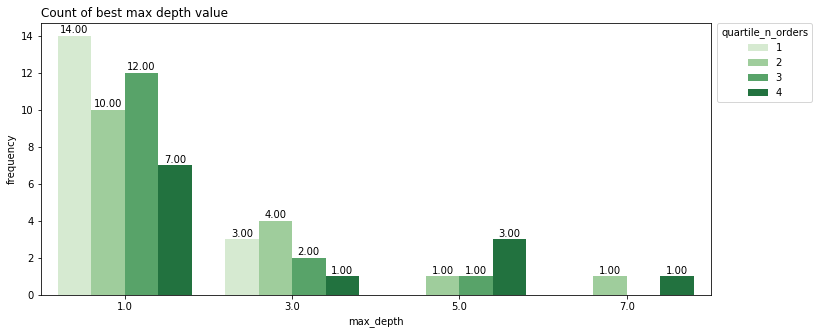

```python
plt.figure(figsize=(12,5))

best_param_freq = sns.countplot(best_max_dep_values[best_max_dep_values.param_value.isin([1,3,5,7])]['param_value'], palette='Greens',
                                hue=best_max_dep_values[best_max_dep_values.param_value.isin([1,3,5,7])]['quartile_n_orders'])

for p in best_param_freq.patches:
    best_param_freq.annotate(format(p.get_height(), '.2f'), (p.get_x() + p.get_width() / 2., p.get_height()),
                             ha = 'center', va = 'center', xytext = (0, 6), textcoords = 'offset points')

plt.ylabel('frequency')
plt.xlabel('max_depth')
plt.legend(loc='upper left', title='quartile_n_orders', bbox_to_anchor=(1.01, 1), borderaxespad=0.)
plt.title('Count of best max depth value', loc='left')
```

```python
# plt.figure(figsize=(12,5))

# best_param_freq = sns.countplot(best_max_dep_values[best_max_dep_values.param_value.isin([1,3,5,7])]['quartile_n_orders'],
#                                 palette='Greens_r',
#                                 hue=best_max_dep_values[best_max_dep_values.param_value.isin([1,3,5,7])]['param_value'])

# for p in best_param_freq.patches:
#     best_param_freq.annotate(format(p.get_height(), '.2f'), (p.get_x() + p.get_width() / 2., p.get_height()),
#                              ha = 'center', va = 'center', xytext = (0, 6), textcoords = 'offset points')

# plt.ylabel('frequency')
# plt.xlabel('quartile_n_orders')
# plt.legend(loc='upper left', title='max_depth', bbox_to_anchor=(1.01, 1), borderaxespad=0.)
# plt.title('Count of best max depth value', loc='left')
```

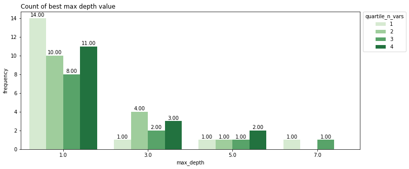

```python
plt.figure(figsize=(12,5))

best_param_freq = sns.countplot(best_max_dep_values[best_max_dep_values.param_value.isin([1,3,5,7])]['param_value'],
                                palette='Greens',
                                hue=best_max_dep_values[best_max_dep_values.param_value.isin([1,3,5,7])]['quartile_n_vars'])

for p in best_param_freq.patches:
    best_param_freq.annotate(format(p.get_height(), '.2f'), (p.get_x() + p.get_width() / 2., p.get_height()),
                             ha = 'center', va = 'center', xytext = (0, 6), textcoords = 'offset points')

plt.ylabel('frequency')
plt.xlabel('max_depth')
plt.legend(loc='upper left', title='quartile_n_vars', bbox_to_anchor=(1.01, 1), borderaxespad=0.)
plt.title('Count of best max depth value', loc='left')
```

```python
# plt.figure(figsize=(12,5))

# best_param_freq = sns.countplot(best_max_dep_values[best_max_dep_values.param_value.isin([1,3,5,7])]['quartile_n_vars'],
#                                 palette='Greens_r',
#                                 hue=best_max_dep_values[best_max_dep_values.param_value.isin([1,3,5,7])]['param_value'])

# for p in best_param_freq.patches:
#     best_param_freq.annotate(format(p.get_height(), '.2f'), (p.get_x() + p.get_width() / 2., p.get_height()),
#                              ha = 'center', va = 'center', xytext = (0, 6), textcoords = 'offset points')

# plt.ylabel('frequency')
# plt.xlabel('quartile_n_vars')
# plt.legend(loc='upper left', title='max_depth', bbox_to_anchor=(1.01, 1), borderaxespad=0.)
# plt.title('Count of best max depth value', loc='left')
```

(Main conclusion)

#### Performance metric against dataset information

When exploring max depth, the plot of performance metrics against numbers of observations and features produce the same patters as those obtained when exploring subsample.

#### Distribution of performance metric by best hyper-parameter value

```python
px.strip(data_frame=best_max_dep_values.sort_values('param_value'),
         x=best_max_dep_values.sort_values('param_value')['param_value'],
         y=best_max_dep_values.sort_values('param_value')['test_roc_auc'],
         hover_data=['store_id', 'param_value'],
         color_discrete_sequence=['#0b6fab'],
         width=900, height=500, title='Distribution of test_roc_auc by best max depth value',
         labels={'y': 'test_roc_auc', 'x': 'max_depth'})
```

[interactive chart not shown]

(Main conclusions)

#### Correlation between performance metric of best hyper-parameter value and dataset information

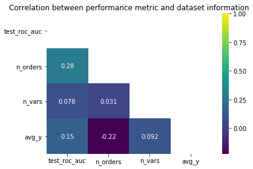

```python
# Generate a mask for the upper triangle
mask = np.triu(np.ones_like(best_max_dep_values[['test_roc_auc', 'n_orders', 'n_vars', 'avg_y']].corr(),
                            dtype=np.bool))

sns.heatmap(best_max_dep_values[['test_roc_auc', 'n_orders', 'n_vars', 'avg_y']].corr(),
            mask = mask, annot = True, cmap = 'viridis')
plt.title('Correlation between performance metric and dataset information')
plt.tight_layout()
```

```python
# Generate masks for the upper triangle:
mask1 = np.triu(np.ones_like(metrics_max_depth[metrics_max_depth.param_value==1][['test_roc_auc',
                                                                                 'n_orders', 'n_vars',
                                                                                 'avg_y']].corr(), dtype=np.bool))
mask4 = np.triu(np.ones_like(metrics_max_depth[metrics_max_depth.param_value==4][['test_roc_auc',
                                                                                 'n_orders', 'n_vars',
                                                                                 'avg_y']].corr(), dtype=np.bool))
mask10 = np.triu(np.ones_like(metrics_max_depth[metrics_max_depth.param_value==10][['test_roc_auc',
                                                                                 'n_orders', 'n_vars',
                                                                                 'avg_y']].corr(), dtype=np.bool))
```

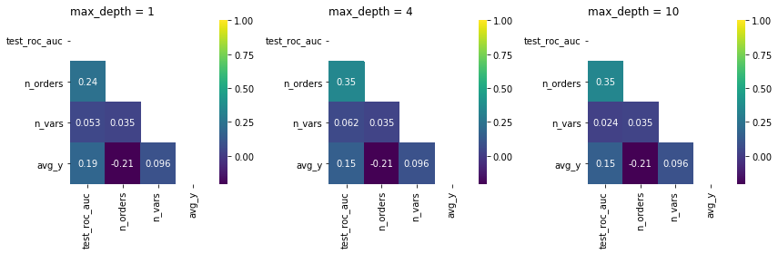

```python
fig, axs = plt.subplots(nrows=1, ncols=3, figsize=(12,4))

corr_matrices = sns.heatmap(metrics_max_depth[metrics_max_depth.param_value==1][['test_roc_auc', 'n_orders',
                                                                 'n_vars', 'avg_y']].corr(),
                            mask = mask1, annot = True, cmap = 'viridis', ax=axs[0])
sns.heatmap(metrics_max_depth[metrics_max_depth.param_value==4][['test_roc_auc', 'n_orders',
                                                                 'n_vars', 'avg_y']].corr(),
            mask = mask4, annot = True, cmap = 'viridis', ax=axs[1])
sns.heatmap(metrics_max_depth[metrics_max_depth.param_value==10][['test_roc_auc', 'n_orders',
                                                                 'n_vars', 'avg_y']].corr(),
            mask = mask10, annot = True, cmap = 'viridis', ax=axs[2])


axs[0].set_title('max_depth = 1', loc='left')
axs[1].set_title('max_depth = 4', loc='left')
axs[2].set_title('max_depth = 10', loc='left')

plt.tight_layout()
```

(Main conclusions)

## Learning rate

Since learning rates $v \in \{0.1, 0.2, 0.3, 0.4, 0.5, 0.6, 0.7, 0.8, 0.9\}$ are high and since high learning rates demand less estimators to learn from the data, this high-level set of learning rate values was tested using different values of $n\_estimators$. For all values tested $\{100, 250, 500\}$, performance metrics behaved very similarly. Therefore, outcomes presented and discussed next are based on $n\_estimators = 100$.

Main findings are listed below:

- Small values of learning rate ($v \leq 0.1$) perform notably better than large values ($v > 0.1$).
- The smallest value testes ($v = 0.01$) presented the best results.

### Processing data

#### Performance metrics

```python
# Assessing missing hyper-parameter values:
for s in tun_learning_rate['II100'].keys():
    for m in ['test_roc_auc', 'test_prec_avg', 'test_pr_auc', 'test_deviance', 'test_brier_score']:
        if len(tun_learning_rate['II100'][s][m].keys()) != 9:
            print('Missing hyper-parameter value for store ' + str(s) + ' and metric ' + m + '!')
```

```python
# Assessing missing hyper-parameter values:
for s in tun_learning_rate['II250'].keys():
    for m in ['test_roc_auc', 'test_prec_avg', 'test_pr_auc', 'test_deviance', 'test_brier_score']:
        if len(tun_learning_rate['II250'][s][m].keys()) != 9:
            print('Missing hyper-parameter value for store ' + str(s) + ' and metric ' + m + '!')
```

```python
# Assessing missing hyper-parameter values:
for s in tun_learning_rate['I500'].keys():
    for m in ['test_roc_auc', 'test_prec_avg', 'test_pr_auc', 'test_deviance', 'test_brier_score']:
        if len(tun_learning_rate['I500'][s][m].keys()) != 10:
            print('Missing hyper-parameter value for store ' + str(s) + ' and metric ' + m + '!')
```

```python
# Assessing missing hyper-parameter values:
for s in tun_learning_rate['II500'].keys():
    for m in ['test_roc_auc', 'test_prec_avg', 'test_pr_auc', 'test_deviance', 'test_brier_score']:
        if len(tun_learning_rate['II500'][s][m].keys()) != 9:
            print('Missing hyper-parameter value for store ' + str(s) + ' and metric ' + m + '!')
```

```python
param_value = []
n_estimators = []
stores = []
test_roc_auc = []
test_prec_avg = []
test_pr_auc = []
test_deviance = []
test_brier_score = []

for k in ['I500', 'II100']:
    # Loop over datasets:
    for s in tun_learning_rate[k].keys():
        # Loop over hyper-parameter values:
        for v in tun_learning_rate[k][s]['test_roc_auc'].keys():
            stores.append(int(s))
            param_value.append(float(v))
            n_estimators.append(int(''.join([l for l in k if l not in ['I','II']])))
            test_roc_auc.append(tun_learning_rate[k][s]['test_roc_auc'][v])
            test_prec_avg.append(tun_learning_rate[k][s]['test_prec_avg'][v])
            test_pr_auc.append(tun_learning_rate[k][s]['test_pr_auc'][v])
            test_deviance.append(tun_learning_rate[k][s]['test_deviance'][v])
            test_brier_score.append(tun_learning_rate[k][s]['test_brier_score'][v])

metrics_learning = pd.DataFrame(data={'store_id': stores, 'param_value': param_value,
                                      'n_estimators': n_estimators, 'test_roc_auc': test_roc_auc,
                                      'test_prec_avg': test_prec_avg, 'test_pr_auc': test_pr_auc,
                                      'test_deviance': test_deviance, 'test_brier_score': test_brier_score})

print('\033[1mShape of metrics_learning:\033[0m ' + str(metrics_learning.shape) + '.')
metrics_learning.head()
```

```
Shape of metrics_learning: (1900, 8).
```

|  | store_id | param_value | n_estimators | test_roc_auc | test_prec_avg | test_pr_auc | test_deviance | test_brier_score |
| --- | --- | --- | --- | --- | --- | --- | --- | --- |
| 0 | 11729 | 0.01 | 500 | 0.803433 | 0.185661 | 0.174569 | 885.786115 | 0.040213 |
| 1 | 11729 | 0.02 | 500 | 0.794294 | 0.186608 | 0.175391 | 885.608834 | 0.040245 |
| 2 | 11729 | 0.03 | 500 | 0.790233 | 0.179938 | 0.168800 | 885.986012 | 0.040583 |
| 3 | 11729 | 0.04 | 500 | 0.773131 | 0.172265 | 0.161658 | 886.580172 | 0.041621 |
| 4 | 11729 | 0.05 | 500 | 0.763760 | 0.169979 | 0.163959 | 886.331783 | 0.043942 |

```python
ref = metrics_learning[metrics_learning.param_value==0.1].groupby('store_id').mean()
ref.index.name = 'store_id'
ref.reset_index(inplace=True, drop=False)
metrics_learning = metrics_learning[~((metrics_learning.param_value==0.1))]

metrics_learning = pd.concat([ref, metrics_learning], axis=0, sort=False)
metrics_learning.reset_index(inplace=True, drop=True)
print('\033[1mShape of metrics_learning:\033[0m ' + str(metrics_learning.shape) + '.')
metrics_learning.head()
```

```
Shape of metrics_learning: (1800, 8).
```

|  | store_id | param_value | n_estimators | test_roc_auc | test_prec_avg | test_pr_auc | test_deviance | test_brier_score |
| --- | --- | --- | --- | --- | --- | --- | --- | --- |
| 0 | 720 | 0.1 | 300 | 0.785362 | 0.046540 | 0.044608 | 1394.933367 | 0.015207 |
| 1 | 1098 | 0.1 | 300 | 0.946788 | 0.605101 | 0.600243 | 6537.013276 | 0.015089 |
| 2 | 1181 | 0.1 | 300 | 0.973453 | 0.811561 | 0.811435 | 1180.313850 | 0.018021 |
| 3 | 1210 | 0.1 | 300 | 0.500000 | 0.001986 | 0.500993 | 1395.998422 | 0.001986 |
| 4 | 1241 | 0.1 | 300 | 0.857572 | 0.781923 | 0.777764 | 61.084691 | 0.231204 |

### Statistics by hyper-parameter value

#### Basic statistics for each performance metric

```python
# Test ROC-AUC:
metrics_learning.groupby('param_value').describe()[['test_roc_auc']].sort_values(('test_roc_auc','mean'),
                                                                                  ascending=False)
```

| param_value | test_roc_auc count | test_roc_auc mean | test_roc_auc std | test_roc_auc min | test_roc_auc 25% | test_roc_auc 50% | test_roc_auc 75% | test_roc_auc max |
| --- | --- | --- | --- | --- | --- | --- | --- | --- |
| 0.02 | 97.0 | 0.831906 | 0.151156 | 0.342522 | 0.750781 | 0.887913 | 0.944998 | 0.987302 |
| 0.01 | 97.0 | 0.831446 | 0.140550 | 0.480000 | 0.758688 | 0.875100 | 0.939659 | 0.978791 |
| 0.03 | 97.0 | 0.830599 | 0.151423 | 0.342522 | 0.754427 | 0.887907 | 0.947399 | 0.986765 |
| 0.04 | 97.0 | 0.830495 | 0.153136 | 0.342522 | 0.742089 | 0.885976 | 0.947927 | 0.987979 |
| 0.06 | 97.0 | 0.829328 | 0.153585 | 0.342522 | 0.775316 | 0.888006 | 0.948108 | 0.987745 |
| 0.09 | 97.0 | 0.828896 | 0.148400 | 0.342522 | 0.734779 | 0.883673 | 0.944756 | 0.992329 |
| 0.05 | 97.0 | 0.827695 | 0.156558 | 0.342522 | 0.760918 | 0.882531 | 0.946377 | 0.987652 |
| 0.08 | 97.0 | 0.826583 | 0.155345 | 0.342522 | 0.757088 | 0.885916 | 0.948056 | 0.985142 |
| 0.07 | 97.0 | 0.826562 | 0.154379 | 0.342522 | 0.745703 | 0.881290 | 0.946419 | 0.987465 |
| 0.10 | 97.0 | 0.823806 | 0.150704 | 0.342522 | 0.766614 | 0.874556 | 0.941828 | 0.992554 |
| 0.20 | 97.0 | 0.793442 | 0.160074 | 0.425031 | 0.689917 | 0.863136 | 0.923086 | 0.985560 |
| 0.30 | 97.0 | 0.775078 | 0.155401 | 0.416717 | 0.682255 | 0.830538 | 0.905835 | 0.984162 |
| 0.40 | 97.0 | 0.740200 | 0.164835 | 0.100653 | 0.614286 | 0.754411 | 0.862780 | 0.980144 |
| 0.50 | 97.0 | 0.712177 | 0.159904 | 0.080036 | 0.592700 | 0.720833 | 0.845767 | 0.946216 |
| 0.60 | 97.0 | 0.701887 | 0.157010 | 0.083087 | 0.573883 | 0.710807 | 0.833965 | 0.979693 |
| 0.70 | 97.0 | 0.687094 | 0.153518 | 0.087964 | 0.568805 | 0.687981 | 0.821167 | 0.941187 |
| 0.80 | 97.0 | 0.674170 | 0.150427 | 0.077789 | 0.564571 | 0.694853 | 0.790087 | 0.931955 |
| 0.90 | 97.0 | 0.648901 | 0.151090 | 0.077655 | 0.538978 | 0.643210 | 0.753341 | 0.963957 |

```python
# Test average precision score:
metrics_learning.groupby('param_value').describe()[['test_prec_avg']].sort_values(('test_prec_avg','mean'),
                                                                                   ascending=False)
```

| param_value | test_prec_avg count | test_prec_avg mean | test_prec_avg std | test_prec_avg min | test_prec_avg 25% | test_prec_avg 50% | test_prec_avg 75% | test_prec_avg max |
| --- | --- | --- | --- | --- | --- | --- | --- | --- |
| 0.02 | 97.0 | 0.424598 | 0.268898 | 0.000955 | 0.189846 | 0.436735 | 0.621557 | 0.949442 |
| 0.03 | 97.0 | 0.423762 | 0.271061 | 0.000955 | 0.197355 | 0.425427 | 0.645301 | 0.950904 |
| 0.04 | 97.0 | 0.422440 | 0.270733 | 0.000956 | 0.187995 | 0.425539 | 0.642770 | 0.951820 |
| 0.01 | 97.0 | 0.417226 | 0.260441 | 0.000955 | 0.214814 | 0.407508 | 0.611690 | 0.940401 |
| 0.05 | 97.0 | 0.414802 | 0.270464 | 0.000955 | 0.174480 | 0.416324 | 0.619688 | 0.953089 |
| 0.06 | 97.0 | 0.414274 | 0.270004 | 0.000956 | 0.179899 | 0.436735 | 0.601543 | 0.952779 |
| 0.07 | 97.0 | 0.404698 | 0.270244 | 0.000955 | 0.180085 | 0.382962 | 0.611876 | 0.951235 |
| 0.08 | 97.0 | 0.403017 | 0.270633 | 0.000955 | 0.176478 | 0.399723 | 0.575055 | 0.951199 |
| 0.09 | 97.0 | 0.402995 | 0.267075 | 0.000955 | 0.167407 | 0.385198 | 0.590707 | 0.949985 |
| 0.10 | 97.0 | 0.389345 | 0.268054 | 0.000955 | 0.153848 | 0.377802 | 0.575483 | 0.951643 |
| 0.20 | 97.0 | 0.351275 | 0.261680 | 0.000956 | 0.121308 | 0.307641 | 0.542213 | 0.930572 |
| 0.30 | 97.0 | 0.322726 | 0.252101 | 0.000956 | 0.116799 | 0.252266 | 0.522759 | 0.924380 |
| 0.40 | 97.0 | 0.280480 | 0.227304 | 0.000959 | 0.094467 | 0.236149 | 0.443356 | 0.932403 |
| 0.50 | 97.0 | 0.265401 | 0.219373 | 0.000955 | 0.083923 | 0.195116 | 0.436735 | 0.922707 |
| 0.70 | 97.0 | 0.240764 | 0.211071 | 0.000955 | 0.071816 | 0.195491 | 0.367949 | 0.916143 |
| 0.60 | 97.0 | 0.238675 | 0.204233 | 0.000955 | 0.067817 | 0.195381 | 0.351546 | 0.923208 |
| 0.80 | 97.0 | 0.224805 | 0.200190 | 0.000955 | 0.064103 | 0.167127 | 0.326974 | 0.919373 |
| 0.90 | 97.0 | 0.207920 | 0.200038 | 0.000955 | 0.051798 | 0.156210 | 0.313660 | 0.911359 |

```python
# Test Brier score:
metrics_learning.groupby('param_value').describe()[['test_brier_score']].sort_values(('test_brier_score','mean'),
                                                                                      ascending=True)
```

| param_value | test_brier_score count | test_brier_score mean | test_brier_score std | test_brier_score min | test_brier_score 25% | test_brier_score 50% | test_brier_score 75% | test_brier_score max |
| --- | --- | --- | --- | --- | --- | --- | --- | --- |
| 0.01 | 97.0 | 0.032972 | 0.037547 | 0.001986 | 0.009247 | 0.016245 | 0.039237 | 0.216399 |
| 0.02 | 97.0 | 0.033096 | 0.037817 | 0.001986 | 0.009879 | 0.017375 | 0.039532 | 0.216018 |
| 0.03 | 97.0 | 0.033493 | 0.038182 | 0.001986 | 0.009725 | 0.018332 | 0.039524 | 0.218234 |
| 0.04 | 97.0 | 0.034058 | 0.039239 | 0.001938 | 0.010107 | 0.017868 | 0.039527 | 0.217495 |
| 0.05 | 97.0 | 0.035292 | 0.041008 | 0.001986 | 0.010289 | 0.018188 | 0.041328 | 0.217613 |
| 0.07 | 97.0 | 0.035815 | 0.041279 | 0.001986 | 0.011298 | 0.018436 | 0.044369 | 0.228494 |
| 0.06 | 97.0 | 0.035888 | 0.041851 | 0.001986 | 0.010996 | 0.018093 | 0.039516 | 0.226156 |
| 0.10 | 97.0 | 0.036164 | 0.040441 | 0.001986 | 0.011691 | 0.019547 | 0.043687 | 0.231204 |
| 0.09 | 97.0 | 0.037640 | 0.045146 | 0.001986 | 0.011562 | 0.018715 | 0.042488 | 0.266379 |
| 0.08 | 97.0 | 0.038349 | 0.049743 | 0.001793 | 0.011227 | 0.018198 | 0.041834 | 0.306565 |
| 0.20 | 97.0 | 0.040098 | 0.045589 | 0.001986 | 0.014170 | 0.022068 | 0.050126 | 0.265562 |
| 0.30 | 97.0 | 0.043414 | 0.048165 | 0.001986 | 0.016387 | 0.027274 | 0.055107 | 0.295489 |
| 0.40 | 97.0 | 0.049049 | 0.059233 | 0.001986 | 0.016833 | 0.028963 | 0.060942 | 0.340792 |
| 0.70 | 97.0 | 0.051130 | 0.055200 | 0.001986 | 0.016446 | 0.031582 | 0.068689 | 0.346134 |
| 0.50 | 97.0 | 0.053296 | 0.069665 | 0.001986 | 0.016535 | 0.028490 | 0.062178 | 0.490249 |
| 0.80 | 97.0 | 0.055023 | 0.061641 | 0.001986 | 0.016013 | 0.033118 | 0.066027 | 0.342762 |
| 0.60 | 97.0 | 0.055200 | 0.070600 | 0.001986 | 0.017012 | 0.031079 | 0.058139 | 0.382958 |
| 0.90 | 97.0 | 0.059547 | 0.073956 | 0.001986 | 0.017082 | 0.035228 | 0.075690 | 0.524193 |

```python
# Test binomial deviance:
metrics_learning.groupby('param_value').describe()[['test_deviance']].sort_values(('test_deviance','mean'),
                                                                                   ascending=True)
```

| param_value | test_deviance count | test_deviance mean | test_deviance std | test_deviance min | test_deviance 25% | test_deviance 50% | test_deviance 75% | test_deviance max |
| --- | --- | --- | --- | --- | --- | --- | --- | --- |
| 0.07 | 97.0 | 2427.381294 | 3870.917354 | 53.383775 | 344.973304 | 949.500472 | 2689.507619 | 22106.168159 |
| 0.04 | 97.0 | 2427.794248 | 3870.790707 | 53.415953 | 344.535102 | 949.507244 | 2691.750659 | 22107.333164 |
| 0.03 | 97.0 | 2427.831905 | 3871.506069 | 53.341252 | 344.163131 | 949.195595 | 2697.546202 | 22107.456751 |
| 0.05 | 97.0 | 2427.872498 | 3870.774418 | 53.552137 | 344.672183 | 949.876339 | 2687.297156 | 22106.893313 |
| 0.06 | 97.0 | 2427.919086 | 3870.510883 | 53.431615 | 344.833366 | 950.743243 | 2693.180159 | 22106.014153 |
| 0.09 | 97.0 | 2427.972148 | 3870.527601 | 53.186120 | 345.239251 | 950.393078 | 2700.366184 | 22108.392434 |
| 0.10 | 97.0 | 2428.052125 | 3872.208850 | 53.465944 | 344.607794 | 950.315976 | 2711.822981 | 22107.609404 |
| 0.08 | 97.0 | 2428.199314 | 3870.276307 | 53.162443 | 344.902351 | 949.642952 | 2692.432251 | 22106.965518 |
| 0.02 | 97.0 | 2428.684011 | 3872.098970 | 53.516642 | 343.723274 | 949.064754 | 2707.950008 | 22108.736274 |
| 0.20 | 97.0 | 2429.680159 | 3872.189548 | 53.595908 | 343.586806 | 950.789731 | 2712.755054 | 22115.349035 |
| 0.30 | 97.0 | 2430.699742 | 3873.594007 | 53.082639 | 343.322668 | 951.111970 | 2719.170824 | 22120.687563 |
| 0.01 | 97.0 | 2430.890670 | 3874.249794 | 53.395864 | 343.333493 | 949.287312 | 2720.188094 | 22113.260987 |
| 0.50 | 97.0 | 2431.451677 | 3874.729560 | 53.060580 | 343.554513 | 953.807717 | 2720.078857 | 22119.997945 |
| 0.60 | 97.0 | 2432.174312 | 3874.101711 | 53.061657 | 344.767473 | 952.516059 | 2720.025309 | 22115.799983 |
| 0.40 | 97.0 | 2432.776420 | 3874.644853 | 53.623527 | 344.752205 | 953.246668 | 2722.032166 | 22123.417455 |
| 0.80 | 97.0 | 2432.802523 | 3875.892258 | 53.626189 | 343.475857 | 953.061909 | 2730.086679 | 22142.724062 |
| 0.70 | 97.0 | 2433.382861 | 3874.475886 | 53.626191 | 342.129959 | 953.169945 | 2715.904396 | 22119.506149 |
| 0.90 | 97.0 | 2433.672579 | 3875.411387 | 53.626191 | 342.578381 | 952.066992 | 2726.267200 | 22117.007700 |

#### Averages of performance metrics by hyper-parameter value

```python
metrics_learning.groupby('param_value').mean().sort_values('test_roc_auc', ascending=False).drop('store_id',
                                                                                                 axis=1)
```

| param_value | n_estimators | test_roc_auc | test_prec_avg | test_pr_auc | test_deviance | test_brier_score |
| --- | --- | --- | --- | --- | --- | --- |
| 0.02 | 500.0 | 0.831906 | 0.424598 | 0.434306 | 2428.684011 | 0.033096 |
| 0.01 | 500.0 | 0.831446 | 0.417226 | 0.425739 | 2430.890670 | 0.032972 |
| 0.03 | 500.0 | 0.830599 | 0.423762 | 0.433480 | 2427.831905 | 0.033493 |
| 0.04 | 500.0 | 0.830495 | 0.422440 | 0.432729 | 2427.794248 | 0.034058 |
| 0.06 | 500.0 | 0.829328 | 0.414274 | 0.428936 | 2427.919086 | 0.035888 |
| 0.09 | 500.0 | 0.828896 | 0.402995 | 0.418425 | 2427.972148 | 0.037640 |
| 0.05 | 500.0 | 0.827695 | 0.414802 | 0.425864 | 2427.872498 | 0.035292 |
| 0.08 | 500.0 | 0.826583 | 0.403017 | 0.419444 | 2428.199314 | 0.038349 |
| 0.07 | 500.0 | 0.826562 | 0.404698 | 0.420683 | 2427.381294 | 0.035815 |
| 0.10 | 300.0 | 0.823806 | 0.389345 | 0.405316 | 2428.052125 | 0.036164 |
| 0.20 | 100.0 | 0.793442 | 0.351275 | 0.374188 | 2429.680159 | 0.040098 |
| 0.30 | 100.0 | 0.775078 | 0.322726 | 0.349446 | 2430.699742 | 0.043414 |
| 0.40 | 100.0 | 0.740200 | 0.280480 | 0.323323 | 2432.776420 | 0.049049 |
| 0.50 | 100.0 | 0.712177 | 0.265401 | 0.313892 | 2431.451677 | 0.053296 |
| 0.60 | 100.0 | 0.701887 | 0.238675 | 0.297456 | 2432.174312 | 0.055200 |
| 0.70 | 100.0 | 0.687094 | 0.240764 | 0.318514 | 2433.382861 | 0.051130 |
| 0.80 | 100.0 | 0.674170 | 0.224805 | 0.307873 | 2432.802523 | 0.055023 |
| 0.90 | 100.0 | 0.648901 | 0.207920 | 0.290774 | 2433.672579 | 0.059547 |

#### Frequency of best hyper-parameter values

```python
best_learning_values = metrics_learning.groupby('store_id').idxmax()['test_roc_auc'].values
print('\033[1mRelative frequency of highest performance metric by hyper-parameter value:\033[0m')
print(metrics_learning.reindex(best_learning_values).param_value.value_counts()/len(best_learning_values))
```

```
Relative frequency of highest performance metric by hyper-parameter value:
0.01    0.13
0.08    0.11
0.10    0.09
0.09    0.09
0.04    0.09
0.06    0.08
0.02    0.06
0.40    0.06
0.05    0.05
0.70    0.05
0.03    0.04
0.07    0.04
0.30    0.04
0.20    0.03
0.60    0.01
Name: param_value, dtype: float64
```

#### Average performance metric by best hyper-parameter value

```python
# Dataframe with best hyper-parameter value by dataset:
best_learning_values= metrics_learning.reindex(best_learning_values)[['store_id', 'param_value',
                                                                      'test_roc_auc']]
best_learning_values = best_learning_values.merge(data_info, on='store_id', how='inner')
print('\033[1mShape of best_learning_values:\033[0m ' + str(best_learning_values.shape) + '.')
best_learning_values.head()
```

```
Shape of best_learning_values: (97, 6).
```

|  | store_id | param_value | test_roc_auc | n_orders | n_vars | avg_y |
| --- | --- | --- | --- | --- | --- | --- |
| 0 | 720.0 | 0.07 | 0.841948 | 4028 | 1858 | 0.011668 |
| 1 | 1098.0 | 0.04 | 0.967290 | 19152 | 4026 | 0.023705 |
| 2 | 1181.0 | 0.08 | 0.981710 | 3467 | 2698 | 0.033458 |
| 3 | 1210.0 | 0.10 | 0.500000 | 4028 | 2101 | 0.001490 |
| 4 | 1241.0 | 0.30 | 0.867388 | 206 | 3791 | 0.320388 |

```python
best_learning_values.groupby('param_value').mean().sort_values('test_roc_auc', ascending=False)[['test_roc_auc']]
```

| param_value | test_roc_auc |
| --- | --- |
| 0.05 | 0.949386 |
| 0.08 | 0.926989 |
| 0.07 | 0.914333 |
| 0.09 | 0.903461 |
| 0.04 | 0.886694 |
| 0.03 | 0.874627 |
| 0.01 | 0.860046 |
| 0.30 | 0.855093 |
| 0.02 | 0.852622 |
| 0.06 | 0.842446 |
| 0.10 | 0.837892 |
| 0.20 | 0.806420 |
| 0.40 | 0.721395 |
| 0.60 | 0.608392 |
| 0.70 | 0.545620 |

### Describing hyper-parameter values

#### Average numbers of observations and features by best hyper-parameter value

```python
best_learning_values.groupby('param_value').mean()[['n_orders']].sort_values('n_orders', ascending=False)
```

| param_value | n_orders |
| --- | --- |
| 0.05 | 22486.600000 |
| 0.03 | 20053.500000 |
| 0.06 | 11759.250000 |
| 0.04 | 9694.444444 |
| 0.08 | 9280.909091 |
| 0.02 | 7018.000000 |
| 0.09 | 6210.666667 |
| 0.07 | 5532.750000 |
| 0.10 | 3201.777778 |
| 0.01 | 3010.615385 |
| 0.40 | 2248.666667 |
| 0.70 | 900.400000 |
| 0.30 | 796.750000 |
| 0.20 | 695.000000 |
| 0.60 | 294.000000 |

```python
best_learning_values.groupby('param_value').mean()[['n_vars']].sort_values('n_vars', ascending=False)
```

| param_value | n_vars |
| --- | --- |
| 0.30 | 2788.500000 |
| 0.04 | 2682.555556 |
| 0.70 | 2671.000000 |
| 0.06 | 2512.875000 |
| 0.05 | 2353.600000 |
| 0.08 | 2346.272727 |
| 0.02 | 2340.500000 |
| 0.09 | 2312.111111 |
| 0.60 | 2279.000000 |
| 0.10 | 2252.444444 |
| 0.20 | 2245.000000 |
| 0.03 | 2213.250000 |
| 0.07 | 2189.000000 |
| 0.01 | 2176.000000 |
| 0.40 | 2171.666667 |

#### Average of response variable by best hyper-parameter value

```python
best_learning_values.groupby('param_value').mean()[['avg_y']].sort_values('avg_y', ascending=False)
```

| param_value | avg_y |
| --- | --- |
| 0.30 | 0.109209 |
| 0.02 | 0.086975 |
| 0.40 | 0.058605 |
| 0.01 | 0.056101 |
| 0.10 | 0.051374 |
| 0.06 | 0.049796 |
| 0.03 | 0.046039 |
| 0.04 | 0.045511 |
| 0.05 | 0.044855 |
| 0.20 | 0.044617 |
| 0.09 | 0.040563 |
| 0.60 | 0.037415 |
| 0.08 | 0.029027 |
| 0.07 | 0.027704 |
| 0.70 | 0.022470 |

#### Most frequent best hyper-parameter values by quartile of number of observations

```python
best_learning_values['quartile_n_orders'] = percentile_cut(best_learning_values.n_orders, p=4)['percentile']

print('\033[1mFrequency of best hyper-parameter values by quartile of number of observations:\033[0m')
for q in range(1,5):
    print('\033[1mNumber of orders in ' +
          str(np.sort(np.unique(percentile_cut(best_learning_values.n_orders, p=4)['interval']))[q-1]) +
          ' (quartile ' + str(q) + ')\033[0m:')
    print(best_learning_values[best_learning_values.quartile_n_orders==q].param_value.value_counts())
    print('\n')
```

```
Frequency of best hyper-parameter values by quartile of number of observations:
Number of orders in (156.998, 999.0] (quartile 1):
0.70    4
0.20    3
0.30    3
0.01    2
0.10    2
0.40    2
0.08    2
0.06    2
0.09    1
0.03    1
0.60    1
0.02    1
0.04    1
Name: param_value, dtype: int64


Number of orders in (999.0, 2812.0] (quartile 2):
0.01    7
0.09    4
0.10    3
0.40    3
0.08    2
0.04    1
0.70    1
0.06    1
0.02    1
0.30    1
Name: param_value, dtype: int64


Number of orders in (2812.0, 7946.0] (quartile 3):
0.10    4
0.08    4
0.01    3
0.07    3
0.04    2
0.09    2
0.06    2
0.02    2
0.05    1
0.03    1
Name: param_value, dtype: int64


Number of orders in (7946.0, 63963.001] (quartile 4):
0.04    5
0.05    4
0.08    3
0.06    3
0.09    2
0.02    2
0.03    2
0.40    1
0.01    1
0.07    1
Name: param_value, dtype: int64
```

#### Most frequent best hyper-parameter values by quartile of number of features

```python
best_learning_values['quartile_n_vars'] = percentile_cut(best_learning_values.n_vars, p=4)['percentile']

print('\033[1mFrequency of best hyper-parameter values by quartile of number of features:\033[0m')
for q in range(1,5):
    print('\033[1mNumber of vars in ' +
          str(np.sort(np.unique(percentile_cut(best_learning_values.n_vars, p=4)['interval']))[q-1]) +
          ' (quartile ' + str(q) + ')\033[0m:')
    print(best_learning_values[best_learning_values.quartile_n_vars==q].param_value.value_counts())
    print('\n')
```

```
Frequency of best hyper-parameter values by quartile of number of features:
Number of vars in (1415.998, 2069.0] (quartile 1):
0.01    6
0.40    3
0.08    3
0.09    2
0.20    2
0.03    2
0.07    2
0.10    2
0.04    1
0.70    1
0.02    1
Name: param_value, dtype: int64


Number of vars in (2069.0, 2321.0] (quartile 2):
0.06    5
0.09    4
0.10    3
0.08    3
0.05    2
0.02    2
0.01    1
0.70    1
0.07    1
0.60    1
0.03    1
Name: param_value, dtype: int64


Number of vars in (2321.0, 2534.0] (quartile 3):
0.04    5
0.10    4
0.30    3
0.08    2
0.09    2
0.40    2
0.01    2
0.02    2
0.05    1
0.06    1
Name: param_value, dtype: int64


Number of vars in (2534.0, 4026.001] (quartile 4):
0.01    4
0.70    3
0.04    3
0.08    3
0.05    2
0.06    2
0.02    1
0.09    1
0.20    1
0.07    1
0.40    1
0.30    1
0.03    1
Name: param_value, dtype: int64
```

#### Correlation between performance metric of best hyper-parameter value and dataset information

```python
best_learning_values[['test_roc_auc', 'n_orders', 'n_vars', 'avg_y']].corr()[['test_roc_auc']]
```

|  | test_roc_auc |
| --- | --- |
| test_roc_auc | 1.000000 |
| n_orders | 0.325385 |
| n_vars | 0.068162 |
| avg_y | 0.146538 |

#### Correlation between performance metric and dataset information by hyper-parameter value

```python
metrics_learning = metrics_learning.merge(data_info, on='store_id', how='left')
print('\033[1mShape of metrics_learning:\033[0m ' + str(metrics_learning.shape) + '.')
metrics_learning.head()
```

```
Shape of metrics_learning: (1800, 11).
```

|  | store_id | param_value | n_estimators | test_roc_auc | test_prec_avg | test_pr_auc | test_deviance | test_brier_score | n_orders | n_vars | avg_y |
| --- | --- | --- | --- | --- | --- | --- | --- | --- | --- | --- | --- |
| 0 | 720 | 0.1 | 300 | 0.785362 | 0.046540 | 0.044608 | 1394.933367 | 0.015207 | 4028 | 1858 | 0.011668 |
| 1 | 1098 | 0.1 | 300 | 0.946788 | 0.605101 | 0.600243 | 6537.013276 | 0.015089 | 19152 | 4026 | 0.023705 |
| 2 | 1181 | 0.1 | 300 | 0.973453 | 0.811561 | 0.811435 | 1180.313850 | 0.018021 | 3467 | 2698 | 0.033458 |
| 3 | 1210 | 0.1 | 300 | 0.500000 | 0.001986 | 0.500993 | 1395.998422 | 0.001986 | 4028 | 2101 | 0.001490 |
| 4 | 1241 | 0.1 | 300 | 0.857572 | 0.781923 | 0.777764 | 61.084691 | 0.231204 | 206 | 3791 | 0.320388 |

```python
for v in np.sort(metrics_learning.param_value.unique()):
    print('\033[1mlearning_rate = ' + str(v) + '\033[0m')
    print(metrics_learning[metrics_learning.param_value==v][['test_roc_auc',
                                                               'n_orders', 'n_vars',
                                                               'avg_y']].corr()[['test_roc_auc']])
    print('\n')
```

```
learning_rate = 0.01
              test_roc_auc
test_roc_auc      1.000000
n_orders          0.320640
n_vars            0.054209
avg_y             0.168115


learning_rate = 0.02
              test_roc_auc
test_roc_auc      1.000000
n_orders          0.325343
n_vars            0.051487
avg_y             0.160536


learning_rate = 0.03
              test_roc_auc
test_roc_auc      1.000000
n_orders          0.315924
n_vars            0.049012
avg_y             0.165841


learning_rate = 0.04
              test_roc_auc
test_roc_auc      1.000000
n_orders          0.310994
n_vars            0.050265
avg_y             0.166318


learning_rate = 0.05
              test_roc_auc
test_roc_auc      1.000000
n_orders          0.305277
n_vars            0.053582
avg_y             0.166577


```

[output cut: 87 more lines]

```

learning_rate = 0.8
              test_roc_auc
test_roc_auc      1.000000
n_orders          0.085145
n_vars            0.250912
avg_y             0.297362


learning_rate = 0.9
              test_roc_auc
test_roc_auc      1.000000
n_orders          0.125291
n_vars            0.121289
avg_y             0.349575
```

### Data visualization

#### Average of performance metric by hyper-parameter value

```python
# Select a performance metric:
metric = 'test_roc_auc'

fig=px.scatter(x=np.sort(metrics_learning['param_value'].apply(lambda x: 'v = ' + str(x)).unique()),
               y=metrics_learning.sort_values('param_value').groupby('param_value').mean()[metric],
               error_y=np.array(metrics_learning.groupby('param_value').std()['test_roc_auc']),
               color_discrete_sequence=['#0b6fab'],
               width=900, height=500,
               title='Average of ' + metric + ' by learning rate value',
               labels={'y': metric, 'x': ''})

fig.add_trace(
    go.Scatter(
        x=np.sort(metrics_learning['param_value'].apply(lambda x: 'v = ' + str(x)).unique()),
        y=metrics_learning.sort_values('param_value').groupby('param_value').mean()[metric],
        line = dict(color='#0b6fab', width=2, dash='dash'),
        name='avg_' + metric
              )
)
```

[interactive chart not shown]

#### Boxplot of performance metric by hyper-parameter value

```python
# Select a performance metric:
metric = 'test_roc_auc'

px.box(data_frame=metrics_learning.sort_values('param_value'),
       x=np.sort(metrics_learning['param_value'].apply(lambda x: 'v = ' + str(x))),
       y=metric, hover_data=['store_id'],
       color_discrete_sequence=['#0b6fab'],
       width=900, height=500,
       labels={'x': ' '},
       title='Distribution of ' + metric + ' by learning rate value')
```

[interactive chart not shown]

#### Frequency of best hyper-parameter values

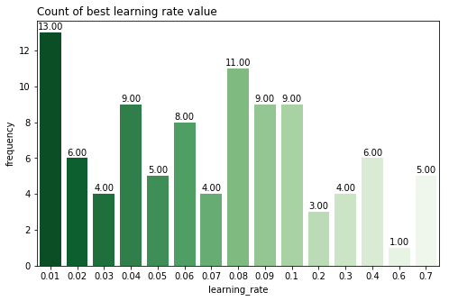

```python
plt.figure(figsize=(8,5))

best_param_freq = sns.countplot(best_learning_values['param_value'], palette='Greens_r')

for p in best_param_freq.patches:
    best_param_freq.annotate(format(p.get_height(), '.2f'), (p.get_x() + p.get_width() / 2., p.get_height()),
                             ha = 'center', va = 'center', xytext = (0, 6), textcoords = 'offset points')

plt.ylabel('frequency')
plt.xlabel('learning_rate')
plt.title('Count of best learning rate value', loc='left')
```

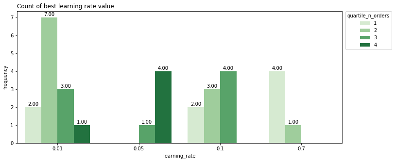

```python
plt.figure(figsize=(12,5))

best_param_freq = sns.countplot(best_learning_values[best_learning_values.param_value.isin([0.01, 0.05, 0.1, 0.7])]['param_value'],
                                palette='Greens',
                                hue=best_learning_values[best_learning_values.param_value.isin([0.01, 0.05, 0.1, 0.7])]['quartile_n_orders'])

for p in best_param_freq.patches:
    best_param_freq.annotate(format(p.get_height(), '.2f'), (p.get_x() + p.get_width() / 2., p.get_height()),
                             ha = 'center', va = 'center', xytext = (0, 6), textcoords = 'offset points')

plt.ylabel('frequency')
plt.xlabel('learning_rate')
# plt.legend(loc='upper center', title='quartile_n_orders')
plt.legend(loc='upper left', title='quartile_n_orders', bbox_to_anchor=(1.01, 1), borderaxespad=0.)
plt.title('Count of best learning rate value', loc='left')
```

```python
# plt.figure(figsize=(12,5))

# best_param_freq = sns.countplot(best_learning_values[best_learning_values.param_value.isin([0.01, 0.05, 0.1, 0.7])]['quartile_n_orders'],
#                                 palette='Greens',
#                                 hue=best_learning_values[best_learning_values.param_value.isin([0.01, 0.05, 0.1, 0.7])]['param_value'])

# for p in best_param_freq.patches:
#     best_param_freq.annotate(format(p.get_height(), '.2f'), (p.get_x() + p.get_width() / 2., p.get_height()),
#                              ha = 'center', va = 'center', xytext = (0, 6), textcoords = 'offset points')

# plt.ylabel('frequency')
# plt.xlabel('quartile_n_orders')
# plt.legend(loc='upper left', title='learning_rate', bbox_to_anchor=(1.01, 1), borderaxespad=0.)
# plt.title('Count of best learning rate value', loc='left')
```

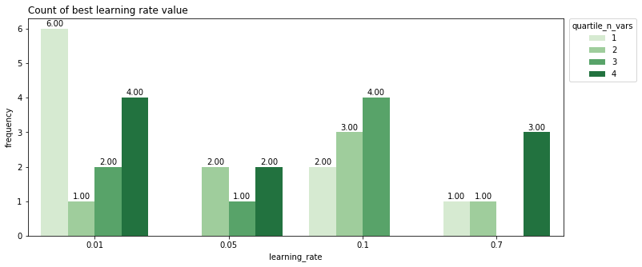

```python
plt.figure(figsize=(12,5))

best_param_freq = sns.countplot(best_learning_values[best_learning_values.param_value.isin([0.01, 0.05, 0.1, 0.7])]['param_value'],
                                palette='Greens',
                                hue=best_learning_values[best_learning_values.param_value.isin([0.01, 0.05, 0.1, 0.7])]['quartile_n_vars'])

for p in best_param_freq.patches:
    best_param_freq.annotate(format(p.get_height(), '.2f'), (p.get_x() + p.get_width() / 2., p.get_height()),
                             ha = 'center', va = 'center', xytext = (0, 6), textcoords = 'offset points')

plt.ylabel('frequency')
plt.xlabel('learning_rate')
plt.legend(loc='upper left', title='quartile_n_vars', bbox_to_anchor=(1.01, 1), borderaxespad=0.)
plt.title('Count of best learning rate value', loc='left')
```

```python
# plt.figure(figsize=(12,5))

# best_param_freq = sns.countplot(best_learning_values[best_learning_values.param_value.isin([0.01, 0.05, 0.1, 0.7])]['quartile_n_vars'],
#                                 palette='Greens',
#                                 hue=best_learning_values[best_learning_values.param_value.isin([0.01, 0.05, 0.1, 0.7])]['param_value'])

# for p in best_param_freq.patches:
#     best_param_freq.annotate(format(p.get_height(), '.2f'), (p.get_x() + p.get_width() / 2., p.get_height()),
#                              ha = 'center', va = 'center', xytext = (0, 6), textcoords = 'offset points')

# plt.ylabel('frequency')
# plt.xlabel('quartile_n_vars')
# plt.legend(loc='upper left', title='learning_rate', bbox_to_anchor=(1.01, 1), borderaxespad=0.)
# plt.title('Count of best learning rate value', loc='left')
```

#### Performance metric against dataset information

When exploring learning rate, the plot of performance metrics against numbers of observations and features produce the same patters as those obtained when exploring subsample.

#### Distribution of performance metric by best hyper-parameter value

```python
px.strip(data_frame=best_learning_values.sort_values('param_value'),
         x=best_learning_values.sort_values('param_value')['param_value'].apply(lambda x: 'v = ' + str(x)),
         y=best_learning_values.sort_values('param_value')['test_roc_auc'],
         hover_data=['store_id', 'param_value'],
         color_discrete_sequence=['#0b6fab'],
         width=900, height=500, title='Distribution of test_roc_auc by best learning rate value',
         labels={'y': 'test_roc_auc', 'x': ''})
```

[interactive chart not shown]

#### Correlation between performance metric of best hyper-parameter value and dataset information

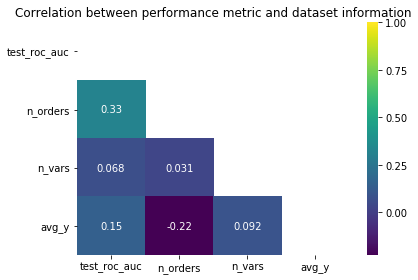

```python
# Generate a mask for the upper triangle
mask = np.triu(np.ones_like(best_learning_values[['test_roc_auc', 'n_orders', 'n_vars', 'avg_y']].corr(),
                            dtype=np.bool))

sns.heatmap(best_learning_values[['test_roc_auc', 'n_orders', 'n_vars', 'avg_y']].corr(),
            mask = mask, annot = True, cmap = 'viridis')
plt.title('Correlation between performance metric and dataset information')
plt.tight_layout()
```

```python
# Generate masks for the upper triangle:
mask001 = np.triu(np.ones_like(metrics_learning[metrics_learning.param_value==0.01][['test_roc_auc',
                                                                                 'n_orders', 'n_vars',
                                                                                 'avg_y']].corr(), dtype=np.bool))
mask07 = np.triu(np.ones_like(metrics_learning[metrics_learning.param_value==0.7][['test_roc_auc',
                                                                                 'n_orders', 'n_vars',
                                                                                 'avg_y']].corr(), dtype=np.bool))
```

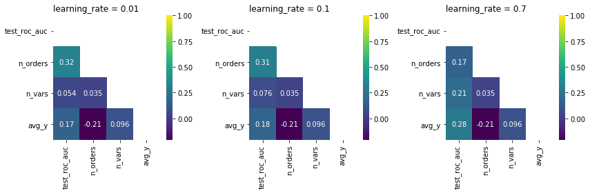

```python
fig, axs = plt.subplots(nrows=1, ncols=3, figsize=(12,4))

corr_matrices = sns.heatmap(metrics_learning[metrics_learning.param_value==0.01][['test_roc_auc', 'n_orders',
                                                                 'n_vars', 'avg_y']].corr(),
                            mask = mask001, annot = True, cmap = 'viridis', ax=axs[0])
sns.heatmap(metrics_learning[metrics_learning.param_value==0.1][['test_roc_auc', 'n_orders',
                                                                 'n_vars', 'avg_y']].corr(),
            mask = mask07, annot = True, cmap = 'viridis', ax=axs[1])
sns.heatmap(metrics_learning[metrics_learning.param_value==0.7][['test_roc_auc', 'n_orders',
                                                                 'n_vars', 'avg_y']].corr(),
            mask = mask07, annot = True, cmap = 'viridis', ax=axs[2])

axs[0].set_title('learning_rate = 0.01', loc='left')
axs[1].set_title('learning_rate = 0.1', loc='left')
axs[2].set_title('learning_rate = 0.7', loc='left')

plt.tight_layout()
```

## Number of estimators

Main findings are listed below:

- Very similar results across different values for a given set of remaining hyper-parameters.
- Moderate values of $n\_estimators$ were prone to perform better.
- Large values of $n\_estimators$ rarely were among the best hyper-parameter value.

### Processing data

#### Performance metrics

```python
# Assessing missing hyper-parameter values:
for s in tun_n_estimators['005'].keys():
    for m in ['test_roc_auc', 'test_prec_avg', 'test_pr_auc', 'test_deviance', 'test_brier_score']:
        if len(tun_n_estimators['005'][s][m].keys()) != 9:
            print('Missing hyper-parameter value for store ' + str(s) + ' and metric ' + m + '!')
```

```python
# Collecting reference data:
param_value = []
stores = []

# Loop over datasets:
for s in tun_n_estimators['005'].keys():
    # Loop over hyper-parameter values:
    for v in tun_n_estimators['005'][s]['test_roc_auc'].keys():
        param_value.append(float(v))
        stores.append(int(s))

metrics_n_estimators = pd.DataFrame(data=param_value, columns=['param_value'], index=stores)

# Collecting performance metrics:
for m in ['test_roc_auc', 'test_prec_avg', 'test_pr_auc', 'test_deviance', 'test_brier_score']:
    stores = []
    param_value = []
    ref = []

    # Loop over datasets:
    for s in tun_n_estimators['005'].keys():
        # Loop over hyper-parameter values:
        for v in tun_n_estimators['005'][s][m].keys():
            stores.append(int(s))
            ref.append(float(tun_n_estimators['005'][s][m][v]))

    metrics_n_estimators = pd.concat([metrics_n_estimators, pd.DataFrame(data={m: ref},
                                                                   index=stores)], axis=1)

metrics_n_estimators.index.name = 'store_id'
metrics_n_estimators.reset_index(inplace=True, drop=False)
metrics_n_estimators.param_value = metrics_n_estimators.param_value.apply(lambda x: x if np.isnan(x) else int(x))
print('\033[1mShape of metrics_n_estimators:\033[0m ' + str(metrics_n_estimators.shape) + '.')
metrics_n_estimators.head()
```

```
Shape of metrics_n_estimators: (900, 7).
```

|  | store_id | param_value | test_roc_auc | test_prec_avg | test_pr_auc | test_deviance | test_brier_score |
| --- | --- | --- | --- | --- | --- | --- | --- |
| 0 | 11729 | 100 | 0.801450 | 0.165249 | 0.157897 | 885.405667 | 0.041386 |
| 1 | 11729 | 250 | 0.771918 | 0.140431 | 0.131739 | 885.743592 | 0.044329 |
| 2 | 11729 | 500 | 0.772637 | 0.180357 | 0.173761 | 886.097185 | 0.041737 |
| 3 | 11729 | 750 | 0.749840 | 0.195791 | 0.191797 | 886.435896 | 0.042187 |
| 4 | 11729 | 1000 | 0.739582 | 0.178299 | 0.173366 | 886.065753 | 0.045934 |

### Statistics by hyper-parameter value

#### Basic statistics for each performance metric

```python
# Test ROC-AUC:
metrics_n_estimators.groupby('param_value').describe()[['test_roc_auc']].sort_values(('test_roc_auc','mean'),
                                                                                  ascending=False)
```

| param_value | test_roc_auc count | test_roc_auc mean | test_roc_auc std | test_roc_auc min | test_roc_auc 25% | test_roc_auc 50% | test_roc_auc 75% | test_roc_auc max |
| --- | --- | --- | --- | --- | --- | --- | --- | --- |
| 500 | 97.0 | 0.829800 | 0.154018 | 0.342522 | 0.759968 | 0.885251 | 0.947343 | 0.987582 |
| 1500 | 97.0 | 0.827766 | 0.155183 | 0.342522 | 0.734115 | 0.890435 | 0.945894 | 0.987745 |
| 750 | 97.0 | 0.827545 | 0.157232 | 0.342522 | 0.749840 | 0.890548 | 0.948953 | 0.987558 |
| 1250 | 97.0 | 0.827459 | 0.155144 | 0.342522 | 0.737330 | 0.889709 | 0.947633 | 0.987768 |
| 2000 | 97.0 | 0.827296 | 0.154771 | 0.342522 | 0.734635 | 0.887308 | 0.943932 | 0.987488 |
| 250 | 97.0 | 0.827100 | 0.155285 | 0.342522 | 0.755859 | 0.887524 | 0.944605 | 0.988042 |
| 1000 | 97.0 | 0.826607 | 0.156512 | 0.342522 | 0.739582 | 0.890402 | 0.946538 | 0.994359 |
| 1750 | 97.0 | 0.824530 | 0.157618 | 0.342522 | 0.732552 | 0.888081 | 0.945933 | 0.987605 |
| 100 | 97.0 | 0.820743 | 0.150249 | 0.342522 | 0.735476 | 0.869646 | 0.936787 | 0.978565 |

```python
# Test average precision score:
metrics_n_estimators.groupby('param_value').describe()[['test_prec_avg']].sort_values(('test_prec_avg','mean'),
                                                                                   ascending=False)
```

| param_value | test_prec_avg count | test_prec_avg mean | test_prec_avg std | test_prec_avg min | test_prec_avg 25% | test_prec_avg 50% | test_prec_avg 75% | test_prec_avg max |
| --- | --- | --- | --- | --- | --- | --- | --- | --- |
| 1500 | 97.0 | 0.418514 | 0.268164 | 0.000960 | 0.217415 | 0.436735 | 0.632634 | 0.951868 |
| 500 | 97.0 | 0.416903 | 0.267921 | 0.000956 | 0.194097 | 0.404169 | 0.620772 | 0.952257 |
| 1750 | 97.0 | 0.416144 | 0.271367 | 0.000960 | 0.183693 | 0.436735 | 0.633297 | 0.951645 |
| 1000 | 97.0 | 0.415830 | 0.271904 | 0.000960 | 0.179917 | 0.447790 | 0.608965 | 0.952926 |
| 750 | 97.0 | 0.415493 | 0.271327 | 0.000956 | 0.195791 | 0.421991 | 0.607136 | 0.954189 |
| 2000 | 97.0 | 0.415000 | 0.267964 | 0.000956 | 0.205671 | 0.436735 | 0.621236 | 0.950484 |
| 1250 | 97.0 | 0.413486 | 0.270378 | 0.000956 | 0.209601 | 0.412862 | 0.616056 | 0.952586 |
| 250 | 97.0 | 0.412703 | 0.269847 | 0.000955 | 0.180196 | 0.404551 | 0.645144 | 0.950033 |
| 100 | 97.0 | 0.398807 | 0.262234 | 0.000955 | 0.175142 | 0.371582 | 0.606914 | 0.938444 |

```python
# Test Brier score:
metrics_n_estimators.groupby('param_value').describe()[['test_brier_score']].sort_values(('test_brier_score',
                                                                                          'mean'),
                                                                                      ascending=True)
```

| param_value | test_brier_score count | test_brier_score mean | test_brier_score std | test_brier_score min | test_brier_score 25% | test_brier_score 50% | test_brier_score 75% | test_brier_score max |
| --- | --- | --- | --- | --- | --- | --- | --- | --- |
| 250 | 97.0 | 0.033402 | 0.036566 | 0.001986 | 0.010507 | 0.017989 | 0.039544 | 0.214301 |
| 100 | 97.0 | 0.034235 | 0.038671 | 0.001986 | 0.010902 | 0.018413 | 0.041386 | 0.220711 |
| 500 | 97.0 | 0.035678 | 0.042410 | 0.001986 | 0.010745 | 0.019018 | 0.039515 | 0.224004 |
| 750 | 97.0 | 0.035756 | 0.042796 | 0.001986 | 0.010051 | 0.019100 | 0.039533 | 0.244093 |
| 1250 | 97.0 | 0.036437 | 0.042925 | 0.001986 | 0.010723 | 0.019099 | 0.042245 | 0.245623 |
| 1000 | 97.0 | 0.036851 | 0.044559 | 0.001986 | 0.010861 | 0.018987 | 0.039517 | 0.242675 |
| 1750 | 97.0 | 0.037360 | 0.044541 | 0.001986 | 0.010660 | 0.018545 | 0.043360 | 0.246554 |
| 1500 | 97.0 | 0.037628 | 0.045930 | 0.001986 | 0.010622 | 0.018489 | 0.042427 | 0.244613 |
| 2000 | 97.0 | 0.038011 | 0.047029 | 0.001986 | 0.010393 | 0.018520 | 0.044183 | 0.244061 |

```python
# Test binomial deviance:
metrics_n_estimators.groupby('param_value').describe()[['test_deviance']].sort_values(('test_deviance','mean'),
                                                                                   ascending=True)
```

| param_value | test_deviance count | test_deviance mean | test_deviance std | test_deviance min | test_deviance 25% | test_deviance 50% | test_deviance 75% | test_deviance max |
| --- | --- | --- | --- | --- | --- | --- | --- | --- |
| 750 | 97.0 | 2427.744026 | 3870.582599 | 53.450128 | 345.143519 | 949.505953 | 2685.095464 | 22106.981012 |
| 1250 | 97.0 | 2427.873119 | 3870.637555 | 53.239442 | 345.438257 | 951.292076 | 2695.459149 | 22107.070287 |
| 250 | 97.0 | 2428.018609 | 3871.721799 | 53.344754 | 343.885114 | 949.242762 | 2697.410263 | 22107.917471 |
| 500 | 97.0 | 2428.085533 | 3870.523374 | 53.540951 | 344.812311 | 948.907512 | 2689.600558 | 22106.303690 |
| 1000 | 97.0 | 2428.247280 | 3870.311054 | 53.388970 | 345.243934 | 950.717060 | 2689.041596 | 22106.136324 |
| 1750 | 97.0 | 2428.392962 | 3870.546509 | 53.447200 | 345.198538 | 951.791724 | 2701.880355 | 22106.648320 |
| 1500 | 97.0 | 2428.523555 | 3870.334408 | 53.496438 | 345.351901 | 952.168705 | 2702.105783 | 22106.325352 |
| 2000 | 97.0 | 2429.027810 | 3870.648523 | 53.500470 | 345.194551 | 952.198819 | 2708.324268 | 22107.167220 |
| 100 | 97.0 | 2430.753893 | 3873.716516 | 53.437669 | 343.369418 | 950.084749 | 2720.073728 | 22110.606157 |

#### Averages of performance metrics by hyper-parameter value

```python
metrics_n_estimators.groupby('param_value').mean().sort_values('test_roc_auc', ascending=False).drop('store_id',
                                                                                                  axis=1)
```

| param_value | test_roc_auc | test_prec_avg | test_pr_auc | test_deviance | test_brier_score |
| --- | --- | --- | --- | --- | --- |
| 500 | 0.829800 | 0.416903 | 0.425950 | 2428.085533 | 0.035678 |
| 1500 | 0.827766 | 0.418514 | 0.428398 | 2428.523555 | 0.037628 |
| 750 | 0.827545 | 0.415493 | 0.426481 | 2427.744026 | 0.035756 |
| 1250 | 0.827459 | 0.413486 | 0.422271 | 2427.873119 | 0.036437 |
| 2000 | 0.827296 | 0.415000 | 0.424359 | 2429.027810 | 0.038011 |
| 250 | 0.827100 | 0.412703 | 0.422142 | 2428.018609 | 0.033402 |
| 1000 | 0.826607 | 0.415830 | 0.420969 | 2428.247280 | 0.036851 |
| 1750 | 0.824530 | 0.416144 | 0.426932 | 2428.392962 | 0.037360 |
| 100 | 0.820743 | 0.398807 | 0.412879 | 2430.753893 | 0.034235 |

#### Frequency of best hyper-parameter values

```python
best_n_estimators_values = metrics_n_estimators.groupby('store_id').idxmax()['test_roc_auc'].values
print('\033[1mRelative frequency of highest performance metric by hyper-parameter value:\033[0m')
print(metrics_n_estimators.reindex(best_n_estimators_values).param_value.value_counts()/len(best_n_estimators_values))
```

```
Relative frequency of highest performance metric by hyper-parameter value:
250.0     0.20
100.0     0.20
1500.0    0.11
500.0     0.11
1000.0    0.09
750.0     0.09
2000.0    0.06
1250.0    0.06
1750.0    0.05
Name: param_value, dtype: float64
```

#### Average performance metric by best hyper-parameter value

```python
# Dataframe with best hyper-parameter value by dataset:
best_n_estimators_values = metrics_n_estimators.reindex(best_n_estimators_values)[['store_id', 'param_value', 'test_roc_auc']]
best_n_estimators_values = best_n_estimators_values.merge(data_info, on='store_id', how='inner')
print('\033[1mShape of best_n_estimators_values:\033[0m ' + str(best_n_estimators_values.shape) + '.')
best_n_estimators_values.head()
```

```
Shape of best_n_estimators_values: (97, 6).
```

|  | store_id | param_value | test_roc_auc | n_orders | n_vars | avg_y |
| --- | --- | --- | --- | --- | --- | --- |
| 0 | 720.0 | 500.0 | 0.840988 | 4028 | 1858 | 0.011668 |
| 1 | 1098.0 | 1500.0 | 0.971345 | 19152 | 4026 | 0.023705 |
| 2 | 1181.0 | 750.0 | 0.982147 | 3467 | 2698 | 0.033458 |
| 3 | 1210.0 | 100.0 | 0.500000 | 4028 | 2101 | 0.001490 |
| 4 | 1241.0 | 1750.0 | 0.858173 | 206 | 3791 | 0.320388 |

```python
best_n_estimators_values.groupby('param_value').mean().sort_values('test_roc_auc', ascending=False)[['test_roc_auc']]
```

| param_value | test_roc_auc |
| --- | --- |
| 750.0 | 0.921714 |
| 1500.0 | 0.920224 |
| 1250.0 | 0.911071 |
| 2000.0 | 0.882975 |
| 1750.0 | 0.864174 |
| 500.0 | 0.857464 |
| 250.0 | 0.835418 |
| 1000.0 | 0.820608 |
| 100.0 | 0.708717 |

### Describing hyper-parameter values

#### Average numbers of observations and features by best hyper-parameter value

```python
best_n_estimators_values.groupby('param_value').mean()[['n_orders']].sort_values('n_orders', ascending=False)
```

| param_value | n_orders |
| --- | --- |
| 1000.0 | 12530.111111 |
| 500.0 | 12116.545455 |
| 1500.0 | 11050.272727 |
| 750.0 | 10621.111111 |
| 2000.0 | 6896.500000 |
| 1750.0 | 5938.600000 |
| 250.0 | 4339.850000 |
| 1250.0 | 2864.166667 |
| 100.0 | 2473.000000 |

```python
best_n_estimators_values.groupby('param_value').mean()[['n_vars']].sort_values('n_vars', ascending=False)
```

| param_value | n_vars |
| --- | --- |
| 1750.0 | 3015.800000 |
| 1500.0 | 2458.727273 |
| 750.0 | 2448.333333 |
| 500.0 | 2384.636364 |
| 1000.0 | 2353.777778 |
| 2000.0 | 2345.833333 |
| 1250.0 | 2333.666667 |
| 250.0 | 2283.450000 |
| 100.0 | 2203.800000 |

#### Average of response variable by best hyper-parameter value

```python
best_n_estimators_values.groupby('param_value').mean()[['avg_y']].sort_values('avg_y', ascending=False)
```

| param_value | avg_y |
| --- | --- |
| 1750.0 | 0.092578 |
| 250.0 | 0.072071 |
| 1250.0 | 0.065581 |
| 2000.0 | 0.049240 |
| 500.0 | 0.047090 |
| 100.0 | 0.040656 |
| 750.0 | 0.035418 |
| 1500.0 | 0.029324 |
| 1000.0 | 0.025724 |

#### Most frequent best hyper-parameter values by quartile of number of observations

```python
best_n_estimators_values['quartile_n_orders'] = percentile_cut(best_n_estimators_values.n_orders, p=4)['percentile']

print('\033[1mFrequency of best hyper-parameter values by quartile of number of observations:\033[0m')
for q in range(1,5):
    print('\033[1mNumber of orders in ' +
          str(np.sort(np.unique(percentile_cut(best_n_estimators_values.n_orders, p=4)['interval']))[q-1]) +
          ' (quartile ' + str(q) + ')\033[0m:')
    print(best_n_estimators_values[best_n_estimators_values.quartile_n_orders==q].param_value.value_counts())
    print('\n')
```

```
Frequency of best hyper-parameter values by quartile of number of observations:
Number of orders in (156.998, 999.0] (quartile 1):
100.0     8
250.0     7
1750.0    3
2000.0    2
1500.0    1
500.0     1
750.0     1
1000.0    1
1250.0    1
Name: param_value, dtype: int64


Number of orders in (999.0, 2812.0] (quartile 2):
250.0     8
100.0     6
1250.0    4
1000.0    2
2000.0    2
1500.0    1
500.0     1
Name: param_value, dtype: int64


Number of orders in (2812.0, 7946.0] (quartile 3):
100.0     5
250.0     4
1500.0    4
750.0     4
500.0     3
1000.0    2
1250.0    1
2000.0    1
Name: param_value, dtype: int64


Number of orders in (7946.0, 63963.001] (quartile 4):
500.0     6
1500.0    5
750.0     4
1000.0    4
1750.0    2
100.0     1
250.0     1
2000.0    1
Name: param_value, dtype: int64
```

#### Most frequent best hyper-parameter values by quartile of number of features

```python
best_n_estimators_values['quartile_n_vars'] = percentile_cut(best_n_estimators_values.n_vars, p=4)['percentile']

print('\033[1mFrequency of best hyper-parameter values by quartile of number of features:\033[0m')
for q in range(1,5):
    print('\033[1mNumber of vars in ' +
          str(np.sort(np.unique(percentile_cut(best_n_estimators_values.n_vars, p=4)['interval']))[q-1]) +
          ' (quartile ' + str(q) + ')\033[0m:')
    print(best_n_estimators_values[best_n_estimators_values.quartile_n_vars==q].param_value.value_counts())
    print('\n')
```

```
Frequency of best hyper-parameter values by quartile of number of features:
Number of vars in (1415.998, 2069.0] (quartile 1):
100.0     8
250.0     6
1000.0    3
750.0     2
1500.0    2
500.0     2
1250.0    1
2000.0    1
Name: param_value, dtype: int64


Number of vars in (2069.0, 2321.0] (quartile 2):
100.0     7
250.0     5
1500.0    4
500.0     2
750.0     2
2000.0    2
1250.0    2
Name: param_value, dtype: int64


Number of vars in (2321.0, 2534.0] (quartile 3):
250.0     5
500.0     4
1000.0    3
1500.0    3
750.0     3
1250.0    2
2000.0    2
1750.0    1
100.0     1
Name: param_value, dtype: int64


Number of vars in (2534.0, 4026.001] (quartile 4):
100.0     4
250.0     4
1750.0    4
500.0     3
1000.0    3
750.0     2
1500.0    2
2000.0    1
1250.0    1
Name: param_value, dtype: int64
```

#### Correlation between performance metric of best hyper-parameter value and dataset information

```python
best_n_estimators_values[['test_roc_auc', 'n_orders', 'n_vars', 'avg_y']].corr()[['test_roc_auc']]
```

|  | test_roc_auc |
| --- | --- |
| test_roc_auc | 1.000000 |
| n_orders | 0.295579 |
| n_vars | 0.041541 |
| avg_y | 0.165359 |

#### Correlation between performance metric and dataset information by hyper-parameter value

```python
metrics_n_estimators = metrics_n_estimators.merge(data_info, on='store_id', how='left')
print('\033[1mShape of metrics_n_estimators:\033[0m ' + str(metrics_n_estimators.shape) + '.')
metrics_n_estimators.head()
```

```
Shape of metrics_n_estimators: (900, 10).
```

|  | store_id | param_value | test_roc_auc | test_prec_avg | test_pr_auc | test_deviance | test_brier_score | n_orders | n_vars | avg_y |
| --- | --- | --- | --- | --- | --- | --- | --- | --- | --- | --- |
| 0 | 11729 | 100 | 0.801450 | 0.165249 | 0.157897 | 885.405667 | 0.041386 | 2570 | 1596 | 0.037354 |
| 1 | 11729 | 250 | 0.771918 | 0.140431 | 0.131739 | 885.743592 | 0.044329 | 2570 | 1596 | 0.037354 |
| 2 | 11729 | 500 | 0.772637 | 0.180357 | 0.173761 | 886.097185 | 0.041737 | 2570 | 1596 | 0.037354 |
| 3 | 11729 | 750 | 0.749840 | 0.195791 | 0.191797 | 886.435896 | 0.042187 | 2570 | 1596 | 0.037354 |
| 4 | 11729 | 1000 | 0.739582 | 0.178299 | 0.173366 | 886.065753 | 0.045934 | 2570 | 1596 | 0.037354 |

```python
for v in metrics_n_estimators.param_value.unique():
    print('\033[1mn_estimators = ' + str(v) + '\033[0m')
    print(metrics_n_estimators[metrics_n_estimators.param_value==v][['test_roc_auc',
                                                               'n_orders', 'n_vars',
                                                               'avg_y']].corr()[['test_roc_auc']])
    print('\n')
```

```
n_estimators = 100
              test_roc_auc
test_roc_auc      1.000000
n_orders          0.298490
n_vars            0.048438
avg_y             0.189709


n_estimators = 250
              test_roc_auc
test_roc_auc      1.000000
n_orders          0.301489
n_vars            0.048528
avg_y             0.177903


n_estimators = 500
              test_roc_auc
test_roc_auc      1.000000
n_orders          0.305460
n_vars            0.054179
avg_y             0.161834


n_estimators = 750
              test_roc_auc
test_roc_auc      1.000000
n_orders          0.304751
n_vars            0.056807
avg_y             0.160490


n_estimators = 1000
              test_roc_auc
test_roc_auc      1.000000
n_orders          0.309234
n_vars            0.061954
avg_y             0.160907


```

[output cut: 15 more lines]

```

n_estimators = 1750
              test_roc_auc
test_roc_auc      1.000000
n_orders          0.315503
n_vars            0.069494
avg_y             0.162369


n_estimators = 2000
              test_roc_auc
test_roc_auc      1.000000
n_orders          0.309337
n_vars            0.070663
avg_y             0.154681
```

### Data visualization

#### Average of performance metric by hyper-parameter value

```python
# Select a performance metric:
metric = 'test_roc_auc'

fig=px.scatter(x=metrics_n_estimators['param_value'].apply(lambda x: 'M = ' + str(x)).unique(),
               y=metrics_n_estimators.groupby('param_value').mean()[metric],
               error_y=np.array(metrics_n_estimators.groupby('param_value').std()['test_roc_auc']),
               color_discrete_sequence=['#0b6fab'],
               width=900, height=500,
               title='Average of ' + metric + ' by number of estimators',
               labels={'y': metric, 'x': ''})

fig.add_trace(
    go.Scatter(
        x=metrics_n_estimators['param_value'].apply(lambda x: 'M = ' + str(x)).unique(),
        y=metrics_n_estimators.groupby('param_value').mean()[metric],
        line = dict(color='#0b6fab', width=2, dash='dash'),
        name='avg_' + metric
              )
)
```

[interactive chart not shown]

#### Boxplot of performance metric by hyper-parameter value

```python
# Select a performance metric:
metric = 'test_roc_auc'

px.box(data_frame=metrics_n_estimators,
       x=metrics_n_estimators['param_value'].apply(lambda x: 'M = ' + str(x)),
       y=metric, hover_data=['store_id'],
       color_discrete_sequence=['#0b6fab'],
       width=900, height=500,
       labels={'x': ' '},
       title='Distribution of ' + metric + ' by number of estimators.')
```

[interactive chart not shown]

#### Frequency of best hyper-parameter values

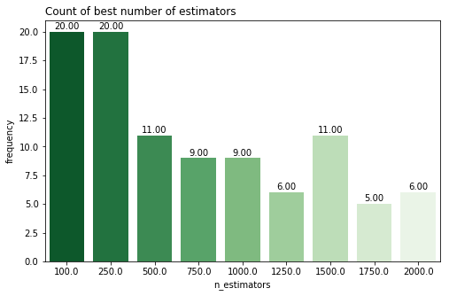

```python
plt.figure(figsize=(8,5))

best_param_freq = sns.countplot(best_n_estimators_values['param_value'], palette='Greens_r')

for p in best_param_freq.patches:
    best_param_freq.annotate(format(p.get_height(), '.2f'), (p.get_x() + p.get_width() / 2., p.get_height()),
                             ha = 'center', va = 'center', xytext = (0, 6), textcoords = 'offset points')

plt.ylabel('frequency')
plt.xlabel('n_estimators')
plt.title('Count of best number of estimators', loc='left')
```

```python
# plt.figure(figsize=(12,5))

# best_param_freq = sns.countplot(best_n_estimators_values[best_n_estimators_values.param_value.isin([100,500,1000,2000])]['param_value'], palette='Greens',
#                                 hue=best_n_estimators_values[best_n_estimators_values.param_value.isin([100,500,1000,2000])]['quartile_n_orders'])

# for p in best_param_freq.patches:
#     best_param_freq.annotate(format(p.get_height(), '.2f'), (p.get_x() + p.get_width() / 2., p.get_height()),
#                              ha = 'center', va = 'center', xytext = (0, 6), textcoords = 'offset points')

# plt.ylabel('frequency')
# plt.xlabel('n_estimators')
# # plt.legend(loc='upper center', title='quartile_n_orders')
# plt.legend(loc='upper left', title='quartile_n_orders', bbox_to_anchor=(1.01, 1), borderaxespad=0.)
# plt.title('Count of best number of estimators', loc='left')
```

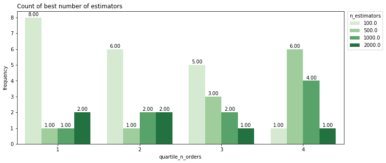

```python
plt.figure(figsize=(12,5))

best_param_freq = sns.countplot(best_n_estimators_values[best_n_estimators_values.param_value.isin([100,500,1000,2000])]['quartile_n_orders'], palette='Greens',
                                hue=best_n_estimators_values[best_n_estimators_values.param_value.isin([100,500,1000,2000])]['param_value'])

for p in best_param_freq.patches:
    best_param_freq.annotate(format(p.get_height(), '.2f'), (p.get_x() + p.get_width() / 2., p.get_height()),
                             ha = 'center', va = 'center', xytext = (0, 6), textcoords = 'offset points')

plt.ylabel('frequency')
plt.xlabel('quartile_n_orders')
# plt.legend(loc='upper center', title='quartile_n_orders')
plt.legend(loc='upper left', title='n_estimators', bbox_to_anchor=(1.01, 1), borderaxespad=0.)
plt.title('Count of best number of estimators', loc='left')
```

```python
# plt.figure(figsize=(12,5))

# best_param_freq = sns.countplot(best_n_estimators_values[best_n_estimators_values.param_value.isin([100,500,1000,2000])]['param_value'], palette='Greens',
#                                 hue=best_n_estimators_values[best_n_estimators_values.param_value.isin([100,500,1000,2000])]['quartile_n_vars'])

# for p in best_param_freq.patches:
#     best_param_freq.annotate(format(p.get_height(), '.2f'), (p.get_x() + p.get_width() / 2., p.get_height()),
#                              ha = 'center', va = 'center', xytext = (0, 6), textcoords = 'offset points')

# plt.ylabel('frequency')
# plt.xlabel('n_estimators')
# plt.legend(loc='upper left', title='quartile_n_vars', bbox_to_anchor=(1.01, 1), borderaxespad=0.)
# plt.title('Count of best number of estimators', loc='left')
```

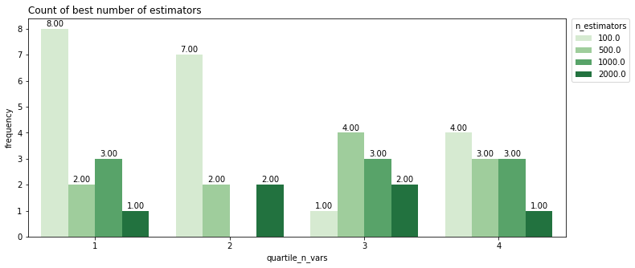

```python
plt.figure(figsize=(12,5))

best_param_freq = sns.countplot(best_n_estimators_values[best_n_estimators_values.param_value.isin([100,500,1000,2000])]['quartile_n_vars'], palette='Greens',
                                hue=best_n_estimators_values[best_n_estimators_values.param_value.isin([100,500,1000,2000])]['param_value'])

for p in best_param_freq.patches:
    best_param_freq.annotate(format(p.get_height(), '.2f'), (p.get_x() + p.get_width() / 2., p.get_height()),
                             ha = 'center', va = 'center', xytext = (0, 6), textcoords = 'offset points')

plt.ylabel('frequency')
plt.xlabel('quartile_n_vars')
plt.legend(loc='upper left', title='n_estimators', bbox_to_anchor=(1.01, 1), borderaxespad=0.)
plt.title('Count of best number of estimators', loc='left')
```

#### Performance metric against dataset information

When exploring number of estimators, the plot of performance metrics against numbers of observations and features produce the same patters as those obtained when exploring subsample.

#### Distribution of performance metric by best hyper-parameter value

```python
px.strip(data_frame=best_n_estimators_values.sort_values('param_value'),
         x=best_n_estimators_values.sort_values('param_value')['param_value'].apply(lambda x: 'M = ' + str(x)),
         y=best_n_estimators_values.sort_values('param_value')['test_roc_auc'],
         hover_data=['store_id', 'param_value'],
         color_discrete_sequence=['#0b6fab'],
         width=900, height=500, title='Distribution of test_roc_auc by best number of estimators',
         labels={'y': 'test_roc_auc', 'x': ''})
```

[interactive chart not shown]

#### Correlation between performance metric of best hyper-parameter value and dataset information

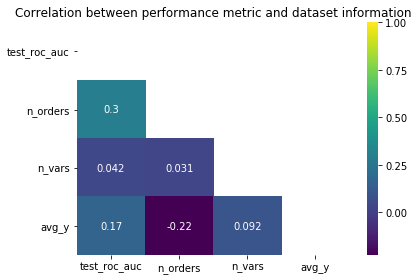

```python
# Generate a mask for the upper triangle:
mask = np.triu(np.ones_like(best_n_estimators_values[['test_roc_auc', 'n_orders', 'n_vars', 'avg_y']].corr(),
                            dtype=np.bool))

sns.heatmap(best_n_estimators_values[['test_roc_auc', 'n_orders', 'n_vars', 'avg_y']].corr(),
            mask = mask, annot = True, cmap = 'viridis')
plt.title('Correlation between performance metric and dataset information')
plt.tight_layout()
```

## Appendix: grid search with ROC-AUC and average precision score

Definition of hyper-parameters $\theta^L$ for statistical learning methods is usually based on the estimation of errors or performance metrics through validation procedures, after which the best hyper-parameter vector $\theta^{L*}$ among a grid of different alternatives is selected from optimizing the validated error or performance metric.  
When this methodology is referenced by a performance metric instead of error measures, a choice among different performance metrics should be previously done. When the statistical learning problem is a classification one, the choice is especially blurred, since there are several different possibilities. Considering the simplest context of a binary classification, ROC-AUC, precision-recall AUC, and average precision score are the main performance metrics to be considered.  
Given the high correlation between precision-recall AUC and average precision score, and then defining the last one as a representative of both, which of the following should be picked: *ROC-AUC or average precision score*?  
After estimating a set of models, for a given collection of datasets and one for each learning method explored so far (logistic regression and GBM), their outcomes will be used here to provide comparisons between the best hyper-parameter choice and the associated value of performance metric for those two alternatives, namely, ROC-AUC and average precision score.  
The objectives of this study are summarized as follows:

1. The first objective is to assess changes in the output of grid search as one uses ROC-AUC instead of average precision score as the performance metric of reference. This can be done either by measuring the frequency of divergences or by calculating statistics for the difference in best hyper-parameter values.
   - Logistic regression.
   - GBM.
2. When ROC-AUC and average precision score do diverge, even more important is to check the degree to which vary along the alternatives each performance metric itself. This indicates if the divergence in best hyper-parameters choice between the two criteria is meaningful, or instead if both options are closely related. The smaller the expected difference, the more interchangeable are the alternatives.
   - Logistic regression.
   - GBM.
3. Lastly, a last goal is to assess how much the estimated generalization capacity of the models varies between those two options of best hyper-parameters choice, using for this the K-folds CV for implementing grid search and later a train-test estimation in order to calculate performance metrics for final comparison. The results from these tests, however, will be presented and discussed in another notebook.

It is crucial to clarify that there is no desired answers for the questions that arise from these experiments. This because, even if ROC-AUC and average precision score diverge, the definition of which metric is the most appropriate depends ultimately on theoretical discussions to be explored in the future, even though this is also briefly tested here. Note also that the tests whose results are presented below have limitations toward their generalization. From beyond specificities in data generation processes, only two learning methods are explored, and only one hyper-parameter per method is defined through grid search, while GBM, for instance, has at least three further relevant hyper-parameters.

#### Main conclusions

**Note:** comparing best hyper-parameters from a learning method $L$ from a dataset $s$ means checking $\hat{\theta}_{roc}^{L,s}$ against $\hat{\theta}_{avg-prec}^{L,s}$, where the first is chosen from grid search based on ROC-AUC and the second follows from grid search using average precision score.  
**Note:** similarly, comparing performance metrics opposes ROC-AUC$_{roc}$ to ROC-AUC$_{avg-prec}$, and $Avg\_prec\_score_{roc}$ to $Avg\_prec\_score_{avg-prec}$, where subscripts $roc$ and $avg-prec$ indicate metrics of performance associated with best hyper-parameters that follow ROC-AUC and average precision score, respectively.

1. Correlation among performance metrics (either using outcomes from logistic regression or GBM).
   - There are high correlations between ROC-AUC and different performance metrics, both precision scores (average precision score and precision-recall AUC - positive correlation) and cost functions (binomial deviance and Brier score - negative correlation). The correlation is particularly high with average precision score.
   - Correlation near 1 between average precision score and precision-recall AUC.
2. Logistic regression: grid search based on ROC-AUC only moderately diverges in choice of hyper-parameters when comparing to average precision score.
   - Comparing best hyper-parameters:
     - More than a half (55%) of datasets have the same hyper-parameter being chosen across both performance metrics.
     - Given those dataset with divergence in choice, half shows a difference near to 0.25.
     - On average, regularization parameter chosen by ROC-AUC was similar to that picked by average precision score among datasets with divergence in choice, and both was similar to average regularization parameter of datasets with equality in the choice.
     - Distribution of differences (for datasets with divergent choices) concentrates near zero, with only a few of datasets showing large difference in best hyper-parameter.
   - Comparing performance metrics:
     - Average difference in ROC-AUC of aroung 2 percentage points, but with a median of difference smaller than 1 p.p. Again, distribution of differences concentrating around zero, with only a few datasets having large differences.
     - Indeed, high differences in ROC-AUC tipically applying for datasets with ROC-AUC too smaller than those for datasets with equivalent best hyper-parameters.
     - The performance metric of average precision score has a pattern of larger differences.
3. GBM: grid search through ROC-AUC shows results quite divergent than those from grid search through average precision score.
   - Comparing best hyper-parameters:
     - Around a half of datasets (52%) show equal best hyper-parameters between two criteria for grid search.
     - Given datasets with divergent choices, there is a considerable difference in $max\_depth$: on average, a difference of 3.7 splits.
     - ROC-AUC tends to choose the production of larger trees (around 3.6 splits against 2.9 from average precision score).
     - Datasets with no divergence in choice between two criteria are prone to produce smaller trees (around 1.8 splits on average).
     - Highly sparse distribution of differences in $max\_depth$ between that chosen by ROC-AUC and that following average precision score.
   - Comparing performance metrics:
     - The difference in ROC-AUC for best hyper-parameter chosen by ROC-AUC and ROC-AUC for best hyper-parameter chosen by average precision score is not as big as what is suggested by the difference between the best hyper-parameters - 2.6 p.p. of average difference and a median of 1 p.p.
     - The same applies for differences between distinct average precision scores.

### Logistic regression

The outcomes from logistic regression model estimation follows from grid-search to define the regularization parameter $\lambda$ (denoted $C$ in sklearn library). The grid explored through train-test estimations has 14 different values for $\lambda$: $\{0.0001, 0.0003, 0.001, 0.003, 0.01, 0.03, 0.1, 0.25, 0.3, 0.5, 0.75, 1.0, 3.0, 10.0\}$. The estimations were performed using 100 different datasets whose response variable was binary.

#### Importing and processing data

```python
# Outcomes from logistic regression estimations:
with open('../Datasets/tun_C.json') as json_file:
    tun_C = json.load(json_file)
```

```python
# Dataframe for correlating different performance metrics:
stores = []
test_roc_auc = []
test_prec_avg = []
test_pr_auc = []
test_deviance_neg = []
test_brier_score_neg = []

# Loop over datasets:
for s in tun_C.keys():
    stores.append(int(s))

    # Best hyper-parameter (according with test ROC-AUC):
    roc_auc = list(tun_C[s]['test_roc_auc'].values())
    best_key = list(tun_C[s]['test_roc_auc'].keys())[roc_auc.index(max(roc_auc))]

    # Performance metrics associated with best hyper-parameter:
    test_roc_auc.append(tun_C[s]['test_roc_auc'][best_key])
    test_prec_avg.append(tun_C[s]['test_prec_avg'][best_key])
    test_pr_auc.append(tun_C[s]['test_pr_auc'][best_key])
    test_deviance_neg.append(-tun_C[s]['test_deviance'][best_key])
    test_brier_score_neg.append(-tun_C[s]['test_brier_score'][best_key])

# Dataframe with performance metrics by dataset:
metrics_LR = pd.DataFrame(data={
    'store_id': stores,
    'test_roc_auc': test_roc_auc,
    'test_prec_avg': test_prec_avg,
    'test_pr_auc': test_pr_auc,
    'test_deviance_neg': test_deviance_neg,
    'test_brier_score_neg': test_brier_score_neg
})

print('\033[1mShape of metrics_LR:\033[0m ' + str(metrics_LR.shape) + '.')
metrics_LR.head()
```

```
Shape of metrics_LR: (100, 6).
```

|  | store_id | test_roc_auc | test_prec_avg | test_pr_auc | test_deviance_neg | test_brier_score_neg |
| --- | --- | --- | --- | --- | --- | --- |
| 0 | 11729 | 0.860717 | 0.261281 | 0.255241 | -883.688819 | -0.036629 |
| 1 | 10311 | 0.759262 | 0.056166 | 0.042485 | -692.790592 | -0.011738 |
| 2 | 7988 | 0.675689 | 0.163174 | 0.155672 | -368.546870 | -0.072928 |
| 3 | 4736 | 0.992715 | 0.840471 | 0.834750 | -320.272547 | -0.016298 |
| 4 | 3481 | 0.789703 | 0.089113 | 0.076277 | -1515.658151 | -0.009110 |

```python
# Dataframe with best hyper-parameters and associated performance metrics:
stores = []
best_param_roc_auc = []
best_param_avg_prec = []
roc_auc_best_roc_auc = []
roc_auc_best_avg_prec = []
avg_prec_best_avg_prec = []
avg_prec_best_roc_auc = []

# Loop over datasets:
for s in tun_C.keys():
    stores.append(int(s))

    # Hyper-parameters and performance metrics:
    params = list(tun_C[s]['test_roc_auc'].keys())
    test_roc_auc = list(tun_C[s]['test_roc_auc'].values())
    test_prec_avg = list(tun_C[s]['test_prec_avg'].values())

    # Best hyper-parameters:
    best_param_roc_auc.append(float(params[test_roc_auc.index(max(test_roc_auc))]))
    best_param_avg_prec.append(float(params[test_prec_avg.index(max(test_prec_avg))]))

    # Performance metrics for best hyper-parameters:
    roc_auc_best_roc_auc.append(float(test_roc_auc[test_roc_auc.index(max(test_roc_auc))]))
    roc_auc_best_avg_prec.append(float(test_roc_auc[test_prec_avg.index(max(test_prec_avg))]))
    avg_prec_best_avg_prec.append(float(test_prec_avg[test_prec_avg.index(max(test_prec_avg))]))
    avg_prec_best_roc_auc.append(float(test_prec_avg[test_roc_auc.index(max(test_roc_auc))]))

# Dataframe with information of best hyper-parameters and associated performance metrics by dataset:
grid_search_comp_LR = pd.DataFrame(data={
    'store_id': stores,
    'best_param_roc_auc': best_param_roc_auc,
    'best_param_avg_prec': best_param_avg_prec,
    'roc_auc_best_roc_auc': roc_auc_best_roc_auc,
    'roc_auc_best_avg_prec': roc_auc_best_avg_prec,
    'avg_prec_best_avg_prec': avg_prec_best_avg_prec,
    'avg_prec_best_roc_auc': avg_prec_best_roc_auc
})

print('\033[1mShape of grid_search_comp_LR:\033[0m ' + str(grid_search_comp_LR.shape) + '.')
grid_search_comp_LR.head()
```

```
Shape of grid_search_comp_LR: (100, 7).
```

|  | store_id | best_param_roc_auc | best_param_avg_prec | roc_auc_best_roc_auc | roc_auc_best_avg_prec | avg_prec_best_avg_prec | avg_prec_best_roc_auc |
| --- | --- | --- | --- | --- | --- | --- | --- |
| 0 | 11729 | 0.1 | 0.1 | 0.860717 | 0.860717 | 0.261281 | 0.261281 |
| 1 | 10311 | 0.1 | 0.1 | 0.759262 | 0.759262 | 0.056166 | 0.056166 |
| 2 | 7988 | 0.1 | 0.1 | 0.675689 | 0.675689 | 0.163174 | 0.163174 |
| 3 | 4736 | 1.0 | 3.0 | 0.992715 | 0.991722 | 0.850960 | 0.840471 |
| 4 | 3481 | 0.3 | 10.0 | 0.789703 | 0.743769 | 0.209854 | 0.089113 |

```python
# Dataframe with datasets for which best hyper-parameters differ between ROC-AUC and average precision score:
diff_param_LR = grid_search_comp_LR[grid_search_comp_LR.best_param_roc_auc != grid_search_comp_LR.best_param_avg_prec]
diff_param_LR['abs_diff_best_param'] = np.abs(diff_param_LR.best_param_roc_auc - diff_param_LR.best_param_avg_prec)
diff_param_LR['abs_diff_roc_auc'] = np.abs(diff_param_LR.roc_auc_best_roc_auc - diff_param_LR.roc_auc_best_avg_prec)
diff_param_LR['abs_diff_avg_prec'] = np.abs(diff_param_LR.avg_prec_best_avg_prec - diff_param_LR.avg_prec_best_roc_auc)

print('\033[1mShape of diff_param_LR:\033[0m ' + str(diff_param_LR.shape) + '.')
diff_param_LR.sort_values('abs_diff_best_param', ascending=False).head(10)
```

```
Shape of diff_param_LR: (44, 10).
```

|  | store_id | best_param_roc_auc | best_param_avg_prec | roc_auc_best_roc_auc | roc_auc_best_avg_prec | avg_prec_best_avg_prec | avg_prec_best_roc_auc | abs_diff_best_param | abs_diff_roc_auc | abs_diff_avg_prec |
| --- | --- | --- | --- | --- | --- | --- | --- | --- | --- | --- |
| 71 | 8446 | 0.0001 | 10.00 | 0.500000 | 0.432122 | 0.001681 | 0.000955 | 9.9999 | 0.067878 | 0.000726 |
| 83 | 3146 | 10.0000 | 0.10 | 0.823101 | 0.719620 | 0.259247 | 0.092862 | 9.9000 | 0.103481 | 0.166385 |
| 91 | 1979 | 0.3000 | 10.00 | 0.813036 | 0.791748 | 0.048136 | 0.021521 | 9.7000 | 0.021288 | 0.026615 |
| 4 | 3481 | 0.3000 | 10.00 | 0.789703 | 0.743769 | 0.209854 | 0.089113 | 9.7000 | 0.045934 | 0.120741 |
| 55 | 5428 | 10.0000 | 0.75 | 0.963344 | 0.959472 | 0.619015 | 0.591090 | 9.2500 | 0.003872 | 0.027925 |
| 20 | 10268 | 1.0000 | 10.00 | 0.694892 | 0.610215 | 0.118871 | 0.090646 | 9.0000 | 0.084677 | 0.028225 |
| 57 | 5939 | 10.0000 | 3.00 | 0.971570 | 0.963899 | 0.466383 | 0.433333 | 7.0000 | 0.007671 | 0.033049 |
| 97 | 2782 | 0.3000 | 3.00 | 0.863650 | 0.831612 | 0.245908 | 0.189285 | 2.7000 | 0.032038 | 0.056623 |
| 3 | 4736 | 1.0000 | 3.00 | 0.992715 | 0.991722 | 0.850960 | 0.840471 | 2.0000 | 0.000993 | 0.010489 |
| 35 | 7849 | 1.0000 | 3.00 | 0.892595 | 0.889210 | 0.384869 | 0.368977 | 2.0000 | 0.003385 | 0.015892 |

#### Correlation between performance metrics

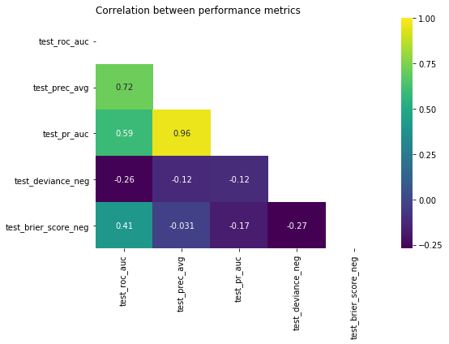

```python
# Generate a mask for the upper triangle:
mask = np.triu(np.ones_like(metrics_LR.drop('store_id', axis=1).corr(), dtype=np.bool))

plt.figure(figsize=(8,6))
sns.heatmap(metrics_LR.drop('store_id', axis=1).corr(), mask = mask, annot = True, cmap = 'viridis')
plt.title('Correlation between performance metrics', loc='left')
plt.tight_layout()
```

#### Comparing best hyper-parameters

```python
print('\033[1mNumber of datasets with no difference in best hyper-parameter:\033[0m ' +
      str(len(grid_search_comp_LR.dropna()) - len(diff_param_LR)) + ' (' +
      str(round(((len(grid_search_comp_LR.dropna()) - len(diff_param_LR))/len(grid_search_comp_LR.dropna()))*100,2)) +
      '%).')
```

```
Number of datasets with no difference in best hyper-parameter: 53 (54.64%).
```

```python
print('\033[1mComparing best hyper-parameter:\033[0m')
print('\n')
print('\033[1mStatistics for absolute difference of best hyper-parameter:\033[0m')
print(diff_param_LR.abs_diff_best_param.describe())

diff_param_LR.sort_values('abs_diff_best_param', ascending=False).head(10)
```

```
Comparing best hyper-parameter:


Statistics for absolute difference of best hyper-parameter:
count    44.000000
mean      1.893111
std       3.299265
min       0.027000
25%       0.150000
50%       0.260000
75%       1.175000
max       9.999900
Name: abs_diff_best_param, dtype: float64
```

|  | store_id | best_param_roc_auc | best_param_avg_prec | roc_auc_best_roc_auc | roc_auc_best_avg_prec | avg_prec_best_avg_prec | avg_prec_best_roc_auc | abs_diff_best_param | abs_diff_roc_auc | abs_diff_avg_prec |
| --- | --- | --- | --- | --- | --- | --- | --- | --- | --- | --- |
| 71 | 8446 | 0.0001 | 10.00 | 0.500000 | 0.432122 | 0.001681 | 0.000955 | 9.9999 | 0.067878 | 0.000726 |
| 83 | 3146 | 10.0000 | 0.10 | 0.823101 | 0.719620 | 0.259247 | 0.092862 | 9.9000 | 0.103481 | 0.166385 |
| 91 | 1979 | 0.3000 | 10.00 | 0.813036 | 0.791748 | 0.048136 | 0.021521 | 9.7000 | 0.021288 | 0.026615 |
| 4 | 3481 | 0.3000 | 10.00 | 0.789703 | 0.743769 | 0.209854 | 0.089113 | 9.7000 | 0.045934 | 0.120741 |
| 55 | 5428 | 10.0000 | 0.75 | 0.963344 | 0.959472 | 0.619015 | 0.591090 | 9.2500 | 0.003872 | 0.027925 |
| 20 | 10268 | 1.0000 | 10.00 | 0.694892 | 0.610215 | 0.118871 | 0.090646 | 9.0000 | 0.084677 | 0.028225 |
| 57 | 5939 | 10.0000 | 3.00 | 0.971570 | 0.963899 | 0.466383 | 0.433333 | 7.0000 | 0.007671 | 0.033049 |
| 97 | 2782 | 0.3000 | 3.00 | 0.863650 | 0.831612 | 0.245908 | 0.189285 | 2.7000 | 0.032038 | 0.056623 |
| 3 | 4736 | 1.0000 | 3.00 | 0.992715 | 0.991722 | 0.850960 | 0.840471 | 2.0000 | 0.000993 | 0.010489 |
| 35 | 7849 | 1.0000 | 3.00 | 0.892595 | 0.889210 | 0.384869 | 0.368977 | 2.0000 | 0.003385 | 0.015892 |

```python
print('\033[1mStatistics of best hyper-parameter for datasets with difference in best hyper-parameter:\033[0m')
print('\033[1mBest hyper-parameter according with test ROC-AUC:\033[0m')
grid_search_comp_LR[grid_search_comp_LR.best_param_roc_auc != grid_search_comp_LR.best_param_avg_prec][['best_param_roc_auc']].describe().transpose()
```

```
Statistics of best hyper-parameter for datasets with difference in best hyper-parameter:
Best hyper-parameter according with test ROC-AUC:
```

|  | count | mean | std | min | 25% | 50% | 75% | max |
| --- | --- | --- | --- | --- | --- | --- | --- | --- |
| best_param_roc_auc | 44.0 | 1.033707 | 2.468934 | 0.0001 | 0.25 | 0.3 | 0.5625 | 10.0 |

```python
print('\033[1mStatistics of best hyper-parameter for datasets with difference in best hyper-parameter:\033[0m')
print('\033[1mBest hyper-parameter according with test average precision score:\033[0m')
grid_search_comp_LR[grid_search_comp_LR.best_param_roc_auc != grid_search_comp_LR.best_param_avg_prec][['best_param_avg_prec']].describe().transpose()
```

```
Statistics of best hyper-parameter for datasets with difference in best hyper-parameter:
Best hyper-parameter according with test average precision score:
```

|  | count | mean | std | min | 25% | 50% | 75% | max |
| --- | --- | --- | --- | --- | --- | --- | --- | --- |
| best_param_avg_prec | 44.0 | 1.585909 | 2.830271 | 0.03 | 0.2125 | 0.5 | 1.0 | 10.0 |

```python
print('\033[1mStatistics of best hyper-parameter for datasets with no difference in best hyper-parameter:\033[0m')
grid_search_comp_LR[grid_search_comp_LR.best_param_roc_auc == grid_search_comp_LR.best_param_avg_prec][['best_param_roc_auc']].describe().transpose()
```

```
Statistics of best hyper-parameter for datasets with no difference in best hyper-parameter:
```

|  | count | mean | std | min | 25% | 50% | 75% | max |
| --- | --- | --- | --- | --- | --- | --- | --- | --- |
| best_param_roc_auc | 56.0 | 1.130005 | 2.830953 | 0.0001 | 0.1 | 0.25 | 0.3 | 10.0 |

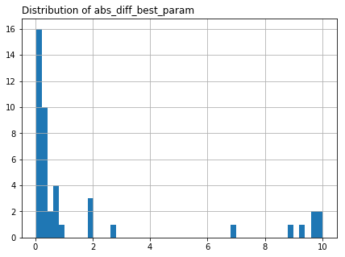

```python
# Distribution of absolute differences in best hyper-parameter:
plt.figure(figsize=(7,5))

diff_param_LR.abs_diff_best_param.hist(bins=50)

plt.title('Distribution of abs_diff_best_param', loc='left')
```

#### Comparing performance metrics

```python
print('\033[1mComparing test ROC-AUC:\033[0m')
print('\n')
print('\033[1mStatistics for absolute difference of ROC-AUC:\033[0m')
print(diff_param_LR.abs_diff_roc_auc.describe())

diff_param_LR.sort_values('abs_diff_roc_auc', ascending=False).head(10)
```

```
Comparing test ROC-AUC:


Statistics for absolute difference of ROC-AUC:
count    44.000000
mean      0.018372
std       0.027125
min       0.000016
25%       0.001934
50%       0.005848
75%       0.022499
max       0.103481
Name: abs_diff_roc_auc, dtype: float64
```

|  | store_id | best_param_roc_auc | best_param_avg_prec | roc_auc_best_roc_auc | roc_auc_best_avg_prec | avg_prec_best_avg_prec | avg_prec_best_roc_auc | abs_diff_best_param | abs_diff_roc_auc | abs_diff_avg_prec |
| --- | --- | --- | --- | --- | --- | --- | --- | --- | --- | --- |
| 83 | 3146 | 10.0000 | 0.10 | 0.823101 | 0.719620 | 0.259247 | 0.092862 | 9.9000 | 0.103481 | 0.166385 |
| 29 | 7845 | 0.5000 | 0.10 | 0.833742 | 0.746426 | 0.239007 | 0.175623 | 0.4000 | 0.087316 | 0.063384 |
| 20 | 10268 | 1.0000 | 10.00 | 0.694892 | 0.610215 | 0.118871 | 0.090646 | 9.0000 | 0.084677 | 0.028225 |
| 6 | 5848 | 0.1000 | 1.00 | 0.934959 | 0.857375 | 0.326670 | 0.251868 | 0.9000 | 0.077584 | 0.074802 |
| 71 | 8446 | 0.0001 | 10.00 | 0.500000 | 0.432122 | 0.001681 | 0.000955 | 9.9999 | 0.067878 | 0.000726 |
| 11 | 4408 | 0.2500 | 0.75 | 0.805990 | 0.759635 | 0.276317 | 0.269647 | 0.5000 | 0.046354 | 0.006670 |
| 4 | 3481 | 0.3000 | 10.00 | 0.789703 | 0.743769 | 0.209854 | 0.089113 | 9.7000 | 0.045934 | 0.120741 |
| 49 | 7790 | 0.1000 | 0.25 | 0.612757 | 0.572966 | 0.400270 | 0.370552 | 0.1500 | 0.039791 | 0.029718 |
| 72 | 8790 | 0.3000 | 1.00 | 0.825226 | 0.791769 | 0.405025 | 0.397106 | 0.7000 | 0.033456 | 0.007920 |
| 97 | 2782 | 0.3000 | 3.00 | 0.863650 | 0.831612 | 0.245908 | 0.189285 | 2.7000 | 0.032038 | 0.056623 |

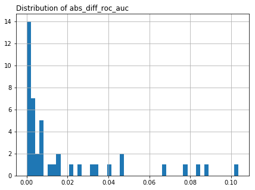

```python
# Distribution of absolute differences in test ROC-AUC:
plt.figure(figsize=(7,5))

diff_param_LR.abs_diff_roc_auc.hist(bins=50)

plt.title('Distribution of abs_diff_roc_auc', loc='left')
```

```python
print('\033[1mStatistics of test ROC-AUC for datasets with the largest absolute difference:\033[0m')
diff_param_LR[diff_param_LR.abs_diff_roc_auc > diff_param_LR.abs_diff_roc_auc.quantile(q=0.75)][['roc_auc_best_roc_auc']].describe().transpose()
```

```
Statistics of test ROC-AUC for datasets with the largest absolute difference:
```

|  | count | mean | std | min | 25% | 50% | 75% | max |
| --- | --- | --- | --- | --- | --- | --- | --- | --- |
| roc_auc_best_roc_auc | 11.0 | 0.778425 | 0.127236 | 0.5 | 0.742298 | 0.823101 | 0.848696 | 0.934959 |

```python
print('\033[1mStatistics of test ROC-AUC for datasets with difference in best hyper-parameter:\033[0m')
grid_search_comp_LR[grid_search_comp_LR.best_param_roc_auc != grid_search_comp_LR.best_param_avg_prec][['roc_auc_best_roc_auc']].describe().transpose()
```

```
Statistics of test ROC-AUC for datasets with difference in best hyper-parameter:
```

|  | count | mean | std | min | 25% | 50% | 75% | max |
| --- | --- | --- | --- | --- | --- | --- | --- | --- |
| roc_auc_best_roc_auc | 44.0 | 0.873927 | 0.125698 | 0.5 | 0.831613 | 0.919596 | 0.962979 | 0.993563 |

```python
print('\033[1mStatistics of test ROC-AUC for datasets with no difference in best hyper-parameter:\033[0m')
grid_search_comp_LR[grid_search_comp_LR.best_param_roc_auc == grid_search_comp_LR.best_param_avg_prec][['roc_auc_best_roc_auc']].describe().transpose()
```

```
Statistics of test ROC-AUC for datasets with no difference in best hyper-parameter:
```

|  | count | mean | std | min | 25% | 50% | 75% | max |
| --- | --- | --- | --- | --- | --- | --- | --- | --- |
| roc_auc_best_roc_auc | 53.0 | 0.909007 | 0.08542 | 0.625 | 0.89837 | 0.930476 | 0.970886 | 1.0 |

```python
print('\033[1mComparing test average precision score:\033[0m')
print('\n')
print('\033[1mStatistics for absolute difference of average precision score:\033[0m')
print(diff_param_LR.abs_diff_avg_prec.describe())

diff_param_LR.sort_values('abs_diff_avg_prec', ascending=False).head(10)
```

```
Comparing test average precision score:


Statistics for absolute difference of average precision score:
count    44.000000
mean      0.028780
std       0.034506
min       0.000287
25%       0.004544
50%       0.018033
75%       0.035037
max       0.166385
Name: abs_diff_avg_prec, dtype: float64
```

|  | store_id | best_param_roc_auc | best_param_avg_prec | roc_auc_best_roc_auc | roc_auc_best_avg_prec | avg_prec_best_avg_prec | avg_prec_best_roc_auc | abs_diff_best_param | abs_diff_roc_auc | abs_diff_avg_prec |
| --- | --- | --- | --- | --- | --- | --- | --- | --- | --- | --- |
| 83 | 3146 | 10.00 | 0.1 | 0.823101 | 0.719620 | 0.259247 | 0.092862 | 9.90 | 0.103481 | 0.166385 |
| 4 | 3481 | 0.30 | 10.0 | 0.789703 | 0.743769 | 0.209854 | 0.089113 | 9.70 | 0.045934 | 0.120741 |
| 81 | 7630 | 0.10 | 0.3 | 0.669048 | 0.661111 | 0.303037 | 0.204032 | 0.20 | 0.007937 | 0.099005 |
| 6 | 5848 | 0.10 | 1.0 | 0.934959 | 0.857375 | 0.326670 | 0.251868 | 0.90 | 0.077584 | 0.074802 |
| 60 | 10650 | 0.30 | 1.0 | 0.885392 | 0.879316 | 0.362141 | 0.295101 | 0.70 | 0.006076 | 0.067039 |
| 29 | 7845 | 0.50 | 0.1 | 0.833742 | 0.746426 | 0.239007 | 0.175623 | 0.40 | 0.087316 | 0.063384 |
| 97 | 2782 | 0.30 | 3.0 | 0.863650 | 0.831612 | 0.245908 | 0.189285 | 2.70 | 0.032038 | 0.056623 |
| 26 | 6047 | 0.25 | 0.1 | 0.948414 | 0.948377 | 0.434277 | 0.383996 | 0.15 | 0.000037 | 0.050281 |
| 21 | 10060 | 0.25 | 1.0 | 0.872246 | 0.870384 | 0.612258 | 0.563001 | 0.75 | 0.001862 | 0.049258 |
| 5 | 4838 | 0.03 | 0.3 | 0.972613 | 0.966992 | 0.638555 | 0.596136 | 0.27 | 0.005620 | 0.042418 |

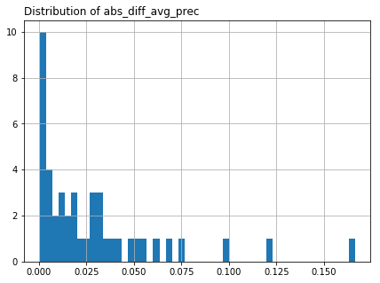

```python
# Distribution of absolute differences in test average precision score:
plt.figure(figsize=(7,5))

diff_param_LR.abs_diff_avg_prec.hist(bins=50)

plt.title('Distribution of abs_diff_avg_prec', loc='left')
```

```python
print('\033[1mStatistics of test average precision score for datasets with the largest absolute difference:\033[0m')
diff_param_LR[diff_param_LR.abs_diff_avg_prec > diff_param_LR.abs_diff_avg_prec.quantile(q=0.75)][['avg_prec_best_avg_prec']].describe().transpose()
```

```
Statistics of test average precision score for datasets with the largest absolute difference:
```

|  | count | mean | std | min | 25% | 50% | 75% | max |
| --- | --- | --- | --- | --- | --- | --- | --- | --- |
| avg_prec_best_avg_prec | 11.0 | 0.391447 | 0.17314 | 0.209854 | 0.252578 | 0.32667 | 0.523268 | 0.674959 |

```python
print('\033[1mStatistics of test average precision score for datasets with difference in best hyper-parameter:\033[0m')
grid_search_comp_LR[grid_search_comp_LR.best_param_roc_auc != grid_search_comp_LR.best_param_avg_prec][['avg_prec_best_avg_prec']].describe().transpose()
```

```
Statistics of test average precision score for datasets with difference in best hyper-parameter:
```

|  | count | mean | std | min | 25% | 50% | 75% | max |
| --- | --- | --- | --- | --- | --- | --- | --- | --- |
| avg_prec_best_avg_prec | 44.0 | 0.459934 | 0.247255 | 0.001681 | 0.27205 | 0.45033 | 0.684618 | 0.913769 |

```python
print('\033[1mStatistics of test average precision score for datasets with no difference in best hyper-parameter:\033[0m')
grid_search_comp_LR[grid_search_comp_LR.best_param_roc_auc == grid_search_comp_LR.best_param_avg_prec][['avg_prec_best_avg_prec']].describe().transpose()
```

```
Statistics of test average precision score for datasets with no difference in best hyper-parameter:
```

|  | count | mean | std | min | 25% | 50% | 75% | max |
| --- | --- | --- | --- | --- | --- | --- | --- | --- |
| avg_prec_best_avg_prec | 53.0 | 0.582064 | 0.27004 | 0.005235 | 0.40405 | 0.608948 | 0.79521 | 1.0 |

### GBM

The outcomes from GBM estimation follows from grid-search to define the regularization parameter $\max\_depth$, the maximum number of splits in the threes composing the ensemble. The grid explored through train-test estimations has 10 different values for $\max\_depth$: $\{1, 2, 3, 4, 5, 6, 7, 8, 9, 10\}$. The estimations were performed using 100 different datasets whose response variable was binary. The remaining most relevant hyper-parameters were defined as follows: $\eta = 1$, $v = 0.1$, and $n\_estimators = 500$.

#### Importing and processing data

```python
# Outcomes from GBM estimations:
with open('../Datasets/tun_subsample.json') as json_file:
    tun_subsample = json.load(json_file)
```

```python
# Dataframe with performance metrics by dataset:
metrics_GBM = pd.DataFrame(data={
    'store_id': [int(s) for s in tun_subsample.keys() if np.isnan(tun_subsample[s]['test_roc_auc']['0.75']) == False],
    'test_roc_auc': [tun_subsample[s]['test_roc_auc']['0.75'] for s in tun_subsample.keys() if np.isnan(tun_subsample[s]['test_roc_auc']['0.75']) == False],
    'test_prec_avg': [tun_subsample[s]['test_prec_avg']['0.75'] for s in tun_subsample.keys() if np.isnan(tun_subsample[s]['test_prec_avg']['0.75']) == False],
    'test_pr_auc': [tun_subsample[s]['test_pr_auc']['0.75'] for s in tun_subsample.keys() if np.isnan(tun_subsample[s]['test_pr_auc']['0.75']) == False],
    'test_deviance_neg': [-tun_subsample[s]['test_deviance']['0.75'] for s in tun_subsample.keys() if np.isnan(tun_subsample[s]['test_deviance']['0.75']) == False],
    'test_brier_score_neg': [-tun_subsample[s]['test_brier_score']['0.75'] for s in tun_subsample.keys() if np.isnan(tun_subsample[s]['test_brier_score']['0.75']) == False]
})

print('\033[1mShape of metrics_GBM:\033[0m ' + str(metrics_GBM.shape) + '.')
metrics_GBM.head()
```

```
Shape of metrics_GBM: (97, 6).
```

|  | store_id | test_roc_auc | test_prec_avg | test_pr_auc | test_deviance_neg | test_brier_score_neg |
| --- | --- | --- | --- | --- | --- | --- |
| 0 | 11729 | 0.801276 | 0.191084 | 0.184379 | -885.512767 | -0.043436 |
| 1 | 10311 | 0.799521 | 0.023465 | 0.019710 | -693.145870 | -0.008808 |
| 2 | 7988 | 0.563636 | 0.091626 | 0.087912 | -372.231960 | -0.096923 |
| 3 | 4736 | 0.921247 | 0.628839 | 0.624813 | -322.896852 | -0.027266 |
| 4 | 3481 | 0.729311 | 0.039222 | 0.032138 | -1517.080351 | -0.008447 |

```python
# Dataframe with best hyper-parameters and associated performance metrics:
stores = []
best_param_roc_auc = []
best_param_avg_prec = []
roc_auc_best_roc_auc = []
roc_auc_best_avg_prec = []
avg_prec_best_avg_prec = []
avg_prec_best_roc_auc = []

# Loop over datasets:
for s in tun_max_depth['500'].keys():
    stores.append(int(s))

    # Hyper-parameters and performance metrics:
    params = list(tun_max_depth['500'][s]['test_roc_auc'].keys())
    test_roc_auc = list(tun_max_depth['500'][s]['test_roc_auc'].values())
    test_prec_avg = list(tun_max_depth['500'][s]['test_prec_avg'].values())

    # Best hyper-parameters:
    best_param_roc_auc.append(float(params[test_roc_auc.index(max(test_roc_auc))]))
    best_param_avg_prec.append(float(params[test_prec_avg.index(max(test_prec_avg))]))

    # Performance metrics for best hyper-parameters:
    roc_auc_best_roc_auc.append(float(test_roc_auc[test_roc_auc.index(max(test_roc_auc))]))
    roc_auc_best_avg_prec.append(float(test_roc_auc[test_prec_avg.index(max(test_prec_avg))]))
    avg_prec_best_avg_prec.append(float(test_prec_avg[test_prec_avg.index(max(test_prec_avg))]))
    avg_prec_best_roc_auc.append(float(test_prec_avg[test_roc_auc.index(max(test_roc_auc))]))

# Dataframe with information of best hyper-parameters and associated performance metrics by dataset:
grid_search_comp_GBM = pd.DataFrame(data={
    'store_id': stores,
    'best_param_roc_auc': best_param_roc_auc,
    'best_param_avg_prec': best_param_avg_prec,
    'roc_auc_best_roc_auc': roc_auc_best_roc_auc,
    'roc_auc_best_avg_prec': roc_auc_best_avg_prec,
    'avg_prec_best_avg_prec': avg_prec_best_avg_prec,
    'avg_prec_best_roc_auc': avg_prec_best_roc_auc
})

print('\033[1mShape of grid_search_comp_GBM:\033[0m ' + str(grid_search_comp_GBM.shape) + '.')
grid_search_comp_GBM.head()
```

```
Shape of grid_search_comp_GBM: (100, 7).
```

|  | store_id | best_param_roc_auc | best_param_avg_prec | roc_auc_best_roc_auc | roc_auc_best_avg_prec | avg_prec_best_avg_prec | avg_prec_best_roc_auc |
| --- | --- | --- | --- | --- | --- | --- | --- |
| 0 | 11729 | 1.0 | 1.0 | 0.799801 | 0.799801 | 0.202104 | 0.202104 |
| 1 | 10311 | 4.0 | 6.0 | 0.887601 | 0.766948 | 0.052554 | 0.038844 |
| 2 | 7988 | 10.0 | 10.0 | 0.583999 | 0.583999 | 0.123488 | 0.123488 |
| 3 | 4736 | 6.0 | 2.0 | 0.908057 | 0.900055 | 0.562723 | 0.456224 |
| 4 | 3481 | 2.0 | 2.0 | 0.781987 | 0.781987 | 0.110081 | 0.110081 |

```python
# Dataframe with datasets for which best hyper-parameters differ between ROC-AUC and average precision score:
diff_param_GBM = grid_search_comp_GBM[grid_search_comp_GBM.best_param_roc_auc != grid_search_comp_GBM.best_param_avg_prec]
diff_param_GBM['abs_diff_best_param'] = np.abs(diff_param_GBM.best_param_roc_auc - diff_param_GBM.best_param_avg_prec)
diff_param_GBM['abs_diff_roc_auc'] = np.abs(diff_param_GBM.roc_auc_best_roc_auc - diff_param_GBM.roc_auc_best_avg_prec)
diff_param_GBM['abs_diff_avg_prec'] = np.abs(diff_param_GBM.avg_prec_best_avg_prec - diff_param_GBM.avg_prec_best_roc_auc)

print('\033[1mShape of diff_param_GBM:\033[0m ' + str(diff_param_GBM.shape) + '.')
diff_param_GBM.sort_values('abs_diff_best_param', ascending=False).head(10)
```

```
Shape of diff_param_GBM: (47, 10).
```

|  | store_id | best_param_roc_auc | best_param_avg_prec | roc_auc_best_roc_auc | roc_auc_best_avg_prec | avg_prec_best_avg_prec | avg_prec_best_roc_auc | abs_diff_best_param | abs_diff_roc_auc | abs_diff_avg_prec |
| --- | --- | --- | --- | --- | --- | --- | --- | --- | --- | --- |
| 85 | 7755 | 1.0 | 10.0 | 0.863327 | 0.841733 | 0.532300 | 0.502225 | 9.0 | 0.021594 | 0.030074 |
| 35 | 7849 | 9.0 | 1.0 | 0.893840 | 0.887102 | 0.400260 | 0.341014 | 8.0 | 0.006738 | 0.059246 |
| 93 | 5394 | 9.0 | 1.0 | 0.872055 | 0.868861 | 0.627453 | 0.545424 | 8.0 | 0.003193 | 0.082029 |
| 27 | 8832 | 1.0 | 9.0 | 0.927887 | 0.910926 | 0.378259 | 0.317216 | 8.0 | 0.016961 | 0.061043 |
| 70 | 11723 | 8.0 | 1.0 | 0.923893 | 0.909745 | 0.447972 | 0.361462 | 7.0 | 0.014148 | 0.086511 |
| 99 | 6966 | 1.0 | 6.0 | 0.824191 | 0.802755 | 0.478225 | 0.475037 | 5.0 | 0.021435 | 0.003188 |
| 87 | 4030 | 6.0 | 1.0 | 0.922828 | 0.904266 | 0.380409 | 0.223817 | 5.0 | 0.018561 | 0.156592 |
| 53 | 2212 | 6.0 | 1.0 | 0.917246 | 0.859159 | 0.458835 | 0.341768 | 5.0 | 0.058087 | 0.117067 |
| 83 | 3146 | 10.0 | 5.0 | 0.880854 | 0.767880 | 0.191062 | 0.146340 | 5.0 | 0.112975 | 0.044723 |
| 13 | 6044 | 4.0 | 9.0 | 0.966470 | 0.960556 | 0.542730 | 0.524035 | 5.0 | 0.005914 | 0.018694 |

#### Correlation between performance metrics

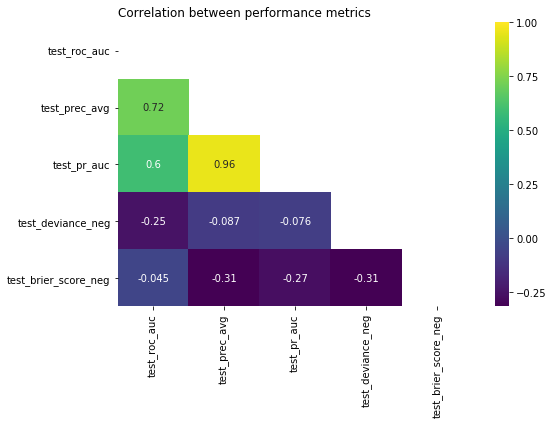

```python
# Generate a mask for the upper triangle:
mask = np.triu(np.ones_like(metrics_GBM.drop('store_id', axis=1).corr(), dtype=np.bool))

plt.figure(figsize=(8,6))
sns.heatmap(metrics_GBM.drop('store_id', axis=1).corr(), mask = mask, annot = True, cmap = 'viridis')
plt.title('Correlation between performance metrics', loc='left')
plt.tight_layout()
```

#### Comparing best hyper-parameters

```python
print('\033[1mNumber of datasets with no difference in best hyper-parameter:\033[0m ' +
      str(len(grid_search_comp_GBM.dropna()) - len(diff_param_GBM)) + ' (' +
      str(round(((len(grid_search_comp_GBM.dropna()) - len(diff_param_GBM))/len(grid_search_comp_GBM.dropna()))*100,2)) +
      '%).')
```

```
Number of datasets with no difference in best hyper-parameter: 50 (51.55%).
```

```python
print('\033[1mComparing best hyper-parameter:\033[0m')
print('\n')
print('\033[1mStatistics for absolute difference of best hyper-parameter:\033[0m')
print(diff_param_GBM.abs_diff_best_param.describe())

diff_param_GBM.sort_values('abs_diff_best_param', ascending=False).head(10)
```

```
Comparing best hyper-parameter:


Statistics for absolute difference of best hyper-parameter:
count    47.000000
mean      3.148936
std       2.176742
min       1.000000
25%       1.000000
50%       3.000000
75%       4.000000
max       9.000000
Name: abs_diff_best_param, dtype: float64
```

|  | store_id | best_param_roc_auc | best_param_avg_prec | roc_auc_best_roc_auc | roc_auc_best_avg_prec | avg_prec_best_avg_prec | avg_prec_best_roc_auc | abs_diff_best_param | abs_diff_roc_auc | abs_diff_avg_prec |
| --- | --- | --- | --- | --- | --- | --- | --- | --- | --- | --- |
| 85 | 7755 | 1.0 | 10.0 | 0.863327 | 0.841733 | 0.532300 | 0.502225 | 9.0 | 0.021594 | 0.030074 |
| 35 | 7849 | 9.0 | 1.0 | 0.893840 | 0.887102 | 0.400260 | 0.341014 | 8.0 | 0.006738 | 0.059246 |
| 93 | 5394 | 9.0 | 1.0 | 0.872055 | 0.868861 | 0.627453 | 0.545424 | 8.0 | 0.003193 | 0.082029 |
| 27 | 8832 | 1.0 | 9.0 | 0.927887 | 0.910926 | 0.378259 | 0.317216 | 8.0 | 0.016961 | 0.061043 |
| 70 | 11723 | 8.0 | 1.0 | 0.923893 | 0.909745 | 0.447972 | 0.361462 | 7.0 | 0.014148 | 0.086511 |
| 99 | 6966 | 1.0 | 6.0 | 0.824191 | 0.802755 | 0.478225 | 0.475037 | 5.0 | 0.021435 | 0.003188 |
| 87 | 4030 | 6.0 | 1.0 | 0.922828 | 0.904266 | 0.380409 | 0.223817 | 5.0 | 0.018561 | 0.156592 |
| 53 | 2212 | 6.0 | 1.0 | 0.917246 | 0.859159 | 0.458835 | 0.341768 | 5.0 | 0.058087 | 0.117067 |
| 83 | 3146 | 10.0 | 5.0 | 0.880854 | 0.767880 | 0.191062 | 0.146340 | 5.0 | 0.112975 | 0.044723 |
| 13 | 6044 | 4.0 | 9.0 | 0.966470 | 0.960556 | 0.542730 | 0.524035 | 5.0 | 0.005914 | 0.018694 |

```python
print('\033[1mStatistics of best hyper-parameter for datasets with difference in best hyper-parameter:\033[0m')
print('\033[1mBest hyper-parameter according with test ROC-AUC:\033[0m')
grid_search_comp_GBM[grid_search_comp_GBM.best_param_roc_auc != grid_search_comp_GBM.best_param_avg_prec][['best_param_roc_auc']].describe().transpose()
```

```
Statistics of best hyper-parameter for datasets with difference in best hyper-parameter:
Best hyper-parameter according with test ROC-AUC:
```

|  | count | mean | std | min | 25% | 50% | 75% | max |
| --- | --- | --- | --- | --- | --- | --- | --- | --- |
| best_param_roc_auc | 47.0 | 3.574468 | 2.551595 | 1.0 | 1.5 | 3.0 | 5.0 | 10.0 |

```python
print('\033[1mStatistics of best hyper-parameter for datasets with difference in best hyper-parameter:\033[0m')
print('\033[1mBest hyper-parameter according with test average precision score:\033[0m')
grid_search_comp_GBM[grid_search_comp_GBM.best_param_roc_auc != grid_search_comp_GBM.best_param_avg_prec][['best_param_avg_prec']].describe().transpose()
```

```
Statistics of best hyper-parameter for datasets with difference in best hyper-parameter:
Best hyper-parameter according with test average precision score:
```

|  | count | mean | std | min | 25% | 50% | 75% | max |
| --- | --- | --- | --- | --- | --- | --- | --- | --- |
| best_param_avg_prec | 47.0 | 2.851064 | 2.466988 | 1.0 | 1.0 | 2.0 | 4.0 | 10.0 |

```python
print('\033[1mStatistics of best hyper-parameter for datasets with no difference in best hyper-parameter:\033[0m')
grid_search_comp_GBM[grid_search_comp_GBM.best_param_roc_auc == grid_search_comp_GBM.best_param_avg_prec][['best_param_roc_auc']].describe().transpose()
```

```
Statistics of best hyper-parameter for datasets with no difference in best hyper-parameter:
```

|  | count | mean | std | min | 25% | 50% | 75% | max |
| --- | --- | --- | --- | --- | --- | --- | --- | --- |
| best_param_roc_auc | 53.0 | 1.792453 | 1.70247 | 1.0 | 1.0 | 1.0 | 2.0 | 10.0 |

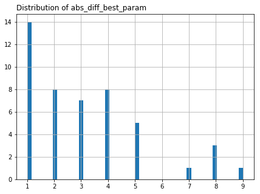

```python
# Distribution of absolute differences in best hyper-parameter:
plt.figure(figsize=(7,5))

diff_param_GBM.abs_diff_best_param.hist(bins=50)

plt.title('Distribution of abs_diff_best_param', loc='left')
```

#### Comparing performance metrics

```python
print('\033[1mComparing test ROC-AUC:\033[0m')
print('\n')
print('\033[1mStatistics for absolute difference of ROC-AUC:\033[0m')
print(diff_param_GBM.abs_diff_roc_auc.describe())

diff_param_GBM.sort_values('abs_diff_roc_auc', ascending=False).head(10)
```

```
Comparing test ROC-AUC:


Statistics for absolute difference of ROC-AUC:
count    47.000000
mean      0.026472
std       0.040345
min       0.000277
25%       0.003975
50%       0.010529
75%       0.023492
max       0.177540
Name: abs_diff_roc_auc, dtype: float64
```

|  | store_id | best_param_roc_auc | best_param_avg_prec | roc_auc_best_roc_auc | roc_auc_best_avg_prec | avg_prec_best_avg_prec | avg_prec_best_roc_auc | abs_diff_best_param | abs_diff_roc_auc | abs_diff_avg_prec |
| --- | --- | --- | --- | --- | --- | --- | --- | --- | --- | --- |
| 65 | 7185 | 2.0 | 1.0 | 0.720124 | 0.542584 | 0.170330 | 0.045479 | 1.0 | 0.177540 | 0.124851 |
| 54 | 9761 | 4.0 | 8.0 | 0.738872 | 0.610005 | 0.039437 | 0.034038 | 4.0 | 0.128867 | 0.005399 |
| 1 | 10311 | 4.0 | 6.0 | 0.887601 | 0.766948 | 0.052554 | 0.038844 | 2.0 | 0.120653 | 0.013710 |
| 29 | 7845 | 1.0 | 3.0 | 0.848958 | 0.729677 | 0.202312 | 0.174654 | 2.0 | 0.119281 | 0.027658 |
| 83 | 3146 | 10.0 | 5.0 | 0.880854 | 0.767880 | 0.191062 | 0.146340 | 5.0 | 0.112975 | 0.044723 |
| 77 | 8421 | 3.0 | 1.0 | 0.500000 | 0.425634 | 0.004197 | 0.003487 | 2.0 | 0.074366 | 0.000709 |
| 53 | 2212 | 6.0 | 1.0 | 0.917246 | 0.859159 | 0.458835 | 0.341768 | 5.0 | 0.058087 | 0.117067 |
| 25 | 8783 | 1.0 | 5.0 | 0.894203 | 0.850336 | 0.499345 | 0.499056 | 4.0 | 0.043868 | 0.000288 |
| 68 | 3962 | 5.0 | 1.0 | 0.967088 | 0.933852 | 0.559490 | 0.460256 | 4.0 | 0.033236 | 0.099234 |
| 80 | 6714 | 1.0 | 3.0 | 0.678619 | 0.647703 | 0.279895 | 0.188249 | 2.0 | 0.030916 | 0.091646 |

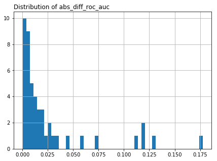

```python
# Distribution of absolute differences in test ROC-AUC:
plt.figure(figsize=(7,5))

diff_param_GBM.abs_diff_roc_auc.hist(bins=50)

plt.title('Distribution of abs_diff_roc_auc', loc='left')
```

```python
print('\033[1mStatistics of test ROC-AUC for datasets with the largest absolute difference:\033[0m')
diff_param_GBM[diff_param_GBM.abs_diff_roc_auc > diff_param_GBM.abs_diff_roc_auc.quantile(q=0.75)][['roc_auc_best_roc_auc']].describe().transpose()
```

```
Statistics of test ROC-AUC for datasets with the largest absolute difference:
```

|  | count | mean | std | min | 25% | 50% | 75% | max |
| --- | --- | --- | --- | --- | --- | --- | --- | --- |
| roc_auc_best_roc_auc | 12.0 | 0.781848 | 0.14532 | 0.5 | 0.709748 | 0.814844 | 0.889251 | 0.967088 |

```python
print('\033[1mStatistics of test ROC-AUC for datasets with difference in best hyper-parameter:\033[0m')
grid_search_comp_GBM[grid_search_comp_GBM.best_param_roc_auc != grid_search_comp_GBM.best_param_avg_prec][['roc_auc_best_roc_auc']].describe().transpose()
```

```
Statistics of test ROC-AUC for datasets with difference in best hyper-parameter:
```

|  | count | mean | std | min | 25% | 50% | 75% | max |
| --- | --- | --- | --- | --- | --- | --- | --- | --- |
| roc_auc_best_roc_auc | 47.0 | 0.854242 | 0.142226 | 0.482222 | 0.831678 | 0.900665 | 0.956614 | 0.987558 |

```python
print('\033[1mStatistics of test ROC-AUC for datasets with no difference in best hyper-parameter:\033[0m')
grid_search_comp_GBM[grid_search_comp_GBM.best_param_roc_auc == grid_search_comp_GBM.best_param_avg_prec][['roc_auc_best_roc_auc']].describe().transpose()
```

```
Statistics of test ROC-AUC for datasets with no difference in best hyper-parameter:
```

|  | count | mean | std | min | 25% | 50% | 75% | max |
| --- | --- | --- | --- | --- | --- | --- | --- | --- |
| roc_auc_best_roc_auc | 50.0 | 0.863824 | 0.122886 | 0.5 | 0.804156 | 0.903295 | 0.947715 | 0.989621 |

```python
print('\033[1mComparing test average precision score:\033[0m')
print('\n')
print('\033[1mStatistics for absolute difference of average precision score:\033[0m')
print(diff_param_GBM.abs_diff_avg_prec.describe())

diff_param_GBM.sort_values('abs_diff_avg_prec', ascending=False).head(10)
```

```
Comparing test average precision score:


Statistics for absolute difference of average precision score:
count    47.000000
mean      0.048202
std       0.056130
min       0.000000
25%       0.005111
50%       0.025520
75%       0.084270
max       0.199456
Name: abs_diff_avg_prec, dtype: float64
```

|  | store_id | best_param_roc_auc | best_param_avg_prec | roc_auc_best_roc_auc | roc_auc_best_avg_prec | avg_prec_best_avg_prec | avg_prec_best_roc_auc | abs_diff_best_param | abs_diff_roc_auc | abs_diff_avg_prec |
| --- | --- | --- | --- | --- | --- | --- | --- | --- | --- | --- |
| 5 | 4838 | 5.0 | 1.0 | 0.975498 | 0.972562 | 0.564125 | 0.364669 | 4.0 | 0.002936 | 0.199456 |
| 22 | 6256 | 2.0 | 1.0 | 0.905136 | 0.901163 | 0.329840 | 0.140069 | 1.0 | 0.003973 | 0.189772 |
| 97 | 2782 | 5.0 | 2.0 | 0.700844 | 0.691613 | 0.285545 | 0.120405 | 3.0 | 0.009231 | 0.165140 |
| 87 | 4030 | 6.0 | 1.0 | 0.922828 | 0.904266 | 0.380409 | 0.223817 | 5.0 | 0.018561 | 0.156592 |
| 11 | 4408 | 3.0 | 4.0 | 0.780729 | 0.755339 | 0.288852 | 0.154125 | 1.0 | 0.025391 | 0.134727 |
| 65 | 7185 | 2.0 | 1.0 | 0.720124 | 0.542584 | 0.170330 | 0.045479 | 1.0 | 0.177540 | 0.124851 |
| 92 | 12658 | 8.0 | 6.0 | 0.827865 | 0.824479 | 0.520173 | 0.400740 | 2.0 | 0.003385 | 0.119433 |
| 53 | 2212 | 6.0 | 1.0 | 0.917246 | 0.859159 | 0.458835 | 0.341768 | 5.0 | 0.058087 | 0.117067 |
| 3 | 4736 | 6.0 | 2.0 | 0.908057 | 0.900055 | 0.562723 | 0.456224 | 4.0 | 0.008002 | 0.106499 |
| 68 | 3962 | 5.0 | 1.0 | 0.967088 | 0.933852 | 0.559490 | 0.460256 | 4.0 | 0.033236 | 0.099234 |

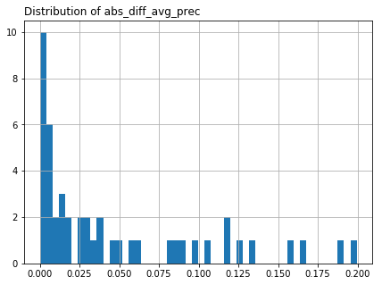

```python
# Distribution of absolute differences in test average precision score:
plt.figure(figsize=(7,5))

diff_param_GBM.abs_diff_avg_prec.hist(bins=50)

plt.title('Distribution of abs_diff_avg_prec', loc='left')
```

```python
print('\033[1mStatistics of test average precision score for datasets with the largest absolute difference:\033[0m')
diff_param_GBM[diff_param_GBM.abs_diff_avg_prec > diff_param_GBM.abs_diff_avg_prec.quantile(q=0.75)][['avg_prec_best_avg_prec']].describe().transpose()
```

```
Statistics of test average precision score for datasets with the largest absolute difference:
```

|  | count | mean | std | min | 25% | 50% | 75% | max |
| --- | --- | --- | --- | --- | --- | --- | --- | --- |
| avg_prec_best_avg_prec | 12.0 | 0.404016 | 0.133756 | 0.17033 | 0.288025 | 0.414191 | 0.530002 | 0.564125 |

```python
print('\033[1mStatistics of test average precision score for datasets with difference in best hyper-parameter:\033[0m')
grid_search_comp_GBM[grid_search_comp_GBM.best_param_roc_auc != grid_search_comp_GBM.best_param_avg_prec][['avg_prec_best_avg_prec']].describe().transpose()
```

```
Statistics of test average precision score for datasets with difference in best hyper-parameter:
```

|  | count | mean | std | min | 25% | 50% | 75% | max |
| --- | --- | --- | --- | --- | --- | --- | --- | --- |
| avg_prec_best_avg_prec | 47.0 | 0.433623 | 0.259853 | 0.000957 | 0.238833 | 0.461855 | 0.563424 | 0.951548 |

```python
print('\033[1mStatistics of test average precision score for datasets with no difference in best hyper-parameter:\033[0m')
grid_search_comp_GBM[grid_search_comp_GBM.best_param_roc_auc == grid_search_comp_GBM.best_param_avg_prec][['avg_prec_best_avg_prec']].describe().transpose()
```

```
Statistics of test average precision score for datasets with no difference in best hyper-parameter:
```

|  | count | mean | std | min | 25% | 50% | 75% | max |
| --- | --- | --- | --- | --- | --- | --- | --- | --- |
| avg_prec_best_avg_prec | 50.0 | 0.464446 | 0.271804 | 0.001986 | 0.234535 | 0.448691 | 0.702354 | 0.963264 |